# Flowering, seed production and germination of Arabis alpina

```r
# Show the within- and among-plot labels once for both coefficient panels.
coefficient_y_scale <- function(labels) {
  ggplot2::scale_y_continuous(
    breaks = c(1, 2), labels = labels,
    limits = c(0.5, 3.1), expand = ggplot2::expansion(mult = 0)
  )
}
p_h3_coefficient <- reletter_panel(p_h3_coefficient, "a") +
  coefficient_y_scale(c("Among plots", "Within plot"))
p_h6_coefficient <- reletter_panel(p_h6_coefficient, "b") +
  coefficient_y_scale(NULL) +
  # Use plain text for both titles so their baselines align.
  ggplot2::labs(x = "MISM coefficient (log link) [mg seed\u207b\u00b9]\u207b\u00b9") +
  ggplot2::theme(axis.ticks.y = ggplot2::element_blank())
coefficient_figure <- cowplot::plot_grid(
  plotlist = make_attached_strip_panels(
    lapply(list(p_h3_coefficient, p_h6_coefficient), function(plot) {
      axes <- c("axis.text.x", "axis.text.y", "axis.title.x", "axis.title.y")
      axis_sizes <- lapply(axes, function(axis) {
        size <- ggplot2::calc_element(axis, plot$theme)$size
        ggplot2::element_text(size = size + 2)
      })
      for (i in seq_along(plot$layers)) {
        if (inherits(plot$layers[[i]]$geom, "GeomPoint")) {
          plot$layers[[i]]$aes_params$size <-
            plot$layers[[i]]$aes_params$size + 4 / ggplot2::.pt
        }
        if (inherits(plot$layers[[i]]$geom, "GeomErrorbar")) {
          plot$layers[[i]]$aes_params$linewidth <-
            plot$layers[[i]]$aes_params$linewidth + 3 / ggplot2::.pt
        }
        if (inherits(plot$layers[[i]]$geom, "GeomText")) {
          plot$layers[[i]]$aes_params$size <-
            plot$layers[[i]]$aes_params$size + 1 / ggplot2::.pt
        }
      }
      plot + do.call(ggplot2::theme, setNames(axis_sizes, axes)) +
        ggplot2::theme(
        axis.title.x = ggplot2::element_text(margin = ggplot2::margin(t = 12)),
        plot.margin = ggplot2::margin(5.5, 5.5, 10, 10)
      )
    }),
    strip_padding = 12
  ),
  ncol = 2, align = "h", axis = "tb"
)


# Increase all rendered text by 4 pt, including annotations and tick labels.
increase_figure_text_size <- function(grob, points = 4) {
  if (inherits(grob, "text")) {
    size <- if (is.null(grob$gp$fontsize)) 12 else grob$gp$fontsize
    grob$gp$fontsize <- size + points
  }
  if (length(grob$grobs)) {
    grob$grobs <- lapply(grob$grobs, increase_figure_text_size, points = points)
  }
  for (i in seq_along(grob$children)) {
    grob$children[[i]] <- increase_figure_text_size(grob$children[[i]], points)
  }
  grob
}
combined_figure_grob <- increase_figure_text_size(
  ggplot2::ggplotGrob(combined_figure_flowering_seed_allocation)
)

# Keep the export dimensions fixed and reserve the outer margins.
combined_figure_grob <- gtable::gtable_add_cols(
  combined_figure_grob, grid::unit(left_margin_mm, "mm"), pos = 0
)
combined_figure_grob <- gtable::gtable_add_cols(
  combined_figure_grob, grid::unit(right_margin_mm, "mm"), pos = -1
)

ggplot2::ggsave(
  filename = file.path(
    figure_dir_msa,
    "Figure_H1_H6_flowering_seed_allocation.png"
  ),
  plot = combined_figure_grob,
  width = figure_width_mm, height = 294.84, units = "mm", dpi = 600, bg = "white"
)

ggplot2::ggsave(
  filename = file.path(figure_dir_msa, "Figure_5_within_among_plot_associations.png"),
  plot = gtable::gtable_add_cols(
    increase_figure_text_size(ggplot2::ggplotGrob(coefficient_figure), points = 6),
    grid::unit(14, "mm"), pos = 0
  ),
  width = 427, height = 163.8, units = "mm", dpi = 600, bg = "white"
)
writeLines("Figure 5. Within- and among-plot associations in Arabis alpina. (a) Change in final flowering date (days) per one-day delay in flowering onset. (b) Change in expected total seed number per plant on the log-link scale per 1 mg increase in mean individual seed mass (MISM, mg per seed). Within-plot coefficients describe associations with deviations from plot means, and among-plot coefficients describe associations with plot means. Points show estimated coefficients (\u03b2), and horizontal bars show 95% Wald confidence intervals. Vertical dashed lines mark zero. In (a), a coefficient of one corresponds to unchanged flowering duration, and coefficients below one correspond to shorter duration with later onset. Significance symbols refer to tests against zero (ns, P \u2265 0.05; ***, P < 0.001).", file.path(figure_dir_msa, "Figure_5_within_among_plot_associations_caption.txt"), useBytes = TRUE)

# Definitions above are reused in this section.
render_gt_tables(table_dir_msa, "Maternal seed allocation (H4-H6)")

# Final publication captions and numbered figures override generic table notes.
publication_figure_exports()
publication_render_tables()

# 18. Focal coefficients for environmental sensitivity comparisons ------------

# Manuscript supporting Table S2 separates coefficient sensitivity from AICc
# support. Invalid adjusted H5 intervals remain missing, rather than inferred.
export_environmental_focal_coefficients <- function() {
  flowering_path <- file.path("outputs", "flowering_phenology", "models")
  allocation_path <- file.path("outputs", "maternal_seed_allocation", "models")
  flowering <- readRDS(file.path(flowering_path, "Models_H1_H3_ML.rds"))
  completion <- readRDS(file.path(flowering_path, "final_flowering_date_onset_models.rds"))
  allocation <- readRDS(file.path(allocation_path, "Models_H4_H6.rds"))
  plots <- utils::read.csv(file.path("outputs", "flowering_phenology", "tables", "Table_plot_environment.csv"))
  elevation_sd <- sd(plots$Elevation)
  results <- list()
  for (hypothesis in c("H1", "H2", "H3", "H4", "H5")) {
    candidates <- if (hypothesis == "H3") completion else if (hypothesis %in% names(flowering)) {
      flowering[[hypothesis]]
    } else allocation[[hypothesis]]
    for (candidate in names(candidates)) {
      model <- candidates[[candidate]]
      count_model <- inherits(model, "glmmTMB")
      coefficients <- if (count_model) summary(model)$coefficients$cond else coef(summary(model))
      term <- if (hypothesis == "H3") "Onset_centered" else "Elevation_z"
      multiplier <- if (hypothesis == "H3") 1 else 100 / elevation_sd
      estimate <- coefficients[term, "Estimate"] * multiplier
      se <- coefficients[term, "Std. Error"] * multiplier
      finite_se <- all(is.finite(coefficients[, "Std. Error"]))
      messages <- if (count_model) model$fit$message else model@optinfo$conv$lme4$messages
      converged <- if (count_model) isTRUE(model$fit$convergence == 0) else
        !length(setdiff(messages, "boundary (singular) fit: see help('isSingular')"))
      hessian <- if (count_model) isTRUE(model$sdr$pdHess) else NA
      eligible <- converged && finite_se && (!count_model || hessian)
      boundary <- if (count_model) {
        any(unlist(lapply(glmmTMB::VarCorr(model)$cond, diag)) < 1e-8)
      } else lme4::isSingular(model)
      results[[length(results) + 1L]] <- data.frame(
        Hypothesis = hypothesis, Model = candidate,
        Response = c(H1 = "Flowering onset", H2 = "Flowering duration", H3 = "Final flowering date",
          H4 = "ln(MISM)", H5 = "Seed number")[[hypothesis]],
        Term = term, Predictor_increment = if (hypothesis == "H3") "1 onset day" else "100 m elevation",
        Estimate = estimate, SE = se,
        CI_low = if (eligible) estimate - qnorm(.975) * se else NA_real_,
        CI_high = if (eligible) estimate + qnorm(.975) * se else NA_real_,
        P_zero = if (eligible) 2 * pnorm(-abs(estimate / se)) else NA_real_,
        P_duration = if (eligible && hypothesis == "H3") 2 * pnorm(-abs((estimate - 1) / se)) else NA_real_,
        N = nobs(model), Converged = converged, Positive_definite_Hessian = hessian,
        Finite_fixed_effect_SE = finite_se, Boundary = boundary, Eligible = eligible,
        stringsAsFactors = FALSE)
    }
  }
  result <- do.call(rbind, results)
  # Keep full precision in memory and export only the formatted Table S2.
  publication <- result
  model_labels <- c(
    elevation = "Elevation",
    elevation_climate = "Elevation + climate",
    elevation_soil = "Elevation + soil",
    elevation_climate_soil = "Elevation + climate + soil",
    onset = "Onset",
    onset_elevation = "Onset + elevation",
    onset_elevation_climate = "Onset + elevation + climate",
    onset_elevation_soil = "Onset + elevation + soil",
    onset_elevation_climate_soil = "Onset + elevation + climate + soil"
  )
  publication$Model <- unname(model_labels[result$Model])
  format_number <- function(x) ifelse(is.finite(x), sprintf("%.3f", x), "NA")
  format_p <- function(x) {
    ifelse(!is.finite(x), "NA",
      ifelse(x < 0.001, "<0.001",
        ifelse(x < 0.01, "<0.01",
          ifelse(x < 0.05, "<0.05", sprintf("%.3f", x)))))
  }
  for (column in c("Estimate", "SE", "CI_low", "CI_high")) {
    publication[[column]] <- format_number(result[[column]])
  }
  for (column in c("P_zero", "P_duration")) {
    publication[[column]] <- format_p(result[[column]])
  }
  utils::write.csv(
    publication,
    file.path("outputs", "maternal_seed_allocation", "tables", "Table S2.csv"),
    row.names = FALSE,
    fileEncoding = "UTF-8"
  )
  writeLines("Table S2. Environmental sensitivity models, focal coefficients and numerical diagnostics. Each comparison uses the same 581 maternal plants. H denotes the hypothesis. H1, H2 and H4 coefficients describe elevation associations per 100 m with flowering onset, flowering duration and ln(MISM), respectively. H5 coefficients describe seed-number associations on the log-link scale per 100 m. H3 coefficients describe changes in final flowering date per one-day delay in onset. Climate denotes temperature and precipitation entered jointly, and soil denotes soil PC1. \u03b2 is the focal coefficient, SE its standard error, and CI- and CI+ its lower and upper 95% Wald confidence limits. P0 tests a coefficient of zero. P1 tests an H3 coefficient of one, corresponding to unchanged duration with later onset. Conv., Hess., and SE fin indicate optimiser convergence, a positive-definite Hessian and finite fixed-effect standard errors, respectively. Bound. indicates whether at least one random-intercept variance was near zero. Eligible indicates whether the fit met the numerical criteria for coefficient-level inference. Boundary estimates alone did not exclude a fit. Adjusted H5 estimates are descriptive only because their non-finite standard errors precluded confidence intervals and P values. Dashes indicate unavailable or inapplicable entries. Values are rounded. Table S1 reports model rankings.", file.path("outputs", "maternal_seed_allocation", "tables", "Table S2_caption.txt"), useBytes = TRUE)
  result
}
environmental_focal_coefficients <- export_environmental_focal_coefficients()
```

## 4.2 Figures and tables

### 4.2.1 Figure 3. Environmental variation across 27 source plots

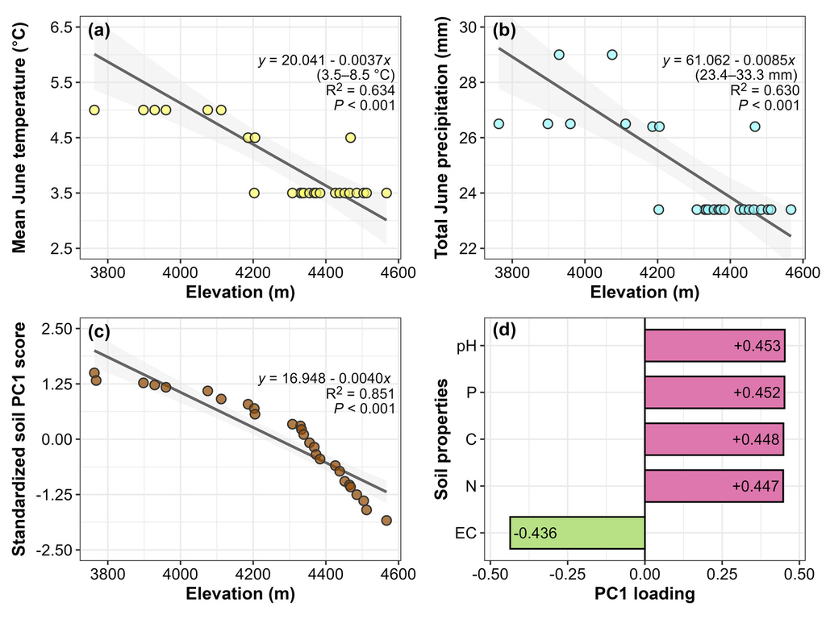

Environmental variation across 27 source plots

Environmental variation across 27 source plots. (a) June 2021 mean temperature, (b) June 2021 total precipitation and (c) standardised soil PC1 by elevation, and (d) soil PC1 loadings. In (a-c), points are plots, lineas are linear fits and shading indicates 95% confidence intervals. In (d), C, N, P and EC denote organic carbon, total nitrogen, extractable phosphorus and electrical conductivity. In the fitted equations, x is elevation in metres.

### 4.2.2 Figure 4. Elevational and trait associations

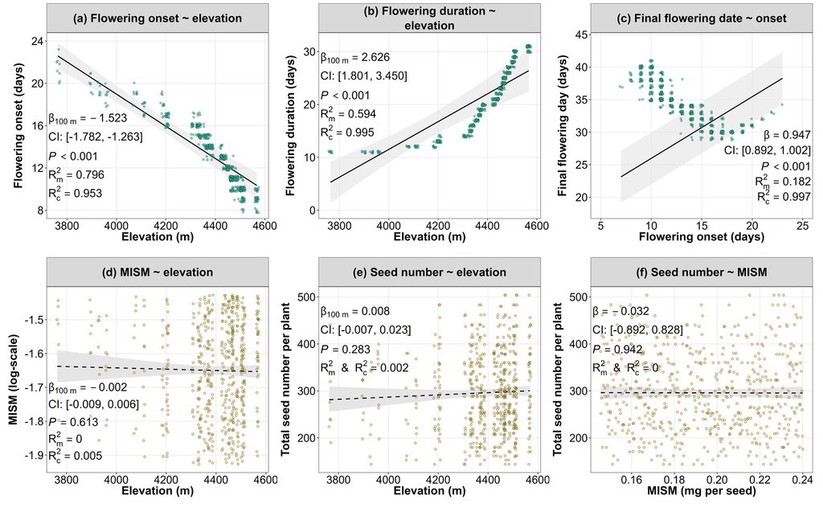

Elevational and trait associations

Elevational and trait associations in Arabis alpina. (a) Flowering onset and (b) flowering duration in relation to elevation. (c) Final flowering date in relation to flowering onset. (d) Mean individual seed mass (MISM, mg per seed) and (e) total seed number per plant in relation to elevation. (f) Total seed number per plant in relation to MISM. Points represent individual plants, lines show model predictions and shaded bands indicate 95% confidence intervals. Solid and dashed lines indicate P < 0.05 and P ≥ 0.05, respectively, for tests of a slope of zero. Slopes (β) are expressed per 100 m increase in elevation (a, b, d, e), per day of later flowering onset (c) or per mg increase in MISM (f). MISM is natural-log-transformed in (d), and seed-number slopes in (e, f) are on the log-link scale. Flowering dates are expressed as days from 1 June 2021 (day 1). In (c), predictions are based on fixed effects with random intercepts set to zero. The reported P value tests a slope of zero. A slope of one corresponds to constant flowering duration. R2m and R2c denote marginal and conditional R2, respectively.

### 4.2.3 Figure 5. Within- and among-plot associations

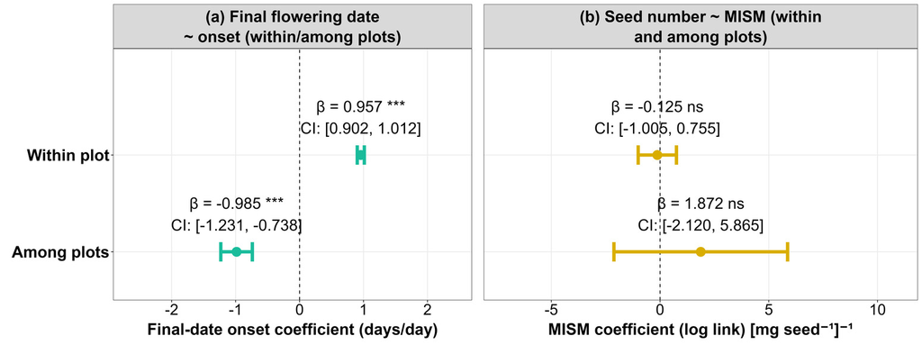

Within- and among-plot associations

Within- and among-plot associations in Arabis alpina. (a) Change in final flowering date (days) per one-day delay in flowering onset. (b) Change in expected total seed number per plant on the log-link scale per 1 mg increase in mean individual seed mass (MISM, mg per seed). Within-plot coefficients describe associations with deviations from plot means, and among-plot coefficients describe associations with plot means. Points show estimated coefficients (β), and horizontal bars show 95% Wald confidence intervals. Vertical dashed lines mark zero. In (a), a coefficient of one corresponds to unchanged flowering duration, and coefficients below one correspond to shorter duration with later onset. Significance symbols refer to tests against zero (ns, P ≥ 0.05; ***, P < 0.001).

### 4.2.4 Table 1. Mixed-effects estimates for H1–H6

Mixed-effects estimates for H1-H6 at plant, within-plot and among-plot scales (581 maternal plants). H denotes the hypothesis, β the coefficient, SE its standard error, and CI- and CI+ the lower and upper 95% Wald confidence limits. Coefficients are expressed per 100-m elevation increase for H1, H2, H4 and H5, one-day delay in flowering onset for H3, and 1-mg increase in mean individual seed mass (MISM) for H6. MISM is measured in mg per seed. H4 uses natural-log-transformed MISM, and H5-H6 coefficients are on the log-link scale. Onset and MISM predictors in the primary association models were mean-centred. Deviation terms represent individual values minus their plot means, while mean terms represent plot means. Within-plot and among-plot coefficients were estimated jointly, and their repeated R2 values describe the same model. R2m and R2c denote marginal and conditional R2. ΔElev (%) denotes percentage change per 100-m elevation increase, calculated as . Δmass (%) denotes percentage change in seed number per 1-mg decrease in MISM, calculated as . All H3 coefficients and confidence limits describe final flowering date. Subtracting one from these values gives the corresponding duration coefficient and confidence limits. The primary H3 test against a final-date slope of one gives P = 0.059. Bold coefficients indicate P < 0.001 against zero. Dashes indicate inapplicable entries. Values are rounded for presentation.

| Table_section | Hypothesis | Response | Model | Term | Estimate | SE | CI_low | CI_high | P | Coefficient_unit | z_approximation | Marginal_R2 | Conditional_R2 | N | Singular | P_zero | P_duration | Null_for_duration | Implied_duration_slope | Implied_duration_CI_low | Implied_duration_CI_high | IRR | IRR_low | IRR_high | z_value | Percent_change_per_100m_elevation_increase | Percent_change_in_seed_number_per_1mg_seed_mass_decrease |
| --- | --- | --- | --- | --- | --- | --- | --- | --- | --- | --- | --- | --- | --- | --- | --- | --- | --- | --- | --- | --- | --- | --- | --- | --- | --- | --- | --- |
| Flowering phenology | H1 | Flowering onset | elevation | Elevation_z | -1.52272237296625 | 0.132259780524394 | -1.78194677939723 | -1.26349796653527 | < 0.001 | per 100-m elevation increase | -11.5131173432229 | 0.795818845137662 | 0.953075300556069 | 581 | FALSE | 1.13307137582513e-30 | NA | NA | NA | NA | NA | NA | NA | NA | NA | NA | NA |
| Flowering phenology | H2 | Flowering duration | elevation | Elevation_z | 2.62551816523302 | 0.42047018216244 | 1.80141175162164 | 3.4496245788444 | < 0.001 | per 100-m elevation increase | 6.24424341276763 | 0.593547056299362 | 0.99480394631171 | 581 | FALSE | 4.25856373437232e-10 | NA | NA | NA | NA | NA | NA | NA | NA | NA | NA | NA |
| Flowering phenology | H3 | Final flowering date | onset | Onset_centered | 0.946952245685129 | 0.0280893278928977 | 0.891898174665113 | 1.00200631670514 | < 0.001 | per one-day onset increase | 33.7121717292695 | 0.182394034912304 | 0.996775997146304 | 581 | FALSE | 3.8339612622064e-249 | 0.0589538035137259 | 1 | -0.0530477543148713 | -0.108101825334887 | 0.00200631670514451 | NA | NA | NA | NA | NA | NA |
| Flowering phenology | H3 | Final flowering date | within_plot | Onset_within | 0.957171317555453 | 0.0281640097962872 | 0.901970872694496 | 1.01237176241641 | < 0.001 | per one-day onset increase | 33.9856193943533 | 0.639508030489857 | 0.989530095639152 | 581 | FALSE | 3.63377833882766e-253 | 0.128338055971053 | 1 | -0.0428286824445474 | -0.0980291273055035 | 0.0123717624164086 | NA | NA | NA | NA | NA | NA |
| Flowering phenology | H3 | Final flowering date | among_plot | Onset_among | -0.984822265712503 | 0.125808534695691 | -1.23140246266381 | -0.738242068761191 | < 0.001 | per one-day onset increase | -7.82794480592768 | 0.639508030489857 | 0.989530095639152 | 581 | FALSE | 4.95909543656406e-15 | 4.51319268317677e-56 | 1 | -1.9848222657125 | -2.23140246266381 | -1.73824206876119 | NA | NA | NA | NA | NA | NA |
| Maternal seed allocation | H4 | ln(MISM) | elevation | Elevation_z | -0.001942 | 0.003845 | -0.009477 | 0.005593 | 0.613 | per 100-m elevation increase | -0.505 | 0 | 0.005 | 581 | TRUE | NA | NA | NA | NA | NA | NA | NA | NA | NA | NA | -0.194 | NA |
| Maternal seed allocation | H5 | Total seed number | elevation | Elevation_z | 0.008115 | 0.007551 | -0.006685 | 0.022915 | 0.283 | per 100-m elevation increase | NA | 0.002 | 0.002 | 581 | NA | NA | NA | NA | NA | NA | NA | 1.008 | 0.993 | 1.023 | 1.075 | 0.815 | NA |
| Maternal seed allocation | H6 | Total seed number | seed_mass | MISM_centered | -0.032057 | 0.438787 | -0.892064 | 0.827951 | 0.942 | per 1-mg MISM increase | NA | 0 | 0 | 581 | NA | NA | NA | NA | NA | NA | NA | 0.968 | 0.41 | 2.289 | -0.073 | NA | 3.258 |
| Maternal seed allocation | H6 | Total seed number | within_plot | MISM_within | -0.125011 | 0.44904 | -1.005113 | 0.75509 | 0.781 | per 1-mg MISM increase | NA | 0.002 | 0.002 | 581 | NA | NA | NA | NA | NA | NA | NA | 0.882 | 0.366 | 2.128 | -0.278 | NA | NA |
| Maternal seed allocation | H6 | Total seed number | among_plot | MISM_among | 1.872414 | 2.036915 | -2.119866 | 5.864693 | 0.358 | per 1-mg MISM increase | NA | 0.002 | 0.002 | 581 | NA | NA | NA | NA | NA | NA | NA | 6.504 | 0.12 | 352.374 | 0.919 | NA | NA |

### 4.2.5 Table S1. Candidate-model comparisons for H1–H6 and H8

Candidate-model comparisons for H1-H6 and seed-mass-germination models. Each comparison uses the same 581 maternal plants and random-effects structure. H1, H2, H4 and H5 each compare elevation alone, elevation + climate, elevation + soil, and elevation + climate + soil. Climate includes temperature and precipitation jointly; soil is soil PC1. H3 compares onset alone, onset + elevation, onset + elevation + climate, onset + elevation + soil, and onset + elevation + climate + soil. H3 AICc values were calculated from duration models and are equivalent for final flowering date with the same observations, onset predictor, covariates, random effects, maximum-likelihood fitting and residual covariance model. H3 coefficient tables and Figure 4 use final flowering date. H6 has one MISM candidate, not an environmental covariate comparison. H8 and germination time spread compare unadjusted and elevation-adjusted 100-seed-mass models within response. H7 is omitted. K is the parameter count; AICc is small-sample-corrected AIC; Delta_AICc and Akaike_weight quantify relative support within a candidate set.

| Table_section | Hypothesis | Model | N | K | logLik | AIC | AICc | Delta_AICc | Akaike_weight | Converged | Positive_definite_Hessian | Singular | Response | N_plots | Supported | Rank | AICc_response_scale | Candidate_set |
| --- | --- | --- | --- | --- | --- | --- | --- | --- | --- | --- | --- | --- | --- | --- | --- | --- | --- | --- |
| Flowering phenology | H1 | elevation_soil | 581 | 6 | -542.1 | 1096.3 | 1096.4 | 0 | 0.862 | NA | NA | NA | Flowering onset | NA | NA | NA | Flowering onset | Elevation; +climate; +soil; +climate+soil |
| Flowering phenology | H1 | elevation_climate_soil | 581 | 8 | -541.9 | 1099.8 | 1100.1 | 3.7 | 0.138 | NA | NA | NA | Flowering onset | NA | NA | NA | Flowering onset | Elevation; +climate; +soil; +climate+soil |
| Flowering phenology | H1 | elevation | 581 | 5 | -564.1 | 1138.2 | 1138.3 | 41.8 | 0 | NA | NA | NA | Flowering onset | NA | NA | NA | Flowering onset | Elevation; +climate; +soil; +climate+soil |
| Flowering phenology | H1 | elevation_climate | 581 | 7 | -562.5 | 1139 | 1139.2 | 42.7 | 0 | NA | NA | NA | Flowering onset | NA | NA | NA | Flowering onset | Elevation; +climate; +soil; +climate+soil |
| Flowering phenology | H2 | elevation_climate_soil | 581 | 8 | -325 | 666.1 | 666.3 | 0 | 0.674 | NA | NA | NA | Flowering duration | NA | NA | NA | Flowering duration | Elevation; +climate; +soil; +climate+soil |
| Flowering phenology | H2 | elevation_soil | 581 | 6 | -327.8 | 667.6 | 667.8 | 1.5 | 0.326 | NA | NA | NA | Flowering duration | NA | NA | NA | Flowering duration | Elevation; +climate; +soil; +climate+soil |
| Flowering phenology | H2 | elevation | 581 | 5 | -363.7 | 737.4 | 737.5 | 71.1 | 0 | NA | NA | NA | Flowering duration | NA | NA | NA | Flowering duration | Elevation; +climate; +soil; +climate+soil |
| Flowering phenology | H2 | elevation_climate | 581 | 7 | -363 | 740 | 740.2 | 73.9 | 0 | NA | NA | NA | Flowering duration | NA | NA | NA | Flowering duration | Elevation; +climate; +soil; +climate+soil |
| Flowering phenology | H3 | onset_elevation_climate_soil | 581 | 9 | -323.6 | 665.1 | 665.4 | 0 | 0.679 | NA | NA | NA | Final flowering date | NA | NA | NA | Duration; equivalent final-date comparison | Onset; +elevation; +elevation+climate; +elevation+soil; +elevation+climate+soil |
| Flowering phenology | H3 | onset_elevation_soil | 581 | 7 | -326.4 | 666.7 | 666.9 | 1.5 | 0.321 | NA | NA | NA | Final flowering date | NA | NA | NA | Duration; equivalent final-date comparison | Onset; +elevation; +elevation+climate; +elevation+soil; +elevation+climate+soil |
| Flowering phenology | H3 | onset_elevation | 581 | 6 | -362.1 | 736.2 | 736.3 | 70.9 | 0 | NA | NA | NA | Final flowering date | NA | NA | NA | Duration; equivalent final-date comparison | Onset; +elevation; +elevation+climate; +elevation+soil; +elevation+climate+soil |
| Flowering phenology | H3 | onset_elevation_climate | 581 | 8 | -361.4 | 738.9 | 739.1 | 73.7 | 0 | NA | NA | NA | Final flowering date | NA | NA | NA | Duration; equivalent final-date comparison | Onset; +elevation; +elevation+climate; +elevation+soil; +elevation+climate+soil |
| Flowering phenology | H3 | onset | 581 | 5 | -373.3 | 756.5 | 756.6 | 91.2 | 0 | NA | NA | NA | Final flowering date | NA | NA | NA | Duration; equivalent final-date comparison | Onset; +elevation; +elevation+climate; +elevation+soil; +elevation+climate+soil |
| Maternal seed allocation | H4 | elevation_soil | 581 | 6 | 310.9 | -609.9 | -609.7 | 0 | 0.711 | TRUE | TRUE | TRUE | ln(MISM) | NA | NA | NA | ln(MISM) | Elevation; +climate; +soil; +climate+soil |
| Maternal seed allocation | H4 | elevation_climate_soil | 581 | 8 | 311.4 | -606.8 | -606.6 | 3.2 | 0.147 | TRUE | TRUE | TRUE | ln(MISM) | NA | NA | NA | ln(MISM) | Elevation; +climate; +soil; +climate+soil |
| Maternal seed allocation | H4 | elevation | 581 | 5 | 308.2 | -606.3 | -606.2 | 3.5 | 0.123 | TRUE | TRUE | TRUE | ln(MISM) | NA | NA | NA | ln(MISM) | Elevation; +climate; +soil; +climate+soil |
| Maternal seed allocation | H4 | elevation_climate | 581 | 7 | 308.3 | -602.6 | -602.4 | 7.3 | 0.019 | TRUE | TRUE | TRUE | ln(MISM) | NA | NA | NA | ln(MISM) | Elevation; +climate; +soil; +climate+soil |
| Maternal seed allocation | H5 | elevation | 581 | 5 | -3395.9 | 6801.8 | 6801.9 | 0 | 0.643 | TRUE | TRUE | NA | Total seed number | NA | NA | NA | Total seed number | Elevation; +climate; +soil; +climate+soil |
| Maternal seed allocation | H5 | elevation_soil | 581 | 6 | -3395.9 | 6803.8 | 6803.9 | 2 | 0.238 | TRUE | TRUE | NA | Total seed number | NA | NA | NA | Total seed number | Elevation; +climate; +soil; +climate+soil |
| Maternal seed allocation | H5 | elevation_climate | 581 | 7 | -3395.9 | 6805.8 | 6806 | 4 | 0.086 | TRUE | TRUE | NA | Total seed number | NA | NA | NA | Total seed number | Elevation; +climate; +soil; +climate+soil |
| Maternal seed allocation | H5 | elevation_climate_soil | 581 | 8 | -3395.8 | 6807.7 | 6807.9 | 6 | 0.033 | TRUE | TRUE | NA | Total seed number | NA | NA | NA | Total seed number | Elevation; +climate; +soil; +climate+soil |
| Maternal seed allocation | H6 | seed_mass | 581 | 5 | -3396.5 | 6803 | 6803.1 | 0 | 1 | TRUE | TRUE | NA | Total seed number | NA | NA | NA | Total seed number | MISM only; no environmental candidate set |
| Seed mass and germination | H8a | unadjusted | 581 | 5 | -873.7 | 1757.3 | 1757.4 | 8.9 | 0.011 | TRUE | NA | FALSE | t0 | 27 | FALSE | 2 | t0 | 100-seed mass; 100-seed mass+elevation |
| Seed mass and germination | H8a | elevation_adjusted | 581 | 6 | -868.2 | 1748.4 | 1748.5 | 0 | 0.989 | TRUE | NA | TRUE | t0 | 27 | TRUE | 1 | t0 | 100-seed mass; 100-seed mass+elevation |
| Seed mass and germination | H8_spread | unadjusted | 581 | 5 | -1049.6 | 2109.2 | 2109.3 | 8.3 | 0.015 | TRUE | NA | FALSE | Time_spread | 27 | FALSE | 2 | Time_spread | 100-seed mass; 100-seed mass+elevation |
| Seed mass and germination | H8_spread | elevation_adjusted | 581 | 6 | -1044.4 | 2100.9 | 2101 | 0 | 0.985 | TRUE | NA | FALSE | Time_spread | 27 | TRUE | 1 | Time_spread | 100-seed mass; 100-seed mass+elevation |
| Seed mass and germination | H8b | unadjusted | 581 | 5 | 2793.5 | -5577.1 | -5577 | 19.4 | 0 | TRUE | NA | FALSE | MGR | 27 | FALSE | 2 | MGR | 100-seed mass; 100-seed mass+elevation |
| Seed mass and germination | H8b | elevation_adjusted | 581 | 6 | 2804.3 | -5596.6 | -5596.4 | 0 | 1 | TRUE | NA | TRUE | MGR | 27 | TRUE | 1 | MGR | 100-seed mass; 100-seed mass+elevation |
| Seed mass and germination | H8c | unadjusted | 581 | 5 | -1784.4 | 3578.8 | 3578.9 | 28.3 | 0 | TRUE | NA | FALSE | GP | 27 | FALSE | 2 | GP | 100-seed mass; 100-seed mass+elevation |
| Seed mass and germination | H8c | elevation_adjusted | 581 | 6 | -1769.2 | 3550.4 | 3550.5 | 0 | 1 | TRUE | NA | FALSE | GP | 27 | TRUE | 1 | GP | 100-seed mass; 100-seed mass+elevation |

### 4.2.6 Table S2. Environmental sensitivity coefficients and diagnostics

Environmental sensitivity models, focal coefficients and numerical diagnostics. Each comparison uses the same 581 maternal plants. H denotes the hypothesis. H1, H2 and H4 coefficients describe elevation associations per 100 m with flowering onset, flowering duration and ln(MISM), respectively. H5 coefficients describe seed-number associations on the log-link scale per 100 m. H3 coefficients describe changes in final flowering date per one-day delay in onset. Climate denotes temperature and precipitation entered jointly, and soil denotes soil PC1. β is the focal coefficient, SE its standard error, and CI- and CI+ its lower and upper 95% Wald confidence limits. P0 tests a coefficient of zero. P1 tests an H3 coefficient of one, corresponding to unchanged duration with later onset. Conv., Hess., and SE fin indicate optimiser convergence, a positive-definite Hessian and finite fixed-effect standard errors, respectively. Bound. indicates whether at least one random-intercept variance was near zero. Eligible indicates whether the fit met the numerical criteria for coefficient-level inference. Boundary estimates alone did not exclude a fit. Adjusted H5 estimates are descriptive only because their non-finite standard errors precluded confidence intervals and P values. Dashes indicate unavailable or inapplicable entries. Values are rounded. Table S1 reports model rankings.

| Hypothesis | Model | Response | Term | Predictor_increment | Estimate | SE | CI_low | CI_high | P_zero | P_duration | N | Converged | Positive_definite_Hessian | Finite_fixed_effect_SE | Boundary | Eligible |
| --- | --- | --- | --- | --- | --- | --- | --- | --- | --- | --- | --- | --- | --- | --- | --- | --- |
| H1 | Elevation | Flowering onset | Elevation_z | 100 m elevation | -1.523 | 0.132 | -1.782 | -1.263 | <0.001 | NA | 581 | TRUE | NA | TRUE | FALSE | TRUE |
| H1 | Elevation + climate | Flowering onset | Elevation_z | 100 m elevation | -1.635 | 0.141 | -1.910 | -1.359 | <0.001 | NA | 581 | TRUE | NA | TRUE | FALSE | TRUE |
| H1 | Elevation + soil | Flowering onset | Elevation_z | 100 m elevation | -0.380 | 0.101 | -0.577 | -0.182 | <0.001 | NA | 581 | TRUE | NA | TRUE | FALSE | TRUE |
| H1 | Elevation + climate + soil | Flowering onset | Elevation_z | 100 m elevation | -0.362 | 0.131 | -0.618 | -0.106 | <0.01 | NA | 581 | TRUE | NA | TRUE | FALSE | TRUE |
| H2 | Elevation | Flowering duration | Elevation_z | 100 m elevation | 2.626 | 0.420 | 1.801 | 3.450 | <0.001 | NA | 581 | TRUE | NA | TRUE | FALSE | TRUE |
| H2 | Elevation + climate | Flowering duration | Elevation_z | 100 m elevation | 2.792 | 0.434 | 1.941 | 3.644 | <0.001 | NA | 581 | TRUE | NA | TRUE | FALSE | TRUE |
| H2 | Elevation + soil | Flowering duration | Elevation_z | 100 m elevation | -1.033 | 0.167 | -1.360 | -0.706 | <0.001 | NA | 581 | TRUE | NA | TRUE | FALSE | TRUE |
| H2 | Elevation + climate + soil | Flowering duration | Elevation_z | 100 m elevation | -1.235 | 0.187 | -1.602 | -0.869 | <0.001 | NA | 581 | TRUE | NA | TRUE | FALSE | TRUE |
| H3 | Onset | Final flowering date | Onset_centered | 1 onset day | 0.947 | 0.028 | 0.892 | 1.002 | <0.001 | 0.059 | 581 | TRUE | NA | TRUE | FALSE | TRUE |
| H3 | Onset + elevation | Final flowering date | Onset_centered | 1 onset day | 0.950 | 0.028 | 0.895 | 1.005 | <0.001 | 0.074 | 581 | TRUE | NA | TRUE | FALSE | TRUE |
| H3 | Onset + elevation + climate | Final flowering date | Onset_centered | 1 onset day | 0.950 | 0.028 | 0.895 | 1.005 | <0.001 | 0.075 | 581 | TRUE | NA | TRUE | FALSE | TRUE |
| H3 | Onset + elevation + soil | Final flowering date | Onset_centered | 1 onset day | 0.952 | 0.028 | 0.897 | 1.007 | <0.001 | 0.089 | 581 | TRUE | NA | TRUE | FALSE | TRUE |
| H3 | Onset + elevation + climate + soil | Final flowering date | Onset_centered | 1 onset day | 0.952 | 0.028 | 0.897 | 1.007 | <0.001 | 0.085 | 581 | TRUE | NA | TRUE | FALSE | TRUE |
| H4 | Elevation | ln(MISM) | Elevation_z | 100 m elevation | -0.002 | 0.004 | -0.009 | 0.006 | 0.613 | NA | 581 | TRUE | NA | TRUE | TRUE | TRUE |
| H4 | Elevation + climate | ln(MISM) | Elevation_z | 100 m elevation | 0.000 | 0.006 | -0.010 | 0.011 | 0.947 | NA | 581 | TRUE | NA | TRUE | TRUE | TRUE |
| H4 | Elevation + soil | ln(MISM) | Elevation_z | 100 m elevation | -0.024 | 0.010 | -0.043 | -0.004 | <0.05 | NA | 581 | TRUE | NA | TRUE | TRUE | TRUE |
| H4 | Elevation + climate + soil | ln(MISM) | Elevation_z | 100 m elevation | -0.034 | 0.015 | -0.064 | -0.005 | <0.05 | NA | 581 | TRUE | NA | TRUE | TRUE | TRUE |
| H5 | Elevation | Seed number | Elevation_z | 100 m elevation | 0.008 | 0.008 | -0.007 | 0.023 | 0.283 | NA | 581 | TRUE | TRUE | TRUE | TRUE | TRUE |
| H5 | Elevation + climate | Seed number | Elevation_z | 100 m elevation | 0.008 | NA | NA | NA | NA | NA | 581 | TRUE | TRUE | FALSE | TRUE | FALSE |
| H5 | Elevation + soil | Seed number | Elevation_z | 100 m elevation | 0.004 | NA | NA | NA | NA | NA | 581 | TRUE | TRUE | FALSE | TRUE | FALSE |
| H5 | Elevation + climate + soil | Seed number | Elevation_z | 100 m elevation | -0.001 | NA | NA | NA | NA | NA | 581 | TRUE | TRUE | FALSE | TRUE | FALSE |

# 5 Germination responses

The germination analyses relate onset, time spread, mean germination rate, and germination percentage to source elevation and 100-seed mass. The distribution sensitivity table reports the alternative fits and their diagnostic outcomes.

## 5.1 Germination code

**Source:** `scripts/08_germination_elevation.R`

```r
# Confirmed protocol for every plant: 25/10 C (8/16 h), 60% eRH, 8 h light / 16 h dark.

# Constant conditions cannot estimate temperature or moisture responses.

# ============================================================================

# Script 08: GERMINATION TIMING AND SPEED ACROSS ELEVATION (H7a-H7c)

# Implements manuscript Research Question 3. Run from the "arabis analysis"

# project root.


# ============================================================================

# 1. Marginal and conditional R-squared: calculation and figure notation -----

# Nakagawa marginal and conditional R-squared. No degrees-of-freedom adjustment.
model_r2 <- function(model, null_model = NULL) {
  if (inherits(model, "lm") && !inherits(model, "glm")) {
    r <- summary(model)$r.squared
    return(c(Marginal = r, Conditional = r))
  }
  if (inherits(model, "merMod")) {
    vf <- var(as.numeric(lme4::getME(model, "X") %*% lme4::fixef(model)))
    vr <- sum(vapply(lme4::VarCorr(model), function(v) as.numeric(v[1, 1]), numeric(1)))
    total <- vf + vr + sigma(model)^2
    return(c(Marginal = vf / total, Conditional = (vf + vr) / total))
  }
  if (inherits(model, "glmmTMB")) {
    # Explicit null fits avoid dependence on data/family names in saved calls.
    if (is.null(null_model)) {
      random <- lme4::findbars(formula(model))
      rhs <- paste(c("1", vapply(random, function(x) paste0("(", paste(deparse(x), collapse = ""), ")"), character(1))), collapse = " + ")
      response <- paste(deparse(formula(model)[[2]]), collapse = "")
      null_model <- suppressWarnings(glmmTMB::glmmTMB(
        as.formula(paste(response, "~", rhs)),
        data = model$frame,
        family = family(model)
      ))
    }
    values <- suppressWarnings(MuMIn::r.squaredGLMM(model, null = null_model))
    row <- if ("delta" %in% rownames(values)) "delta" else 1L
    result <- c(Marginal = unname(values[row, "R2m"]), Conditional = unname(values[row, "R2c"]))
    if (any(!is.finite(result))) stop("Non-finite mixed-model R-squared; inspect the fitted model.")
    return(result)
  }
  stop("Unsupported model class for marginal and conditional R-squared.")
}
r2_plotmath <- function(marginal, conditional, digits = 3) {
  if (is.finite(marginal) && is.finite(conditional) &&
    round(marginal, digits) == round(conditional, digits)) {
    return(c(sprintf(paste0("R[m]^2~~'&'~~R[c]^2 == %.", digits, "f"), marginal), NA_character_))
  }
  c(
    sprintf(paste0("R[m]^2 == %.", digits, "f"), marginal),
    sprintf(paste0("R[c]^2 == %.", digits, "f"), conditional)
  )
}
# End of marginal and conditional r-squared: calculation and figure notation.

# 2. Packages and output directories -----------------------------------------

required <- c(
  "lme4", "performance", "reformulas", "readxl", "dplyr", "tidyr", "ggplot2", "germinationmetrics",
  "patchwork", "ggtext"
)
missing <- required[!vapply(required, requireNamespace, logical(1), quietly = TRUE)]
if (length(missing)) stop("Install required packages: ", paste(missing, collapse = ", "))
suppressPackageStartupMessages({
  library(readxl)
  library(dplyr)
  library(tidyr)
  library(ggplot2)
  library(patchwork)
})
if (!file.exists("arabis analysis.Rproj")) {
  stop("Run this script from the 'arabis analysis' project root.")
}
set.seed(12191)
input_file <- file.path("data", "raw", "Datasets", "germination_counts.xlsx")
output_dir_ge <- file.path("outputs", "germination_elevation")
figure_dir_ge <- file.path(output_dir_ge, "figures")
table_dir_ge <- file.path(output_dir_ge, "tables")
model_dir_ge <- file.path(output_dir_ge, "models")
diagnostic_dir_ge <- file.path(output_dir_ge, "diagnostics")
invisible(lapply(c(figure_dir_ge, table_dir_ge, model_dir_ge, diagnostic_dir_ge), dir.create,
  recursive = TRUE, showWarnings = FALSE
))

# Standardise reported precision without reducing precision used in analyses.
write.csv <- function(x, file = "", ..., row.names = TRUE) {
  x <- as.data.frame(x)
  x[] <- Map(function(v, nm) {
    if (!is.numeric(v)) {
      return(v)
    }
    round(v, if (grepl("^SE($|_)|Estimate|CI_low|CI_high", nm)) 6 else 3)
  }, x, names(x))
  utils::write.csv(x, file = file, ..., row.names = row.names)
}
theme_manuscript <- function(base_size = 11) {
  theme_bw(base_size = base_size, base_family = "Arial") +
    theme(
      text = element_text(family = "Arial", colour = "black"),
      axis.title = element_text(face = "bold", size = 13),
      axis.text = element_text(colour = "black", size = 12),
      plot.subtitle = element_text(face = "bold", hjust = 0, size = 13),
      panel.grid.minor = element_blank(),
      legend.position = "bottom"
    )
}
save_figure <- function(plot, stem, width = 240, height = 95) {
  ggsave(file.path(figure_dir_ge, paste0(stem, ".png")), plot,
    width = width,
    height = height, units = "mm", dpi = 600, bg = "white"
  )
  ggsave(file.path(figure_dir_ge, paste0(stem, ".pdf")), plot,
    width = width,
    height = height, units = "mm", device = cairo_pdf, bg = "white"
  )
}

# 3. Plant-level germination indices -----------------------------------------

# The workbook stores four cumulative replicate trajectories per plant.

# Sum the four replicate trajectories within each maternal plant.

# Each maternal plant contributes its own observed germination trajectory.

# 4. Germination count import and protocol validation ------------------------

# Cumulative counts: four dishes of 25 seeds (100 seeds per maternal plant).
read_germination_counts <- function(count_file, trait_file) {
  counts <- readxl::read_excel(count_file, sheet = "Sheet 1") |>
    dplyr::transmute(
      Day = as.numeric(Day), plant_no = as.integer(Plant_no),
      Replicate = as.integer(Replicate), Count = as.numeric(Germination_records)
    )
  plants <- readxl::read_excel(trait_file, sheet = "Sheet2") |>
    dplyr::select(plant_no, Block, Plot, Elevation, VegetationZone)
  if (anyNA(counts) || anyNA(plants) || anyDuplicated(plants$plant_no) ||
    anyDuplicated(counts[c("plant_no", "Replicate", "Day")]) ||
    any(counts$Count < 0 | counts$Count > 25 | counts$Count != floor(counts$Count))) {
    stop("Invalid plant IDs, duplicate records, missing values or counts outside 0-25 per dish.")
  }
  if (!setequal(counts$plant_no, plants$plant_no)) {
    stop("Germination and trait workbooks must contain the same plant IDs.")
  }
  checks <- counts |>
    dplyr::arrange(plant_no, Replicate, Day) |>
    dplyr::group_by(plant_no, Replicate) |>
    dplyr::summarise(Valid = identical(Day, as.numeric(0:34)) &&
      dplyr::first(Count) == 0 && all(diff(Count) >= 0), .groups = "drop")
  if (any(!checks$Valid) || !setequal(checks$Replicate, 1:4) || any(table(checks$plant_no) != 4L)) {
    stop("Expected four cumulative replicate series per plant, days 0-34, starting at zero.")
  }
  assignments <- plants |>
    dplyr::mutate(Source_plot_ID = paste(Block, Plot, Elevation, sep = "_"))
  plant_counts <- counts |>
    dplyr::group_by(plant_no, Day) |>
    dplyr::summarise(Cumulative_germination = sum(Count), .groups = "drop") |>
    dplyr::left_join(plants, by = "plant_no")
  # Sum only the four dishes belonging to the same maternal plant.
  trajectories <- plant_counts |>
    dplyr::select(plant_no, Day, Cumulative_germination) |>
    dplyr::filter(Day > 0)
  list(trajectories = trajectories, assignments = assignments)
}
# End of germination count import and protocol validation.
```

```r
# 5. Plant-level germination model fitting and predictions -------------------

# Plant observations with block and source-plot random intercepts.
fit_plant_model <- function(formula, data, ...) {
  fixed <- reformulas::nobars(formula)
  f <- update(fixed, . ~ . + (1 | Block) + (1 | Source_plot_ID))
  lme4::lmer(f, data = data, REML = FALSE, ...)
}
# Nakagawa fixed-effect (marginal) or fixed-plus-random (conditional) R-squared.
plant_r2 <- function(model, conditional = FALSE) {
  fixed_variance <- var(as.numeric(lme4::getME(model, "X") %*% lme4::fixef(model)))
  random_variance <- sum(vapply(lme4::VarCorr(model), function(v) as.numeric(v[1, 1]), numeric(1)))
  total <- fixed_variance + random_variance + sigma(model)^2
  if (!is.finite(total) || total <= 0) {
    return(NA_real_)
  }
  (fixed_variance + if (conditional) random_variance else 0) / total
}
plant_prediction <- function(model, newdata, interval = "confidence", ...) {
  fixed <- reformulas::nobars(formula(model))
  design <- model.matrix(delete.response(terms(fixed)), newdata)
  beta <- lme4::fixef(model)
  design <- design[, names(beta), drop = FALSE]
  fit <- as.numeric(design %*% beta)
  se <- sqrt(rowSums((design %*% as.matrix(vcov(model))) * design))
  cbind(fit = fit, lwr = fit - qnorm(.975) * se, upr = fit + qnorm(.975) * se)
}
plant_diagnostics <- function(model) {
  x <- fitted(model)
  e <- resid(model)
  z <- as.numeric(scale(e))
  plot(x, z, xlab = "Fitted", ylab = "Standardized residual")
  abline(h = 0, lty = 2)
  qqnorm(z)
  qqline(z)
  hist(z, main = "Residual distribution", xlab = "Standardized residual")
  plot(x, sqrt(abs(z)), xlab = "Fitted", ylab = "Square root absolute residual")
}

# Fixed-effect Wald P-values use a normal approximation.
plant_coef_table <- function(model) {
  tab <- coef(summary(model))
  cbind(tab, `Pr(>|t|)` = 2 * pnorm(abs(tab[, "t value"]), lower.tail = FALSE))
}
# End of plant-level germination model fitting and predictions.

germination_input <- read_germination_counts(
  input_file, file.path("data", "raw", "Datasets", "trait_data.xlsx")
)
plant_trajectories <- germination_input$trajectories
if (anyNA(plant_trajectories) || anyDuplicated(plant_trajectories[c("plant_no", "Day")])) {
  stop("Missing values or duplicate plant-day records in germination input.")
}
trajectory_checks <- plant_trajectories |>
  arrange(plant_no, Day) |>
  group_by(plant_no) |>
  summarise(
    N_days = n(), Nondecreasing = all(diff(Cumulative_germination) >= 0),
    Final_count = last(Cumulative_germination), .groups = "drop"
  )
if (nrow(trajectory_checks) != nrow(germination_input$assignments) || any(!trajectory_checks$Nondecreasing) ||
  any(trajectory_checks$Final_count > 100) || any(trajectory_checks$N_days != 34L)) {
  stop("Expected one valid trajectory per plant, 100 seeds per plant (four replicates of 25), Day 0 and 34 subsequent observation days.")
}
calculate_indices <- function(data) {
  data <- arrange(data, Day)
  cumulative <- data$Cumulative_germination
  days <- data$Day
  if (!any(cumulative > 0)) {
    return(tibble(
      t0 = NA_real_, tg = NA_real_, Time_spread = NA_real_,
      MGR = NA_real_, Final_germination = 0, GP = 0
    ))
  }
  tibble(
    t0 = germinationmetrics::FirstGermTime(cumulative, days, partial = FALSE),
    tg = germinationmetrics::LastGermTime(cumulative, days, partial = FALSE),
    Time_spread = germinationmetrics::TimeSpreadGerm(cumulative, days,
      partial = FALSE
    ),
    MGR = germinationmetrics::MeanGermRate(cumulative, days, partial = FALSE),
    Final_germination = max(cumulative),
    GP = 100 * max(cumulative) / 100
  )
}
indices <- plant_trajectories |>
  group_by(plant_no) |>
  group_modify(~ calculate_indices(.x)) |>
  ungroup()
elevation_plots <- unique(germination_input$assignments$Elevation)

# Each of the 27 measured plot elevations receives one weight.
elevation_plot_records <- dplyr::distinct(germination_input$assignments, Source_plot_ID, Elevation)
elevation_mean <- mean(elevation_plot_records$Elevation)
elevation_sd <- sd(elevation_plot_records$Elevation)
assignments <- germination_input$assignments |>
  transmute(
    plant_no = as.integer(plant_no), Source_plot_ID,
    Block = factor(Block), Plot = as.integer(Plot), Elevation = as.numeric(Elevation),
    Vegetation_zone = factor(VegetationZone),
    Temperature_light_C = 25, Temperature_dark_C = 10, ERH_percent = 60,
    Light_hours = 8, Dark_hours = 16
  )
germ <- assignments |>
  left_join(indices, by = "plant_no") |>
  mutate(Elevation_z = (Elevation - elevation_mean) / elevation_sd)
if (nrow(germ) != nrow(germination_input$assignments) || anyNA(germ[, c(
  "t0", "Time_spread", "MGR",
  "Elevation"
)])) {
  stop("Expected complete plant records after calculating indices.")
}
write.csv(trajectory_checks,
  file.path(table_dir_ge, "Table_germination_trajectory_checks.csv"),
  row.names = FALSE
)
write.csv(germ,
  file.path(table_dir_ge, "Table_plant_level_germination_indices.csv"),
  row.names = FALSE
)

# 6. Distribution and skewness checks ----------------------------------------

sample_skewness <- function(x) {
  x <- x[is.finite(x)]
  n <- length(x)
  if (n < 3 || sd(x) == 0) {
    return(NA_real_)
  }
  n / ((n - 1) * (n - 2)) * sum(((x - mean(x)) / sd(x))^3)
}
response_labels <- c(
  t0 = "Time to first germination (days)",
  Time_spread = "Germination time spread (days)",
  MGR = expression(bold("Mean germination rate (day"^
    {
      -1
    } * ")"))
)
response_names <- c(
  t0 = "Time to first germination",
  Time_spread = "Germination time spread",
  MGR = "Mean germination rate", GP = "Germination percentage"
)
distribution_summary <- bind_rows(lapply(names(response_names), function(v) {
  x <- germ[[v]]
  data.frame(
    Variable = v, N = sum(is.finite(x)), Mean = mean(x, na.rm = TRUE),
    SD = sd(x, na.rm = TRUE), Median = median(x, na.rm = TRUE),
    Minimum = min(x, na.rm = TRUE), Maximum = max(x, na.rm = TRUE),
    Skewness = sample_skewness(x)
  )
}))
write.csv(distribution_summary,
  file.path(table_dir_ge, "Table_germination_index_distributions.csv"),
  row.names = FALSE
)
distribution_long <- germ |>
  select(t0, Time_spread, MGR, GP) |>
  pivot_longer(everything(), names_to = "Response", values_to = "Value") |>
  mutate(Response = factor(Response,
    levels = names(response_names),
    labels = unname(response_names)
  ))
p_distribution <- ggplot(distribution_long, aes(Value)) +
  geom_histogram(aes(y = after_stat(density)),
    bins = 8,
    fill = "#7EC488", colour = "black", linewidth = .35
  ) +
  geom_density(colour = "black", linewidth = .7, adjust = 1.1) +
  facet_wrap(~Response, scales = "free", nrow = 1) +
  labs(x = "Observed value", y = "Density") +
  theme_manuscript()
save_figure(p_distribution, "Figure_germination_index_distributions", 235, 80)
```

```r
# 7. H7a-H7c Gaussian linear models ------------------------------------------

model_specifications <- tibble(
  Hypothesis = c("H7a", "H7b", "H7c", "H7d"),
  Response = c("t0", "Time_spread", "MGR", "GP"),
  Expected_dir_geection = c("positive", "positive", "negative", "negative")
)
fit_model_pair <- function(response) {
  list(primary = fit_plant_model(reformulate("Elevation_z", response),
    data = germ, na.action = na.fail
  ))
}
models <- setNames(
  lapply(model_specifications$Response, fit_model_pair),
  model_specifications$Hypothesis
)
extract_elevation <- function(model, hypothesis, response, model_name,
                              expected_dir_geection) {
  coefficient_table <- plant_coef_table(model)
  term <- "Elevation_z"
  ci <- confint(model, parm = term, method = "Wald", level = .95)
  estimate_z <- unname(lme4::fixef(model)[term])
  estimate <- estimate_z / elevation_sd
  ci <- ci / elevation_sd
  p <- coefficient_table[term, "Pr(>|t|)"]
  expected_supported <- if (expected_dir_geection == "positive") estimate > 0 else estimate < 0
  data.frame(
    Hypothesis = hypothesis, Response = response, Model = model_name,
    Term = term, Elevation_SD_m = elevation_sd, Estimate_per_m = estimate,
    Estimate_per_100_m = estimate * 100,
    SE_per_m = coefficient_table[term, "Std. Error"] / elevation_sd,
    CI_low_per_m = ci[1], CI_high_per_m = ci[2],
    CI_low_per_100_m = ci[1] * 100, CI_high_per_100_m = ci[2] * 100,
    P_value = p, Expected_dir_geection = expected_dir_geection,
    Direction_consistent = expected_supported,
    Marginal_R2 = model_r2(model)[["Marginal"]], Conditional_R2 = model_r2(model)[["Conditional"]],
    AIC = AIC(model), N = nobs(model), Residual_df = df.residual(model),
    Singular = lme4::isSingular(model),
    Converged = length(setdiff(model@optinfo$conv$lme4$messages, "boundary (singular) fit: see help('isSingular')")) == 0L,
    stringsAsFactors = FALSE
  )
}
model_results <- bind_rows(lapply(seq_len(nrow(model_specifications)), function(i) {
  spec <- model_specifications[i, ]
  bind_rows(
    extract_elevation(
      models[[spec$Hypothesis]]$primary,
      spec$Hypothesis, spec$Response, "Elevation only",
      spec$Expected_dir_geection
    )
  )
}))
model_results_export <- model_results |>
  mutate(
    SE_per_100_m = SE_per_m * 100,
    P = if_else(P_value < 0.001, "< 0.001", sprintf("%.3f", P_value))
  ) |>
  select(-P_value) |>
  relocate(P, .after = CI_high_per_100_m)
write.csv(model_results_export,
  file.path(table_dir_ge, "Table_H7_model_results.csv"),
  row.names = FALSE
)
write.csv(
  germ |> count(Temperature_light_C, Temperature_dark_C, ERH_percent, Light_hours, Dark_hours,
    name = "N_plants"
  ),
  file.path(table_dir_ge, "Table_shared_condition_sample_sizes.csv"),
  row.names = FALSE
)
saveRDS(models, file.path(model_dir_ge, "Models_H7_germination_elevation.rds"))

# 8. Residual diagnostics for the elevation-only models ----------------------

save_lm_diagnostics <- function(model, stem) {
  png(file.path(diagnostic_dir_ge, paste0(stem, ".png")),
    width = 2200,
    height = 1900, res = 300, type = "cairo"
  )
  old <- par(mfrow = c(2, 2), family = "Arial", mar = c(4.2, 4.2, 2.0, 1.0))
  on.exit(
    {
      par(old)
      dev.off()
    },
    add = TRUE
  )
  plant_diagnostics(model)
}
for (hypothesis in names(models)) {
  save_lm_diagnostics(
    models[[hypothesis]]$primary,
    paste0("Diagnostics_", hypothesis, "_primary")
  )
}

# 9. Primary association figure ----------------------------------------------

format_p <- function(p) ifelse(p < .001, "P < 0.001", sprintf("P = %.3f", p))
association_panel <- function(response, hypothesis, subtitle, y_label,
                              y_limits, y_breaks,
                              annotation_side = "left") {
  model <- models[[hypothesis]]$primary
  result <- filter(
    model_results, Hypothesis == hypothesis,
    Model == "Elevation only"
  )
  prediction_data <- data.frame(
    Elevation = seq(min(germ$Elevation), max(germ$Elevation), length.out = 200)
  ) |>
    mutate(Elevation_z = (Elevation - elevation_mean) / elevation_sd)
  prediction <- plant_prediction(model, newdata = prediction_data, interval = "confidence")
  prediction_data <- bind_cols(prediction_data, as.data.frame(prediction))
  y_limits <- range(c(
    y_limits, germ[[response]], prediction_data$lwr,
    prediction_data$upr
  ), finite = TRUE)
  line_type <- ifelse(result$P_value < .05, "solid", "dashed")
  p_label <- if (result$P_value < .001) {
    "italic(P) < 0.001"
  } else {
    sprintf("italic(P) == %.3f", result$P_value)
  }
  x_range <- range(germ$Elevation)
  annotation_x <- if (annotation_side == "right") {
    x_range[2] - .04 * diff(x_range)
  } else {
    x_range[1] + .04 * diff(x_range)
  }
  annotation_hjust <- if (annotation_side == "right") 1 else 0
  y_span <- diff(y_limits)
  annotation_data <- data.frame(
    x = annotation_x,
    y = if (response == "GP") y_limits[1] + y_span * c(.39, .31, .23, .15, .07) else y_limits[2] - y_span * c(.07, .15, .23, .31, .39),
    label = c(
      sprintf("beta == %.3f", result$Estimate_per_100_m),
      sprintf(
        "\"95%% CI: [%.3f, %.3f]\"", result$CI_low_per_100_m,
        result$CI_high_per_100_m
      ),
      p_label,
      r2_plotmath(result$Marginal_R2, result$Conditional_R2)
    )
  )
  ggplot(germ, aes(x = Elevation, y = .data[[response]])) +
    geom_ribbon(
      data = prediction_data,
      aes(x = Elevation, ymin = lwr, ymax = upr),
      inherit.aes = FALSE, fill = "#E5E5E5"
    ) +
    geom_line(
      data = prediction_data, aes(x = Elevation, y = fit),
      inherit.aes = FALSE, colour = "black", linewidth = .8,
      linetype = line_type
    ) +
    geom_point(
      shape = 21, fill = "#7EC488", colour = "black",
      size = 1.6, stroke = .25, alpha = .6,
      position = position_jitter(width = 8, height = 0, seed = 12191)
    ) +
    geom_text(
      data = annotation_data, aes(x = x, y = y, label = label),
      inherit.aes = FALSE, parse = TRUE, hjust = annotation_hjust,
      vjust = .5, family = "Arial", size = 4
    ) +
    scale_y_continuous(breaks = y_breaks, expand = expansion(mult = 0)) +
    coord_cartesian(ylim = y_limits) +
    labs(
      subtitle = subtitle, x = "Elevation (m)", y = y_label,
      caption = "Each point is one maternal plant (n = 581); horizontal jitter separates overlapping points."
    ) +
    theme_manuscript() +
    theme(
      text = element_text(family = "Arial"),
      axis.text.x = element_text(colour = "black", size = 12, face = "plain"),
      axis.text.y = element_text(colour = "black", size = 12, face = "plain"),
      axis.title = element_text(colour = "black", size = 13, face = "bold"),
      plot.subtitle = element_text(colour = "black", size = 13, face = "bold"),
      plot.margin = margin(t = 1, r = 4, b = 1, l = 2, unit = "mm")
    )
}
p_h7a <- association_panel(
  "t0", "H7a", "(a) Time to first germination",
  expression(bold("Time to first germination" ~ bolditalic(T)[0] ~ "(days)")),
  c(3, 12), seq(3, 12, 3)
)
p_h7b <- association_panel(
  "Time_spread", "H7b",
  "(b) Germination time spread",
  expression(bold("Germination time spread" ~ bolditalic(T)[g] - bolditalic(T)[0] ~ "(days)")),
  c(8, 24), seq(8, 24, 4)
)
p_h7c <- association_panel("MGR", "H7c", "(c) Mean germination rate",
  expression(bold("Mean germination rate" ~ "(day"^
    {
      -1
    } * ")")),
  c(.04, .12), seq(.04, .12, .02),
  annotation_side = "right"
)
p_h7d <- association_panel(
  "GP", "H7d", "(d) Germination percentage",
  "Germination percentage (%)", c(0, 100), seq(0, 100, 20)
)
save_figure(p_h7d, "Figure_H7d_GP_elevation", 150, 120)
y_title_spacing <- theme(
  axis.title.y = element_text(margin = margin(r = 12))
)
p_h7a <- p_h7a + y_title_spacing
p_h7b <- p_h7b + y_title_spacing
p_h7c <- p_h7c + y_title_spacing
```

```r
# 10. Elevation coefficients under the common germination condition ----------

significance_code <- function(p) {
  ifelse(p < .001, "***",
    ifelse(p < .01, "**", ifelse(p < .05, "*", "ns"))
  )
}
h7_sensitivity_plot_data <- model_results |>
  mutate(
    Model = factor(Model,
      levels = c("Elevation only")
    ),
    Response_y = case_when(
      Response == "GP" ~ 10, Response == "MGR" ~ 1,
      Response == "Time_spread" ~ 4,
      Response == "t0" ~ 7
    ),
    Point_y = Response_y,
    Label_y = Point_y + .48, Label_hjust = ifelse(Estimate_per_100_m > -1, 1, 0),
    Label = sprintf(
      "atop(beta == %.3f*','~~R[m]^2 == \"%.3f\", R[c]^2 == \"%.3f\"~~'%s')",
      Estimate_per_100_m, Marginal_R2, Conditional_R2,
      significance_code(P_value)
    )
  )
p_H7_sensitivity <- ggplot(
  h7_sensitivity_plot_data,
  aes(
    x = Estimate_per_100_m, y = Point_y, colour = Model,
    fill = Model, shape = Model
  )
) +
  geom_vline(xintercept = 0, linetype = "dashed", colour = "grey40") +
  geom_errorbar(
    data = h7_sensitivity_plot_data,
    aes(
      x = Estimate_per_100_m, y = Point_y,
      xmin = CI_low_per_100_m, xmax = CI_high_per_100_m,
      colour = Model
    ),
    inherit.aes = FALSE, width = .14, linewidth = .7, orientation = "y"
  ) +
  geom_point(
    data = h7_sensitivity_plot_data,
    aes(
      x = Estimate_per_100_m, y = Point_y, colour = Model,
      fill = Model, shape = Model
    ),
    inherit.aes = FALSE, size = 3.5, stroke = .7
  ) +
  geom_text(
    data = h7_sensitivity_plot_data,
    aes(
      x = Estimate_per_100_m, y = Label_y, label = Label,
      colour = Model, hjust = Label_hjust
    ), inherit.aes = FALSE, parse = TRUE,
    vjust = .5, family = "Arial", size = 4,
    show.legend = FALSE
  ) +
  scale_colour_manual(values = c("Elevation only" = "#02401B")) +
  scale_fill_manual(values = c("Elevation only" = "#02401B")) +
  scale_shape_manual(values = c("Elevation only" = 19)) +
  scale_y_continuous(
    breaks = c(1, 4, 7, 10),
    labels = expression(bold(MGR), bold(bolditalic(T)[g] - bolditalic(T)[0]), bold(bolditalic(T)[0]), bold(GP)),
    limits = c(-.20, 11.20),
    expand = expansion(mult = 0)
  ) +
  scale_x_continuous(
    breaks = scales::breaks_pretty(n = 7)
  ) +
  labs(
    subtitle = "(a) Germination ~ elevation",
    x = "Elevation coefficient\n", y = NULL,
    colour = NULL, fill = NULL, shape = NULL
  ) +
  theme_manuscript() +
  theme(
    text = element_text(family = "Arial"),
    axis.text.x = element_text(colour = "black", size = 12, face = "plain"),
    axis.text.y = element_text(colour = "black", size = 12, face = "plain"),
    axis.title = element_text(colour = "black", size = 13, face = "bold"),
    plot.subtitle = element_text(colour = "black", size = 14, face = "bold"),
    legend.text = element_text(colour = "black", size = 12, face = "plain"),
    legend.position = "bottom",
    legend.justification = c(0.5, 0.5),
    legend.direction = "vertical",
    legend.background = element_rect(fill = scales::alpha("white", .82)),
    legend.key = element_blank()
  )

save_figure(p_h7a, "Figure_H7a_time_first_germination_elevation", 150, 120)
save_figure(p_h7b, "Figure_H7b_time_spread_elevation", 150, 120)
save_figure(p_h7c, "Figure_H7c_MGR_elevation", 150, 120)
save_figure(p_H7_sensitivity, "Figure_H7c_sensitivity", 150, 120)

# Combine all CSV tables from this analysis into one multi-sheet workbook.
if (!requireNamespace("openxlsx", quietly = TRUE)) {
  stop("Install the openxlsx package to export the combined table workbook.")
}

# Export only the tables regenerated by this script; exclude older pooled outputs.
table_csv_files <- file.path(table_dir_ge, c(
  "Table_germination_trajectory_checks.csv", "Table_plant_level_germination_indices.csv",
  "Table_germination_index_distributions.csv", "Table_H7_model_results.csv",
  "Table_shared_condition_sample_sizes.csv"
))
if (length(table_csv_files)) {
  table_sheet_names <- tools::file_path_sans_ext(basename(table_csv_files)) |>
    sub("^Table_", "", x = _) |>
    gsub("[^A-Za-z0-9 _-]", "_", x = _) |>
    substr(1, 27) |>
    make.unique(sep = "_")
  table_workbook <- setNames(
    lapply(table_csv_files, read.csv, check.names = FALSE),
    table_sheet_names
  )
  openxlsx::write.xlsx(
    table_workbook,
    file = file.path(table_dir_ge, "summary_tables_H7_germination_elevation.xlsx"),
    overwrite = TRUE
  )
  message(
    "Combined table workbook written: ",
    file.path(table_dir_ge, "summary_tables_H7_germination_elevation.xlsx")
  )
}

# 11. Publication-ready gt tables --------------------------------------------

# Shared by analysis scripts 06-11. Run scripts from the project root.

fix_r2_rtf <- function(file) {
  text <- paste(readLines(file, warn = FALSE, encoding = "UTF-8"), collapse = "\n")
  for (suffix in c("m", "c")) {
    token <- paste0("R<sup>2</sup><sub>", suffix, "</sub>")
    replacement <- paste0("R{\\super 2}{\\sub ", suffix, "}")
    text <- paste(strsplit(text, token, fixed = TRUE)[[1]], collapse = replacement)
  }
  writeLines(text, file, useBytes = TRUE)
}
save_publication_table <- function(table, file, ...) {
  gt::gtsave(table, file, ...)
  if (tolower(tools::file_ext(file)) == "rtf") fix_r2_rtf(file)
  invisible(file)
}

format_table_2_effect <- function(x) {
  small <- !is.na(x) & x != 0 & round(x, 3) == 0
  formatted <- sprintf("%.3f", round(x, 3))
  formatted[small] <- sprintf("%.3e", x[small])
  formatted[is.na(x)] <- NA_character_
  formatted
}

format_candidate_table_export <- function(data) {
  result <- data
  for (column in intersect(c("logLik", "AIC", "AICc", "Delta_AICc"), names(result))) {
    result[[column]] <- ifelse(is.na(data[[column]]), NA_character_, sprintf("%.1f", as.numeric(data[[column]])))
  }
  if ("Akaike_weight" %in% names(result)) {
    result$Akaike_weight <- ifelse(is.na(data$Akaike_weight), NA_character_,
      sprintf("%.3f", as.numeric(data$Akaike_weight))
    )
  }
  result
}

publication_table_title <- function(stem) {
  clean <- sub("^Table_", "", stem)
  if (identical(clean, "1")) {
    return("Table 1. Flowering phenology and maternal seed allocation")
  }
  if (identical(clean, "2")) {
    return("Table 2. Elevation, maternal seed mass and germination responses")
  }
  if (identical(clean, "S1")) {
    return("Table S1. Candidate-model comparisons for flowering phenology and maternal seed allocation")
  }
  clean <- gsub("_", " ", clean)
  clean <- gsub("\\bAICc\\b", "AICc", clean)
  clean <- gsub("\\bR2\\b", "R-squared", clean)
  tools::toTitleCase(clean)
}
```

```r
publication_table_subtitle <- function(stem, analysis_label) {
  type <- dplyr::case_when(
    grepl("AICc|distribution_comparison", stem, ignore.case = TRUE) ~
      "Candidate-model comparison and model-support statistics",
    grepl("coefficient|model_results", stem, ignore.case = TRUE) ~
      "Model estimates, uncertainty and goodness-of-fit statistics",
    grepl("prediction|change", stem, ignore.case = TRUE) ~
      "Model-based estimates on the reported response scale",
    grepl("diagnostic|audit|check|skewness", stem, ignore.case = TRUE) ~
      "Analysis diagnostics and quality-control summary",
    grepl("PCA|loading|scaling", stem, ignore.case = TRUE) ~
      "Dimension reduction and predictor-scaling summary",
    TRUE ~ "Analysis data and derived quantities"
  )
  paste0(analysis_label, " — ", type)
}

publication_column_labels <- function(columns) {
  labels <- c(
    logLik = "Log-likelihood", AIC = "AIC", AICc = "AICc",
    Delta_AICc = "ΔAICc", Akaike_weight = "Akaike weight",
    Positive_definite_Hessian = "Positive-definite Hessian",
    CI_low = "Lower 95% CI", CI_high = "Upper 95% CI",
    P_value = "P value", P_Value = "P value", p_value = "P value",
    Dispersion_P = "Dispersion P", Zero_inflation_P = "Zero-inflation P",
    Outlier_P = "Outlier P", Marginal_R2 = "R²m",
    Conditional_R2 = "R²c", R_squared = "R²",
    IRR = "Rate ratio", IRR_low = "Rate-ratio lower CI",
    IRR_high = "Rate-ratio upper CI", SE = "SE", N = "N", K = "K",
    Percent_change_per_100m_elevation_increase =
      "% change per 100-m elevation increase",
    Percent_change_in_seed_number_per_1mg_seed_mass_decrease =
      "% change per 1-mg seed-mass decrease"
  )
  fallback <- tools::toTitleCase(gsub("_", " ", columns))
  names(fallback) <- columns
  matched <- intersect(columns, names(labels))
  fallback[matched] <- labels[matched]
  result <- as.list(fallback)
  if ("Marginal_R2" %in% columns) result$Marginal_R2 <- gt::html("R<sup>2</sup><sub>m</sub>")
  if ("Conditional_R2" %in% columns) result$Conditional_R2 <- gt::html("R<sup>2</sup><sub>c</sub>")
  result
}

add_available_spanner <- function(table, label, columns, used) {
  available <- setdiff(intersect(columns, colnames(table$`_data`)), used)
  if (!length(available)) {
    return(list(table = table, used = used))
  }
  list(
    table = gt::tab_spanner(table,
      label = label,
      columns = tidyselect::all_of(available)
    ),
    used = c(used, available)
  )
}

build_publication_gt <- function(data, stem, analysis_label) {
  data <- as.data.frame(data, check.names = FALSE)
  stub_candidates <- c(
    "Model", "Trait", "Response", "Variable", "Component",
    "PlotID", "Plot_ID", "Distribution", "Scenario"
  )
  stub <- intersect(stub_candidates, names(data))[1]
  group <- if ("Hypothesis" %in% names(data) && !is.na(stub) &&
    stub != "Hypothesis") {
    "Hypothesis"
  } else {
    NULL
  }

  table <- if (!is.na(stub) && length(stub)) {
    gt::gt(data, rowname_col = stub, groupname_col = group)
  } else {
    gt::gt(data)
  }

  table <- table |>
    gt::tab_header(
      title = gt::md(paste0("**", publication_table_title(stem), "**")),
      subtitle = publication_table_subtitle(stem, analysis_label)
    ) |>
    gt::cols_label(.list = publication_column_labels(names(data)))

  used <- character()
  spanners <- list(
    list("Model fit and support", c(
      "N", "K", "logLik", "AIC", "AICc",
      "Delta_AICc", "Akaike_weight", "Converged",
      "Positive_definite_Hessian", "Singular"
    )),
    list("Coefficient estimate", c(
      "Estimate", "SE", "CI_low", "CI_high",
      "z_value", "z_approximation", "t_value",
      "P_value", "P_Value", "p_value"
    )),
    list("Effect on response scale", c(
      "IRR", "IRR_low", "IRR_high",
      "Percent_change_per_100m_elevation_increase",
      "Percent_change_in_seed_number_per_1mg_seed_mass_decrease"
    )),
    list("Explained variation", c("Marginal_R2", "Conditional_R2", "R_squared")),
    list("Residual diagnostics", c(
      "Dispersion_statistic", "Dispersion_P",
      "Zero_inflation_P", "Outlier_P"
    ))
  )
  for (definition in spanners) {
    result <- add_available_spanner(table, definition[[1]], definition[[2]], used)
    table <- result$table
    used <- result$used
  }

  numeric_columns <- names(data)[vapply(data, is.numeric, logical(1))]
  count_columns <- intersect(c(
    "N", "K", "n", "Count", "N_accessions",
    "Replicate", "Day"
  ), numeric_columns)
  percent_columns <- intersect(grep("percent|percentage|Percent", names(data),
    value = TRUE
  ), numeric_columns)
  p_columns <- intersect(grep("(^P_|_P$|P_value|p_value|P_Value)", names(data),
    value = TRUE
  ), numeric_columns)
  general_numeric <- setdiff(
    numeric_columns,
    union(count_columns, union(percent_columns, p_columns))
  )

  if (length(general_numeric)) {
    table <- gt::fmt_number(table,
      columns = tidyselect::all_of(general_numeric),
      decimals = 3, use_seps = TRUE
    )
  }
  # Preserve small per-mg effects rather than displaying them as zero.
  effect_columns <- intersect(c("Estimate", "SE", "CI_low", "CI_high"), general_numeric)
  h6_rows <- if (identical(stem, "2")) integer(0) else if ("Hypothesis" %in% names(data)) which(data$Hypothesis %in% c("H6", "H8b", "H8c")) else integer(0)
  if (length(effect_columns) && length(h6_rows)) {
    table <- gt::fmt_number(table,
      columns = tidyselect::all_of(effect_columns),
      rows = h6_rows, decimals = 6, use_seps = TRUE
    )
  }
  if (stem %in% c("S1", "S2", "S1_all_candidate_models")) {
    fit_columns <- intersect(c("logLik", "AIC", "AICc", "Delta_AICc"), numeric_columns)
    if (length(fit_columns)) {
      table <- gt::fmt_number(table,
        columns = tidyselect::all_of(fit_columns), decimals = 1, use_seps = TRUE
      )
    }
    if ("Akaike_weight" %in% numeric_columns) {
      table <- gt::fmt_number(table,
        columns = "Akaike_weight", decimals = 3
      )
    }
  }
  if (stem %in% c("2", "S2") && length(effect_columns)) {
    table <- gt::fmt(table,
      columns = tidyselect::all_of(effect_columns),
      fns = format_table_2_effect
    )
  }
  if (length(count_columns)) {
    table <- gt::fmt_integer(table,
      columns = tidyselect::all_of(count_columns),
      use_seps = TRUE
    )
  }
  if (length(percent_columns)) {
    table <- gt::fmt_number(table,
      columns = tidyselect::all_of(percent_columns),
      decimals = 2, pattern = "{x}%"
    )
  }
  if (length(p_columns)) {
    p_formatter <- function(x) {
      ifelse(is.na(x), "—", ifelse(x < .001, "<0.001", sprintf("%.3f", x)))
    }
    table <- gt::fmt(table,
      columns = tidyselect::all_of(p_columns),
      fns = p_formatter
    )
  }
```

```r
  table <- table |>
    gt::sub_missing(columns = gt::everything(), missing_text = "—") |>
    gt::opt_row_striping() |>
    gt::opt_table_font(font = c("Arial", "Helvetica", "sans-serif")) |>
    gt::tab_options(
      table.width = gt::pct(100),
      table.font.size = gt::px(12),
      heading.align = "left",
      heading.background.color = "#E8F1F5",
      column_labels.background.color = "#D9E8EF",
      row_group.background.color = "#EEF4F7",
      stub.background.color = "#F5F8FA",
      table.border.top.color = "#244A5A",
      table.border.top.width = gt::px(2),
      table.border.bottom.color = "#244A5A",
      table.border.bottom.width = gt::px(2),
      data_row.padding = gt::px(5),
      source_notes.font.size = gt::px(10)
    ) |>
    gt::tab_style(
      style = gt::cell_text(weight = "bold", color = "#173947"),
      locations = gt::cells_column_labels()
    ) |>
    gt::tab_source_note(
      source_note = gt::md(
        paste0(
          if (stem %in% c("S1", "S1_all_candidate_models")) {
            "*Note:* logLik, AIC, AICc and ΔAICc are displayed to one decimal place; Akaike weights to three decimal places. "
          } else {
            "*Note:* Numeric results are displayed to three decimal places "
          },
          if (stem %in% c("S1", "S1_all_candidate_models")) {
            "Counts are integers. "
          } else if (identical(stem, "2")) {
            paste0(
              "with integer counts. Nonzero estimates, SEs and confidence limits that round to zero ",
              "are shown in scientific notation with three decimal places in the mantissa. "
            )
          } else {
            "with six decimals for small per-mg effects and other formats for percentages or counts. "
          },
          "Rows: ", nrow(data), ". Generated reproducibly with **gt**."
        )
      )
    )

  if ("Delta_AICc" %in% names(data)) {
    table <- table |>
      gt::data_color(
        columns = tidyselect::all_of("Delta_AICc"),
        palette = c("#E4F3E8", "#FFF4CC", "#F7D8D5"),
        domain = c(0, max(data$Delta_AICc, na.rm = TRUE))
      ) |>
      gt::tab_footnote(
        footnote = "Lower ΔAICc indicates greater relative support within the candidate set.",
        locations = gt::cells_column_labels(columns = "Delta_AICc")
      )
  }
  if ("P_value" %in% names(data)) {
    significant_rows <- which(is.finite(data$P_value) & data$P_value < .05)
    if (length(significant_rows)) {
      table <- gt::tab_style(
        table,
        style = gt::cell_text(weight = "bold", color = "#8B1A1A"),
        locations = gt::cells_body(columns = "P_value", rows = significant_rows)
      )
    }
  }
  table
}

render_gt_tables <- function(table_dir, analysis_label, png_row_limit = 0L,
                             rtf_row_limit = 200L) {
  if (!requireNamespace("gt", quietly = TRUE)) {
    stop("Install the gt package to create publication-ready tables.")
  }
  csv_files <- list.files(table_dir, pattern = "^Table_.*\\.csv$", full.names = TRUE)
  if (!length(csv_files)) {
    return(invisible(character()))
  }
  output_dir <- file.path(table_dir, "gt")
  dir.create(output_dir, recursive = TRUE, showWarnings = FALSE)

  outputs <- character()
  for (csv_file in csv_files) {
    data <- utils::read.csv(csv_file, check.names = FALSE)
    empty_names <- which(is.na(names(data)) | !nzchar(names(data)))
    if (length(empty_names)) {
      names(data)[empty_names] <- paste0("Statistic", seq_along(empty_names))
    }
    stem <- tools::file_path_sans_ext(basename(csv_file))
    table <- build_publication_gt(data, stem, analysis_label)
    html_file <- file.path(output_dir, paste0(stem, ".html"))
    gt::gtsave(table, html_file, inline_css = TRUE)
    outputs <- c(outputs, html_file)
    if (nrow(data) <= rtf_row_limit) {
      rtf_file <- file.path(output_dir, paste0(stem, ".rtf"))
      save_publication_table(table, rtf_file)
      outputs <- c(outputs, rtf_file)
    }
    if (nrow(data) <= png_row_limit) {
      png_file <- file.path(output_dir, paste0(stem, ".png"))
      png_saved <- tryCatch(
        {
          gt::gtsave(table, png_file, zoom = 2, expand = 12)
          TRUE
        },
        error = function(e) {
          warning("PNG export skipped for ", stem, ": ", conditionMessage(e))
          FALSE
        }
      )
      if (png_saved) outputs <- c(outputs, png_file)
    }
  }
  message("Publication-ready gt tables written to: ", output_dir)
  invisible(outputs)
}
# End of publication tables: formatting, r-squared notation and exports.

render_gt_tables(table_dir_ge, "Germination responses across elevation (H7a-H7d)")
saveRDS(list(p_h7a = p_h7a, p_h7b = p_h7b, p_h7c = p_h7c, p_h7d = p_h7d, p_H7_sensitivity = p_H7_sensitivity), file.path(model_dir_ge, "Figure_objects_H7.rds"))

# Run script 09 next to assemble the shared elevation/100-seed-mass figures and tables.

# 12. H7 sensitivity to response distribution --------------------------------

# This section can also be evaluated alone after the plant-index table exists.
# Keep Gaussian publication estimates as benchmarks; compare alternative links
# by direction and uncertainty, not by the numerical magnitude of coefficients.
for (package in c("lme4", "glmmTMB", "ordinal", "DHARMa")) {
  if (!requireNamespace(package, quietly = TRUE)) stop("Missing package: ", package)
}
h7_output <- file.path("outputs", "germination_elevation")
h7_data <- read.csv(file.path(h7_output, "tables", "Table_plant_level_germination_indices.csv"))
h7_data$Block <- factor(h7_data$Block)
h7_data$Source_plot_ID <- factor(h7_data$Source_plot_ID)
# Publication CSVs can contain rounded values. Recover exact responses and
# predictor values from the saved Gaussian model frames before sensitivity fits.
h7_benchmarks <- readRDS(file.path(h7_output, "models", "Models_H7_germination_elevation.rds"))
h7_benchmarks <- setNames(lapply(h7_benchmarks, function(x) x$primary),
  vapply(h7_benchmarks, function(x) as.character(formula(x$primary)[[2]]), character(1)))
for (response in c("t0", "Time_spread", "MGR", "GP")) {
  frame <- model.frame(h7_benchmarks[[response]])
  stopifnot(nrow(frame) == nrow(h7_data),
    identical(as.character(frame$Source_plot_ID), as.character(h7_data$Source_plot_ID)),
    identical(as.character(frame$Block), as.character(h7_data$Block)))
  h7_data[[response]] <- model.response(frame)
  h7_data$Elevation_z <- frame$Elevation_z
}
stopifnot(nrow(h7_data) == 581L, !anyNA(h7_data),
  all(h7_data$Final_germination %in% 0:100),
  all(h7_data$Time_spread %in% 0:34), all(h7_data$t0 %in% 1:34), all(h7_data$MGR > 0))
h7_data$t0_ordered <- ordered(h7_data$t0)
h7_data$spread_ordered <- ordered(h7_data$Time_spread)
h7_sensitivity_models <- list()
h7_sensitivity_warnings <- list()
h7_capture_fit <- function(name, expression) {
  messages <- character()
  fit <- withCallingHandlers(expression, warning = function(w) {
    messages <<- c(messages, conditionMessage(w))
    invokeRestart("muffleWarning")
  })
  h7_sensitivity_warnings[[name]] <<- messages
  h7_sensitivity_models[[name]] <<- fit
  message("Fitted H7 sensitivity model: ", name)
  invisible(fit)
}
for (response in c("t0", "Time_spread", "MGR", "GP")) {
  h7_capture_fit(paste0(response, "_Gaussian"), h7_benchmarks[[response]])
}
h7_capture_fit("GP_binomial", glmmTMB::glmmTMB(
  cbind(Final_germination, 100 - Final_germination) ~ Elevation_z +
    (1 | Block) + (1 | Source_plot_ID), data = h7_data, family = binomial()))
h7_capture_fit("GP_beta_binomial", glmmTMB::glmmTMB(
  cbind(Final_germination, 100 - Final_germination) ~ Elevation_z +
    (1 | Block) + (1 | Source_plot_ID), data = h7_data,
  family = glmmTMB::betabinomial(link = "logit")))
h7_capture_fit("MGR_Gamma", glmmTMB::glmmTMB(
  MGR ~ Elevation_z + (1 | Block) + (1 | Source_plot_ID),
  data = h7_data, family = Gamma(link = "log")))
for (response in c("t0", "Time_spread")) {
  ordered_response <- if (response == "t0") "t0_ordered" else "spread_ordered"
  h7_capture_fit(paste0(response, "_ordinal"), ordinal::clmm(
    as.formula(paste(ordered_response,
      "~ Elevation_z + (1 | Block) + (1 | Source_plot_ID)")),
    data = h7_data, link = "logit", Hess = TRUE, nAGQ = 1,
    control = ordinal::clmm.control(method = "nlminb", maxIter = 500,
      maxLineIter = 100, gradTol = 1e-6, iter.max = 2000,
      eval.max = 4000, rel.tol = 1e-10, x.tol = 1e-8)))
}
saveRDS(h7_sensitivity_models,
  file.path(h7_output, "models", "H7_distribution_sensitivity_models.rds"))
h7_positive_hessian <- function(hessian) {
  if (is.null(hessian) || !is.matrix(hessian) || any(!is.finite(hessian))) return(FALSE)
  all(eigen(hessian, symmetric = TRUE, only.values = TRUE)$values > 0)
}
h7_diagnostic_rows <- list()
h7_rows <- lapply(names(h7_sensitivity_models), function(name) {
  model <- h7_sensitivity_models[[name]]
  response <- if (startsWith(name, "Time_spread")) "Time_spread" else sub("_.*", "", name)
  hypothesis <- c(t0 = "H7a", MGR = "H7b", GP = "H7c", Time_spread = "H7d")[[response]]
  ordinal_fit <- inherits(model, "clmm")
  gaussian_fit <- inherits(model, "lmerMod")
  coefficients <- if (ordinal_fit || gaussian_fit) coef(summary(model)) else summary(model)$coefficients$cond
  estimate <- coefficients["Elevation_z", "Estimate"]
  se <- coefficients["Elevation_z", "Std. Error"]
  hessian_ok <- if (gaussian_fit) {
    h7_positive_hessian(model@optinfo$derivs$Hessian)
  } else if (ordinal_fit) {
    h7_positive_hessian(model$Hessian)
  } else model$sdr$pdHess
  gradient <- if (ordinal_fit) max(abs(model$gradient)) else NA_real_
  converged <- if (gaussian_fit) {
    model@optinfo$conv$opt == 0 && !length(setdiff(model@optinfo$conv$lme4$messages,
      "boundary (singular) fit: see help('isSingular')"))
  } else if (ordinal_fit) {
    is.finite(gradient) && gradient < 1e-4
  } else model$fit$convergence == 0
  variances <- if (gaussian_fit) as.data.frame(lme4::VarCorr(model))$vcov else if (ordinal_fit) {
    vapply(ordinal::VarCorr(model), function(x) as.numeric(x[1, 1]), numeric(1))
  } else vapply(glmmTMB::VarCorr(model)$cond, function(x) as.numeric(x[1, 1]), numeric(1))
  singular <- if (gaussian_fit) lme4::isSingular(model) else any(variances < 1e-8)
  if (!ordinal_fit && !gaussian_fit) {
    simulation <- DHARMa::simulateResiduals(model, n = 1000, plot = FALSE, seed = 12191)
    h7_diagnostic_rows[[name]] <<- data.frame(Model = name,
      Uniformity_P = DHARMa::testUniformity(simulation, plot = FALSE)$p.value,
      Dispersion_P = DHARMa::testDispersion(simulation, plot = FALSE)$p.value,
      Outlier_P = DHARMa::testOutliers(simulation, plot = FALSE)$p.value)
    grDevices::png(file.path(h7_output, "diagnostics", paste0("Sensitivity_", name, ".png")),
      width = 1800, height = 1200, res = 180)
    plot(simulation)
    grDevices::dev.off()
  }
  data.frame(Hypothesis = hypothesis, Response = response, Model = name,
    Scale = if (gaussian_fit) "Identity" else if (ordinal_fit) "Cumulative log odds of a later category" else if (response == "GP") "Log odds" else "Log mean",
    Estimate_per_elevation_SD = estimate, SE = se,
    CI_low = estimate - qnorm(.975) * se, CI_high = estimate + qnorm(.975) * se,
    P = 2 * pnorm(-abs(estimate / se)), N = nrow(h7_data), AIC = AIC(model),
    Converged = converged, Positive_definite_Hessian = hessian_ok,
    Singular = singular, Max_gradient = gradient,
    Warnings = paste(h7_sensitivity_warnings[[name]], collapse = " | "))
})
h7_sensitivity_results <- do.call(rbind, h7_rows)
write.csv(h7_sensitivity_results,
  file.path(h7_output, "tables", "Table_H7_distribution_sensitivity.csv"), row.names = FALSE)
write.csv(do.call(rbind, h7_diagnostic_rows),
  file.path(h7_output, "tables", "Table_H7_distribution_sensitivity_diagnostics.csv"), row.names = FALSE)
saveRDS(h7_sensitivity_models,
  file.path(h7_output, "models", "H7_distribution_sensitivity_models.rds"))
writeLines(c(
  "Gaussian models are benchmarks; sensitivity fits do not overwrite publication estimates.",
```

```r
  "All models use 581 accessions, the same elevation scaling, and block/source-plot random intercepts.",
  "Ordinal cumulative-logit fits respect the observed ordered daily categories and avoid continuous normal errors; proportional odds is an additional assumption.",
  "Positive ordinal coefficients indicate a shift towards later first germination or wider time spread.",
  "GP uses germinated/ungerminated counts out of 100; beta-binomial allows extra-binomial variation.",
  "MGR uses a Gamma distribution with a log link; confidence intervals and P values are two-sided Wald approximations.",
  "Compare AIC only between binomial and beta-binomial GP fits, not across continuous and ordinal likelihoods.",
  "Report convergence, Hessian and boundary variance flags; singularity is not evidence that a response family is unsuitable.",
  "DHARMa checks use 1000 simulations with seed 12191; P < 0.05 flags a diagnostic departure.",
  "Ordinal models have no DHARMa checks here; converged ordinal fits alone do not establish proportional-odds adequacy."
), file.path(h7_output, "diagnostics", "README_H7_distribution_sensitivity.txt"))
print(h7_sensitivity_results)

# 13. Formatted supporting results for distribution sensitivity --------------

export_h7_distribution_audit <- function() {
  output <- file.path("outputs", "germination_elevation")
  models <- readRDS(file.path(output, "models", "H7_distribution_sensitivity_models.rds"))
  simulations <- utils::read.csv(file.path(output, "tables", "Table_H7_distribution_sensitivity_diagnostics.csv"))
  warning_records <- utils::read.csv(file.path(output, "tables", "Table_H7_distribution_sensitivity.csv"))
  plant_records <- utils::read.csv(file.path(output, "tables",
    "Table_plant_level_germination_indices.csv"))
  plot_records <- unique(plant_records[c("Source_plot_ID", "Elevation")])
  elevation_sd_m <- sd(plot_records$Elevation)
  stopifnot(is.finite(elevation_sd_m), elevation_sd_m > 0)
  elevation_multiplier <- 100 / elevation_sd_m
  alternatives <- names(models)[!grepl("Gaussian$", names(models))]
  rows <- lapply(alternatives, function(name) {
    model <- models[[name]]
    ordinal_fit <- inherits(model, "clmm")
    coefficients <- if (ordinal_fit) coef(summary(model)) else summary(model)$coefficients$cond
    gradient <- if (ordinal_fit) max(abs(model$gradient)) else NA_real_
    converged <- if (ordinal_fit) is.finite(gradient) && gradient < 1e-4 else model$fit$convergence == 0
    hessian <- if (ordinal_fit) all(eigen(model$Hessian, symmetric = TRUE, only.values = TRUE)$values > 0) else model$sdr$pdHess
    finite_se <- all(is.finite(coefficients[, "Std. Error"]))
    diagnostic <- simulations[simulations$Model == name, , drop = FALSE]
    simulation_pass <- if (nrow(diagnostic)) all(unlist(diagnostic[, -1, drop = FALSE]) >= .05) else NA
    eligible <- converged && hessian && finite_se && (ordinal_fit || simulation_pass)
    estimate <- coefficients["Elevation_z", "Estimate"] * elevation_multiplier
    se <- coefficients["Elevation_z", "Std. Error"] * elevation_multiplier
    response <- if (startsWith(name, "Time_spread")) "Time spread" else sub("_.*", "", name)
    variances <- if (ordinal_fit) unlist(lapply(ordinal::VarCorr(model), diag)) else
      unlist(lapply(glmmTMB::VarCorr(model)$cond, diag))
    data.frame(Model = name, Response = response,
      Package_function = if (ordinal_fit) "ordinal::clmm" else "glmmTMB::glmmTMB",
      Estimate_per_100_m = estimate, SE = se,
      CI_low = if (eligible) estimate - qnorm(.975) * se else NA_real_,
      CI_high = if (eligible) estimate + qnorm(.975) * se else NA_real_,
      P_zero = if (eligible) 2 * pnorm(-abs(estimate / se)) else NA_real_,
      N = nrow(model.frame(model)), Converged = converged,
      Positive_definite_Hessian = hessian, Finite_fixed_effect_SE = finite_se,
      Boundary = any(variances < 1e-8), Maximum_absolute_gradient = gradient,
      DHARMa_uniformity_P = if (nrow(diagnostic)) diagnostic$Uniformity_P else NA_real_,
      DHARMa_dispersion_P = if (nrow(diagnostic)) diagnostic$Dispersion_P else NA_real_,
      DHARMa_outlier_P = if (nrow(diagnostic)) diagnostic$Outlier_P else NA_real_,
      Accepted_sensitivity_fit = eligible,
      Warnings = warning_records$Warnings[match(name, warning_records$Model)])
  })
  result <- do.call(rbind, rows)
  # Format display values only; retain unrounded results in memory.
  publication <- result
  numeric_columns <- names(result)[vapply(result, is.numeric, logical(1))]
  numeric_columns <- setdiff(numeric_columns, "N")
  p_columns <- c("P_zero", "DHARMa_uniformity_P",
    "DHARMa_dispersion_P", "DHARMa_outlier_P")
  for (column in setdiff(numeric_columns, p_columns)) {
    values <- result[[column]]
    publication[[column]] <- ifelse(is.finite(values), sprintf("%.3f", values), "NA")
  }
  for (column in p_columns) {
    values <- result[[column]]
    publication[[column]] <- ifelse(!is.finite(values), "NA",
      ifelse(values < 0.001, "<0.001",
        ifelse(values < 0.01, "<0.01",
          ifelse(values < 0.05, "<0.05", sprintf("%.3f", values)))))
  }
  model_labels <- c(
    GP_binomial = "Binomial (logit)",
    GP_beta_binomial = "Beta-binomial (logit)",
    MGR_Gamma = "Gamma (log)",
    t0_ordinal = "Ordinal (logit)",
    Time_spread_ordinal = "Ordinal (logit)"
  )
  publication$Model <- unname(model_labels[result$Model])
  publication <- publication[c("Response", "Model",
    setdiff(names(publication), c("Response", "Model")))]
  for (column in names(publication)) {
    values <- publication[[column]]
    if (is.logical(values)) {
      publication[[column]] <- ifelse(is.na(values), "-", ifelse(values, "Yes", "No"))
    } else if (is.character(values)) {
      values[is.na(values) | values == "NA" | values == ""] <- "-"
      publication[[column]] <- values
    }
  }
  names(publication) <- c(
    "Response", "Model/link", "Package/function",
    "Elevation coefficient per 100 m", "Standard error per 100 m",
    "95% CI lower limit", "95% CI upper limit", "P value (coefficient = 0)",
    "Number of accessions", "Converged", "Positive-definite Hessian",
    "Finite fixed-effect standard errors", "Boundary random-effect variance",
    "Maximum absolute gradient", "DHARMa uniformity P value",
    "DHARMa dispersion P value", "DHARMa outlier P value",
    "Accepted sensitivity fit", "Warnings"
  )
  utils::write.csv(publication, file.path(output, "tables",
    "Table S3.csv"),
    row.names = FALSE, fileEncoding = "UTF-8")
  writeLines("Table S3. Sensitivity of germination-elevation associations to the response distribution. All fits use the same 581 maternal accessions and block and nested-plot random intercepts. GP, MGR and T0 denote germination percentage, mean germination rate and time to first germination. Coefficients (\u03b2) and standard errors (SE) are expressed per 100-m elevation increase on the log-odds scale for GP, log-mean scale for MGR and cumulative-logit scale for timing responses. CI- and CI+ denote lower and upper 95% Wald confidence limits. Conv., Hess. and SE fin. indicate convergence a positive-definite Hessian and finite fixed-effect standard errors, respectively. Bound. indicates whether at least one random-intercept variance was near zero. U, D and O are DHARMa uniformity, dispersion and outlier P values from 1,000 simulations. Accept. indicates whether a fit met the numerical acceptance criteria. Boundary estimates alone did not exclude a fit. Both ordinal models exceeded the maximum absolute gradient threshold of 0.0001. Their coefficients and standard errors are descriptive, and confidence intervals are withheld. Dashes indicate unavailable or inapplicable entries. Bold coefficients indicate P < 0.001. Values are rounded.", file.path("outputs", "germination_elevation", "tables", "Table S3_caption.txt"), useBytes = TRUE)
  result
}
h7_distribution_audit <- export_h7_distribution_audit()
```

```r
# Export the authored germination schematic used in the manuscript.
germination_schematic_stem <- "Figure_S4_germination_experiment_arabis_alpina"
germination_schematic_dir <- file.path("outputs", "germination_elevation", "figures")
dir.create(germination_schematic_dir, recursive = TRUE, showWarnings = FALSE)
germination_schematic_png <- paste0(germination_schematic_stem, ".png")
stopifnot(file.copy(file.path("images", germination_schematic_png),
  file.path(germination_schematic_dir, germination_schematic_png), overwrite = TRUE))
writeLines("Figure S4. Germination experiment for Arabis alpina. The schematic shows (1) selection of seeds by maternal accession, (2) allocation of 100 seeds to four dishes, (3) the shared temperature and light regime, (4) random placement and repositioning among and within three monitored incubators and (5) daily germination counts and watering to maintain agar moisture.", file.path(germination_schematic_dir, paste0(germination_schematic_stem, "_caption.txt")), useBytes = TRUE)
```

**Source:** `scripts/09_maternal_seed_mass_germination_responses.R`

```r
# 1. Local publication support functions -------------------------------------

# Local definitions: this script never sources another R file.
publication_root <- "outputs"
publication_captions <- c(
  Table_2 = "Table 2. Gaussian mixed-effects estimates for H7-H8, including elevation-adjusted seed mass models. H denotes the hypothesis, and Y the response. Responses are time to first germination (T0), time spread, mean germination rate (MGR) and germination percentage (GP). \u03b2 is the coefficient, SE its standard error, and CI- and CI+ the lower and upper 95% Wald confidence limits. Coefficients are expressed per 100-m elevation increase for H7 and per 1-mg increase in mean-centred 100-seed mass for H8. Units are days for T0 and time spread, day-1 for MGR and percentage points for GP. R2m and R2c denote marginal and conditional R2. AIC values are comparable only among models fitted to the same response and observations. ED denotes the predicted direction (+, positive; -, negative; *, no prediction). DA records agreement of the coefficient sign with that prediction, irrespective of statistical support. Dashes indicate no directional prediction. All models converged. Bold coefficients indicate P < 0.001 against zero. Values are rounded.",
  Table_S1 = "Table S1. Candidate-model comparisons for H1-H6 and H8. All comparisons use the same 581 maternal plants. K is the number of estimated parameters, logLik the maximised log-likelihood, and AICc the small-sample-corrected Akaike information criterion. \u0394AICc and Akaike weights describe relative support within each comparison. Soil denotes soil PC1, climate denotes June 2021 temperature and precipitation, and MISM denotes mean individual seed mass. Germination models use 100-seed mass. T0, MGR and GP denote time to first germination, mean germination rate and germination percentage, respectively. Time spread is the first-to-last germination interval. H3 AICc rankings were calculated from duration models and are equivalent for final-date models with identical observations, fixed-effect designs including onset, random-effects structures, maximum-likelihood fitting and residual covariance models. H3 coefficients in Table 1 and Fig. 4c describe final flowering date. H7 models are omitted. Weights rounded to zero indicate negligible support. Values are rounded for presentation. AICc ranks relative support. Coefficient stability and numerical eligibility were assessed separately. Table S2 reports focal coefficients and diagnostic exclusions."
)
publication_response <- function(h) {
  unname(c(
    H1 = "Flowering onset", H2 = "Flowering duration", H3 = "Final flowering date",
    H4 = "ln(MISM)", H5 = "Total seed number", H6 = "Total seed number"
  )[h])
}
publication_candidates <- function() {
  files <- c(
    file.path(publication_root, "maternal_seed_allocation", "tables", "Table_S1.csv"),
    file.path(publication_root, "germination_elevation", "tables", "Table_S1_all_candidate_models.csv")
  )
  for (f in files[file.exists(files)]) {
    t <- utils::read.csv(f, check.names = FALSE)
    # Table S1 is the manuscript candidate set; H7 results belong in their own tables.
    t <- t[!grepl("^H7", t$Hypothesis), , drop = FALSE]
    if (!"Response" %in% names(t)) t$Response <- NA_character_
    h <- t$Hypothesis %in% paste0("H", 1:6)
    t$Response[h] <- publication_response(t$Hypothesis[h])
    t$AICc_response_scale <- t$Response
    t$AICc_response_scale[t$Hypothesis == "H3"] <- "Duration; equivalent final-date comparison"
    t$Candidate_set <- ifelse(t$Hypothesis %in% c("H1", "H2", "H4", "H5"), "Elevation; +climate; +soil; +climate+soil",
      ifelse(t$Hypothesis == "H3", "Onset; +elevation; +elevation+climate; +elevation+soil; +elevation+climate+soil",
        ifelse(t$Hypothesis == "H6", "MISM only; no environmental candidate set", "100-seed mass; 100-seed mass+elevation")
      )
    )
    utils::write.csv(t, f, row.names = FALSE)
    writeLines(publication_captions[["Table_S1"]], sub("\\.csv$", "_caption.txt", f))
  }
  if (all(file.exists(files))) {
    full <- utils::read.csv(files[2], check.names = FALSE)
    full$Table_section <- ifelse(full$Hypothesis %in% c("H1", "H2", "H3"), "Flowering phenology",
      ifelse(full$Hypothesis %in% c("H4", "H5", "H6"), "Maternal seed allocation", "Seed mass and germination")
    )
    full <- full[, c("Table_section", setdiff(names(full), "Table_section"))]
    for (f in files) utils::write.csv(full, f, row.names = FALSE)
    stopifnot(nrow(full) == 30, !any(grepl("^H7", full$Hypothesis)))
  }
  invisible(files)
}
publication_table_2 <- function() {
  files <- c(
    file.path(publication_root, "maternal_seed_mass_germination_responses", "tables", "Table_2.csv"),
    file.path(publication_root, "germination_elevation", "tables", "Table_2_H7_H8_model_results.csv")
  )
  for (f in files[file.exists(files)]) {
    t <- utils::read.csv(f, check.names = FALSE, colClasses = "character", na.strings = "NA")
    h7 <- grepl("^H7", t$Hypothesis)
    key <- tolower(gsub("[^A-Za-z0-9]", "", t$Response))
    mapping <- c(t0 = "H7a", timespread = "H7d", mgr = "H7b", gp = "H7c")
    t$Hypothesis[h7] <- unname(mapping[key[h7]])
    stopifnot(!anyNA(t$Hypothesis[h7]))
    spread <- h7 & key == "timespread"
    t$Expected_direction[spread] <- "not specified"
    t$Direction_consistent[spread] <- NA_character_
    utils::write.csv(t, f, row.names = FALSE, na = "NA")
    writeLines(publication_captions[["Table_2"]], sub("\\.csv$", "_caption.txt", f))
  }
  invisible(files)
}
publication_render_tables <- function() {
  fp <- file.path(publication_root, "flowering_phenology", "tables")
  msa <- file.path(publication_root, "maternal_seed_allocation", "tables")
  ge <- file.path(publication_root, "germination_elevation", "tables")
  files <- file.path(publication_root, c("maternal_seed_mass_germination_responses/tables/Table_2.csv", "germination_elevation/tables/Table_2_H7_H8_model_results.csv", "germination_elevation/tables/Table_S1_all_candidate_models.csv"))
  for (f in files[file.exists(files)]) {
    d <- utils::read.csv(f, check.names = FALSE)
    stem <- tools::file_path_sans_ext(basename(f))
    out <- file.path(dirname(f), "gt")
    dir.create(out, recursive = TRUE, showWarnings = FALSE)
    title <- if (stem == "Table_1") "Table 1" else if (grepl("Table_S1", stem)) "Table S1" else if (grepl("^Table_2", stem)) "Table 2" else if (stem == "Table_3") "Table 3" else gsub("_", " ", stem)
    caption <- if (title %in% c("Table 1", "Table 2", "Table 3", "Table S1")) publication_captions[[gsub(" ", "_", title)]] else "H3 coefficients describe final flowering date; P_zero tests zero and P_duration tests one."
    tab <- gt::gt(d) |>
      gt::tab_header(title = title) |>
      gt::tab_source_note(caption) |>
      gt::fmt_number(columns = names(d)[vapply(d, is.numeric, logical(1))], decimals = 6) |>
      gt::sub_missing(missing_text = "-")
    gt::gtsave(tab, file.path(out, paste0(stem, ".html")), inline_css = TRUE)
    gt::gtsave(tab, file.path(out, paste0(stem, ".rtf")))
  }
}
# END INLINE PUBLICATION SUPPORT
```

```r
# Confirmed protocol for every plant: 25/10 C (8/16 h), 60% eRH, 8 h light / 16 h dark.

# Constant conditions cannot estimate temperature or moisture responses.

# ============================================================================

# Script 09: MATERNAL SEED MASS AND GERMINATION RESPONSES (H8a-H8c)

# Implements manuscript Research Question 4. Run from the "arabis analysis"

# project root.

# ============================================================================

# 2. Marginal and conditional R-squared: calculation and figure notation -----

# Nakagawa marginal and conditional R-squared. No degrees-of-freedom adjustment.
model_r2 <- function(model, null_model = NULL) {
  if (inherits(model, "lm") && !inherits(model, "glm")) {
    r <- summary(model)$r.squared
    return(c(Marginal = r, Conditional = r))
  }
  if (inherits(model, "merMod")) {
    vf <- var(as.numeric(lme4::getME(model, "X") %*% lme4::fixef(model)))
    vr <- sum(vapply(lme4::VarCorr(model), function(v) as.numeric(v[1, 1]), numeric(1)))
    total <- vf + vr + sigma(model)^2
    return(c(Marginal = vf / total, Conditional = (vf + vr) / total))
  }
  if (inherits(model, "glmmTMB")) {
    # Explicit null fits avoid dependence on data/family names in saved calls.
    if (is.null(null_model)) {
      random <- lme4::findbars(formula(model))
      rhs <- paste(c("1", vapply(random, function(x) paste0("(", paste(deparse(x), collapse = ""), ")"), character(1))), collapse = " + ")
      response <- paste(deparse(formula(model)[[2]]), collapse = "")
      null_model <- suppressWarnings(glmmTMB::glmmTMB(
        as.formula(paste(response, "~", rhs)),
        data = model$frame,
        family = family(model)
      ))
    }
    values <- suppressWarnings(MuMIn::r.squaredGLMM(model, null = null_model))
    row <- if ("delta" %in% rownames(values)) "delta" else 1L
    result <- c(Marginal = unname(values[row, "R2m"]), Conditional = unname(values[row, "R2c"]))
    if (any(!is.finite(result))) stop("Non-finite mixed-model R-squared; inspect the fitted model.")
    return(result)
  }
  stop("Unsupported model class for marginal and conditional R-squared.")
}
r2_plotmath <- function(marginal, conditional, digits = 3) {
  if (is.finite(marginal) && is.finite(conditional) &&
    round(marginal, digits) == round(conditional, digits)) {
    return(c(sprintf(paste0("R[m]^2~~'&'~~R[c]^2 == %.", digits, "f"), marginal), NA_character_))
  }
  c(
    sprintf(paste0("R[m]^2 == %.", digits, "f"), marginal),
    sprintf(paste0("R[c]^2 == %.", digits, "f"), conditional)
  )
}
# End of marginal and conditional r-squared: calculation and figure notation.

# 3. Packages and output directories -----------------------------------------

required <- c(
  "lme4", "performance", "reformulas", "readxl", "dplyr", "tidyr", "ggplot2",
  "germinationmetrics", "patchwork", "cowplot", "openxlsx"
)
missing <- required[!vapply(required, requireNamespace, logical(1), quietly = TRUE)]
if (length(missing)) stop("Install required packages: ", paste(missing, collapse = ", "))
suppressPackageStartupMessages({
  library(readxl)
  library(dplyr)
  library(tidyr)
  library(ggplot2)
  library(patchwork)
})
if (!file.exists("arabis analysis.Rproj")) {
  stop("Run this script from the 'arabis analysis' project root.")
}
set.seed(12191)
input_dir_smg <- file.path("data", "raw", "Datasets")
germination_file <- file.path("data", "raw", "Datasets", "germination_counts.xlsx")
trait_file <- file.path(input_dir_smg, "trait_data.xlsx")
output_dir_smg <- file.path(
  "outputs",
  "maternal_seed_mass_germination_responses"
)
figure_dir_smg <- file.path(output_dir_smg, "figures")
table_dir_smg <- file.path(output_dir_smg, "tables")
model_dir_smg <- file.path(output_dir_smg, "models")
diagnostic_dir_smg <- file.path(output_dir_smg, "diagnostics")
invisible(lapply(c(figure_dir_smg, table_dir_smg, model_dir_smg, diagnostic_dir_smg), dir.create,
  recursive = TRUE, showWarnings = FALSE
))

# Standardise reported precision without reducing precision used in analyses.
write.csv <- function(x, file = "", ..., row.names = TRUE) {
  x <- as.data.frame(x)
  x[] <- Map(function(v, nm) {
    if (!is.numeric(v)) {
      return(v)
    }
    round(v, if (grepl("^SE($|_)|Estimate|CI_low|CI_high|CI_lower|CI_upper", nm)) 9 else 6)
  }, x, names(x))
  utils::write.csv(x, file = file, ..., row.names = row.names)
}
theme_manuscript <- function(base_size = 11) {
  theme_bw(base_size = base_size, base_family = "Arial") +
    theme(
      text = element_text(family = "Arial", colour = "black"),
      axis.title = element_text(face = "bold", size = 13),
      axis.text = element_text(colour = "black", size = 12),
      plot.subtitle = element_text(face = "bold", hjust = 0, size = 13),
      panel.grid.minor = element_blank(),
      legend.position = "bottom"
    )
}
save_figure <- function(plot, stem, width = 150, height = 120) {
  ggsave(file.path(figure_dir_smg, paste0(stem, ".png")), plot,
    width = width, height = height, units = "mm", dpi = 600,
    bg = "white"
  )
  ggsave(file.path(figure_dir_smg, paste0(stem, ".pdf")), plot,
    width = width, height = height, units = "mm", device = cairo_pdf,
    bg = "white"
  )
}

# 4. Plant-level germination indices -----------------------------------------

# Each maternal plant contributes its own observed germination trajectory.

# 5. Germination count import and protocol validation ------------------------

# Cumulative counts: four dishes of 25 seeds (100 seeds per maternal plant).
read_germination_counts <- function(count_file, trait_file) {
  counts <- readxl::read_excel(count_file, sheet = "Sheet 1") |>
    dplyr::transmute(
      Day = as.numeric(Day), plant_no = as.integer(Plant_no),
      Replicate = as.integer(Replicate), Count = as.numeric(Germination_records)
    )
  plants <- readxl::read_excel(trait_file, sheet = "Sheet2") |>
    dplyr::select(plant_no, Block, Plot, Elevation, VegetationZone)
  if (anyNA(counts) || anyNA(plants) || anyDuplicated(plants$plant_no) ||
    anyDuplicated(counts[c("plant_no", "Replicate", "Day")]) ||
    any(counts$Count < 0 | counts$Count > 25 | counts$Count != floor(counts$Count))) {
    stop("Invalid plant IDs, duplicate records, missing values or counts outside 0-25 per dish.")
  }
  if (!setequal(counts$plant_no, plants$plant_no)) {
    stop("Germination and trait workbooks must contain the same plant IDs.")
  }
  checks <- counts |>
    dplyr::arrange(plant_no, Replicate, Day) |>
    dplyr::group_by(plant_no, Replicate) |>
    dplyr::summarise(Valid = identical(Day, as.numeric(0:34)) &&
      dplyr::first(Count) == 0 && all(diff(Count) >= 0), .groups = "drop")
  if (any(!checks$Valid) || !setequal(checks$Replicate, 1:4) || any(table(checks$plant_no) != 4L)) {
    stop("Expected four cumulative replicate series per plant, days 0-34, starting at zero.")
  }
  assignments <- plants |>
    dplyr::mutate(Source_plot_ID = paste(Block, Plot, Elevation, sep = "_"))
  plant_counts <- counts |>
    dplyr::group_by(plant_no, Day) |>
    dplyr::summarise(Cumulative_germination = sum(Count), .groups = "drop") |>
    dplyr::left_join(plants, by = "plant_no")
  # Sum only the four dishes belonging to the same maternal plant.
  trajectories <- plant_counts |>
    dplyr::select(plant_no, Day, Cumulative_germination) |>
    dplyr::filter(Day > 0)
  list(trajectories = trajectories, assignments = assignments)
}
# End of germination count import and protocol validation.
```

```r
# 6. Plant-level germination model fitting and predictions -------------------

# Plant observations with block and source-plot random intercepts.
fit_plant_model <- function(formula, data, ...) {
  fixed <- reformulas::nobars(formula)
  f <- update(fixed, . ~ . + (1 | Block) + (1 | Source_plot_ID))
  lme4::lmer(f, data = data, REML = FALSE, ...)
}
# Nakagawa fixed-effect (marginal) or fixed-plus-random (conditional) R-squared.
plant_r2 <- function(model, conditional = FALSE) {
  fixed_variance <- var(as.numeric(lme4::getME(model, "X") %*% lme4::fixef(model)))
  random_variance <- sum(vapply(lme4::VarCorr(model), function(v) as.numeric(v[1, 1]), numeric(1)))
  total <- fixed_variance + random_variance + sigma(model)^2
  if (!is.finite(total) || total <= 0) {
    return(NA_real_)
  }
  (fixed_variance + if (conditional) random_variance else 0) / total
}
plant_prediction <- function(model, newdata, interval = "confidence", ...) {
  fixed <- reformulas::nobars(formula(model))
  design <- model.matrix(delete.response(terms(fixed)), newdata)
  beta <- lme4::fixef(model)
  design <- design[, names(beta), drop = FALSE]
  fit <- as.numeric(design %*% beta)
  se <- sqrt(rowSums((design %*% as.matrix(vcov(model))) * design))
  cbind(fit = fit, lwr = fit - qnorm(.975) * se, upr = fit + qnorm(.975) * se)
}
plant_diagnostics <- function(model) {
  x <- fitted(model)
  e <- resid(model)
  z <- as.numeric(scale(e))
  plot(x, z, xlab = "Fitted", ylab = "Standardized residual")
  abline(h = 0, lty = 2)
  qqnorm(z)
  qqline(z)
  hist(z, main = "Residual distribution", xlab = "Standardized residual")
  plot(x, sqrt(abs(z)), xlab = "Fitted", ylab = "Square root absolute residual")
}

# Fixed-effect Wald P-values use a normal approximation.
plant_coef_table <- function(model) {
  tab <- coef(summary(model))
  cbind(tab, `Pr(>|t|)` = 2 * pnorm(abs(tab[, "t value"]), lower.tail = FALSE))
}
# End of plant-level germination model fitting and predictions.

germination_input <- read_germination_counts(
  germination_file, file.path("data", "raw", "Datasets", "trait_data.xlsx")
)
plant_trajectories <- germination_input$trajectories
if (anyNA(plant_trajectories) || anyDuplicated(plant_trajectories[c("plant_no", "Day")])) {
  stop("Missing values or duplicate plant-day records in germination input.")
}
trajectory_checks <- plant_trajectories |>
  arrange(plant_no, Day) |>
  group_by(plant_no) |>
  summarise(
    N_days = n(), Nondecreasing = all(diff(Cumulative_germination) >= 0),
    Final_count = last(Cumulative_germination), .groups = "drop"
  )
if (nrow(trajectory_checks) != nrow(germination_input$assignments) || any(!trajectory_checks$Nondecreasing) ||
  any(trajectory_checks$Final_count > 100) || any(trajectory_checks$N_days != 34L)) {
  stop("Expected one valid trajectory per plant, 100 seeds per plant (four replicates of 25), Day 0 and 34 subsequent observation days.")
}
calculate_indices <- function(data) {
  data <- arrange(data, Day)
  cumulative <- data$Cumulative_germination
  days <- data$Day
  if (!any(cumulative > 0)) {
    return(tibble(
      t0 = NA_real_, tg = NA_real_, Time_spread = NA_real_,
      MGR = NA_real_, Final_germination = 0, GP = 0
    ))
  }
  tibble(
    t0 = germinationmetrics::FirstGermTime(cumulative, days, partial = FALSE),
    tg = germinationmetrics::LastGermTime(cumulative, days, partial = FALSE),
    Time_spread = germinationmetrics::TimeSpreadGerm(cumulative, days,
      partial = FALSE
    ),
    MGR = germinationmetrics::MeanGermRate(cumulative, days, partial = FALSE),
    Final_germination = max(cumulative),
    GP = 100 * max(cumulative) / 100
  )
}
indices <- plant_trajectories |>
  group_by(plant_no) |>
  group_modify(~ calculate_indices(.x)) |>
  ungroup()

# 7. Plant assignments and 100-seed mass -------------------------------------

elevation_plots <- unique(germination_input$assignments$Elevation)

# Each of the 27 measured plot elevations receives one weight.
elevation_plot_records <- dplyr::distinct(germination_input$assignments, Source_plot_ID, Elevation)
elevation_mean <- mean(elevation_plot_records$Elevation)
elevation_sd <- sd(elevation_plot_records$Elevation)
assignments <- germination_input$assignments |>
  transmute(
    plant_no = as.integer(plant_no), Source_plot_ID,
    Block = factor(Block), Plot = as.integer(Plot), Elevation = as.numeric(Elevation),
    Vegetation_zone = factor(VegetationZone),
    Temperature_light_C = 25, Temperature_dark_C = 10, ERH_percent = 60,
    Light_hours = 8, Dark_hours = 16
  )

# Directly measured mass (mg) of 100 seeds selected from each maternal plant

# for germination testing; model this directly measured 100-seed mass per mg.
plant_seed_mass <- read_excel(trait_file, sheet = "Sheet2") |>
  transmute(plant_no = as.integer(plant_no), Seed_mass_100_mg = as.numeric(`100_seed_mass`))
germ <- assignments |>
  left_join(indices, by = "plant_no") |>
  left_join(plant_seed_mass, by = "plant_no") |>
  mutate(
    Seed_mass_100_centered_mg = Seed_mass_100_mg -
      mean(Seed_mass_100_mg, na.rm = TRUE),
    Elevation_z = (Elevation - elevation_mean) / elevation_sd
  )
required_analysis_variables <- c(
  "t0", "Time_spread", "MGR", "Seed_mass_100_mg",
  "Seed_mass_100_centered_mg", "Elevation_z"
)
if (nrow(germ) != nrow(germination_input$assignments) || anyNA(germ[, required_analysis_variables])) {
  stop("Expected complete plant records after joining seed mass.")
}
write.csv(trajectory_checks,
  file.path(table_dir_smg, "Table_germination_trajectory_checks.csv"),
  row.names = FALSE
)
write.csv(germ,
  file.path(table_dir_smg, "Table_H8_plant_level_analysis_data.csv"),
  row.names = FALSE
)
write.csv(germ |> count(Temperature_light_C, Temperature_dark_C, ERH_percent, Light_hours, Dark_hours, name = "N_plants"),
  file.path(table_dir_smg, "Table_H8_shared_condition_sample_sizes.csv"),
  row.names = FALSE
)

# 8. H8a-H8c Gaussian linear models ------------------------------------------

model_specifications <- tibble(
  Hypothesis = c("H8a", "H8_spread", "H8b", "H8c"),
  Response = c("t0", "Time_spread", "MGR", "GP"),
  Expected_dir_smgection = c("negative", "not specified", "positive", "positive")
)
fit_h8_models <- function(response) {
  list(
    unadjusted = fit_plant_model(
      reformulate("Seed_mass_100_centered_mg", response = response),
      data = germ, na.action = na.fail
    ),
    elevation_adjusted = fit_plant_model(
      reformulate(c("Seed_mass_100_centered_mg", "Elevation_z"),
        response = response
      ),
      data = germ, na.action = na.fail
    )
  )
}
models <- setNames(
  lapply(model_specifications$Response, fit_h8_models),
  model_specifications$Hypothesis
)
extract_seed_mass <- function(model, hypothesis, response, model_name,
                              expected_dir_smgection) {
  term <- "Seed_mass_100_centered_mg"
  coefficient_table <- plant_coef_table(model)
  ci <- confint(model, parm = term, method = "Wald", level = .95)
  estimate <- unname(lme4::fixef(model)[term])
  p_value <- coefficient_table[term, "Pr(>|t|)"]
  direction_consistent <- if (expected_dir_smgection == "not specified") {
    NA
  } else if (expected_dir_smgection == "negative") {
    estimate < 0
  } else {
    estimate > 0
  }
  data.frame(
    Hypothesis = hypothesis, Response = response, Model = model_name,
    Term = term, Estimate_per_mg = estimate,
    SE = coefficient_table[term, "Std. Error"],
    CI_low = ci[1], CI_high = ci[2], P_value = p_value,
    Expected_dir_smgection = expected_dir_smgection,
    Direction_consistent = direction_consistent,
    Marginal_R2 = model_r2(model)[["Marginal"]], Conditional_R2 = model_r2(model)[["Conditional"]],
    AIC = AIC(model), N = nobs(model), Residual_df = df.residual(model),
    Singular = lme4::isSingular(model),
    Converged = length(setdiff(model@optinfo$conv$lme4$messages, "boundary (singular) fit: see help('isSingular')")) == 0L,
    stringsAsFactors = FALSE
  )
}
model_names <- c(
  unadjusted = "100-seed mass only",
  elevation_adjusted = "100-seed mass + elevation"
)
model_results <- bind_rows(lapply(seq_len(nrow(model_specifications)), function(i) {
  spec <- model_specifications[i, ]
  bind_rows(lapply(names(model_names), function(model_key) {
    extract_seed_mass(
      models[[spec$Hypothesis]][[model_key]], spec$Hypothesis,
      spec$Response, unname(model_names[model_key]), spec$Expected_dir_smgection
    )
  }))
}))
write.csv(model_results, file.path(table_dir_smg, "Table_H8_model_results.csv"),
  row.names = FALSE
)
saveRDS(models, file.path(model_dir_smg, "Models_H8_seed_mass_germination.rds"))
```

```r
# 9. Residual diagnostics for seed-mass-only and elevation-adjusted models ----

save_lm_diagnostics <- function(model, stem) {
  png(file.path(diagnostic_dir_smg, paste0(stem, ".png")),
    width = 2200,
    height = 1900, res = 300, type = "cairo"
  )
  old <- par(
    mfrow = c(2, 2), family = "Arial",
    mar = c(4.2, 4.2, 2.0, 1.0)
  )
  on.exit(
    {
      par(old)
      dev.off()
    },
    add = TRUE
  )
  plant_diagnostics(model)
}
for (hypothesis in names(models)) {
  for (model_key in names(models[[hypothesis]])) {
    save_lm_diagnostics(
      models[[hypothesis]][[model_key]],
      paste0("Diagnostics_", hypothesis, "_", model_key)
    )
  }
}

# 10. Primary H8 association figures -----------------------------------------

annotation_data <- function(result, x_limits, y_limits,
                            side = c("right", "left")) {
  side <- match.arg(side)
  p_label <- if (result$P_value < .001) {
    "italic(P) < 0.001"
  } else {
    sprintf("italic(P) == %.3f", result$P_value)
  }
  data.frame(
    x = if (side == "left") {
      x_limits[1] + .04 * diff(x_limits)
    } else {
      x_limits[2] - .04 * diff(x_limits)
    },
    y = y_limits[2] - diff(y_limits) * c(.07, .15, .23, .31, .39),
    hjust = if (side == "left") 0 else 1,
    label = c(
      sprintf("beta == %.6f", result$Estimate_per_mg),
      sprintf("\"95%% CI: [%.6f, %.6f]\"", result$CI_low, result$CI_high),
      p_label,
      r2_plotmath(result$Marginal_R2, result$Conditional_R2)
    )
  )
}
association_panel <- function(response, hypothesis, subtitle, y_label,
                              annotation_side = "right") {
  model <- models[[hypothesis]]$unadjusted
  result <- filter(
    model_results, Hypothesis == hypothesis,
    Model == "100-seed mass only"
  )
  prediction_data <- data.frame(
    Seed_mass_100_mg = seq(min(germ$Seed_mass_100_mg),
      max(germ$Seed_mass_100_mg),
      length.out = 200
    )
  ) |>
    mutate(Seed_mass_100_centered_mg = Seed_mass_100_mg -
      mean(germ$Seed_mass_100_mg))
  prediction <- plant_prediction(model,
    newdata = prediction_data,
    interval = "confidence"
  )
  prediction_data <- bind_cols(prediction_data, as.data.frame(prediction))
  y_limits <- range(c(
    germ[[response]], prediction_data$lwr,
    prediction_data$upr
  ), finite = TRUE)
  annotations <- annotation_data(
    result, range(germ$Seed_mass_100_mg), y_limits, annotation_side
  )
  ggplot(germ, aes(x = Seed_mass_100_mg, y = .data[[response]])) +
    geom_ribbon(
      data = prediction_data,
      aes(x = Seed_mass_100_mg, ymin = lwr, ymax = upr),
      inherit.aes = FALSE, fill = "#E5E5E5"
    ) +
    geom_line(
      data = prediction_data,
      aes(x = Seed_mass_100_mg, y = fit), inherit.aes = FALSE,
      colour = "black", linewidth = .8,
      linetype = ifelse(result$P_value < .05, "solid", "dashed")
    ) +
    geom_point(
      shape = 21, fill = "#ECCBAE", colour = "black",
      size = 1.6, stroke = .25, alpha = .6
    ) +
    geom_text(
      data = annotations,
      aes(x = x, y = y, label = label, hjust = hjust),
      inherit.aes = FALSE, parse = TRUE, vjust = .5,
      family = "Arial", size = 4
    ) +
    scale_x_continuous(
      breaks = scales::breaks_pretty(n = 5), expand = expansion(mult = .04)
    ) +
    labs(
      subtitle = subtitle, x = "100-seed mass (mg)",
      y = y_label
    ) +
    theme_manuscript() +
    theme(
      text = element_text(family = "Arial"),
      axis.text.x = element_text(colour = "black", size = 12, face = "plain"),
      axis.text.y = element_text(colour = "black", size = 12, face = "plain"),
      axis.title = element_text(colour = "black", size = 13, face = "bold"),
      plot.subtitle = element_text(colour = "black", size = 14, face = "bold")
    )
}
p_h8a <- association_panel(
  "t0", "H8a",
  "(e) Time to first germination",
  expression(bold("Time to first germination" ~ bolditalic(T)[0] ~ "(days)")),
  annotation_side = "right"
)
p_h8b <- association_panel(
  "Time_spread", "H8_spread",
  "(f) Germination time spread",
  expression(bold("Germination time spread" ~ (bolditalic(T)[g] - bolditalic(T)[0]) ~ "(days)")),
  annotation_side = "right"
)
p_h8c <- association_panel(
  "MGR", "H8b",
  "(g) Mean germination rate",
  expression(bold("Mean germination rate" ~ (day^{
    -1
  }))),
  annotation_side = "left"
)
p_h8d <- association_panel("GP", "H8c", "(h) Germination percentage",
  "Germination percentage (%)",
  annotation_side = "right"
)
save_figure(p_h8d, "Figure_H8c_seed_mass_GP")
y_title_spacing <- theme(
  axis.title.y = element_text(margin = margin(r = 12))
)
p_h8a <- p_h8a + y_title_spacing
p_h8b <- p_h8b + y_title_spacing
p_h8c <- p_h8c + y_title_spacing
save_figure(p_h8a, "Figure_H8a_seed_mass_first_germination")
save_figure(p_h8b, "Figure_H8b_seed_mass_time_spread")
save_figure(p_h8c, "Figure_H8c_seed_mass_MGR")

# 11. Comparison of primary and adjusted seed-mass coefficients --------------

significance_code <- function(p) {
  cut(p,
    breaks = c(-Inf, .001, .01, .05, Inf),
    labels = c("***", "**", "*", "ns"), right = FALSE
  ) |>
    as.character()
}
sensitivity_plot_data <- model_results |>
  mutate(
    Model = factor(Model, levels = unname(model_names)),
    Response_y = case_when(
      Response == "MGR" ~ 1,
      Response == "Time_spread" ~ 4,
      Response == "t0" ~ 7
    ),
    Point_y = Response_y + case_when(
      Model == "100-seed mass only" ~ .30,
      Model == "100-seed mass + elevation" ~ 0,
      TRUE ~ -.30
    ),
    Model_order = as.integer(Model),
    Significance = significance_code(P_value),
    Beta_annotation = sprintf("beta == %.6f", Estimate_per_mg),
    Fit_annotation = sprintf(
      "atop(R[m]^2 == \"%.3f\", R[c]^2 == \"%.3f\"~~'%s')",
      Marginal_R2, Conditional_R2, Significance
    ),

    # For T0 and time spread, place both annotation rows beneath the

    # lowest model point/error bar. MGR annotations remain level with points.
    Annotation_y = case_when(
      Response == "t0" ~ 6.30 - (Model_order - 1) * .42,
      Response == "Time_spread" ~ 3.30 - (Model_order - 1) * .42,
      TRUE ~ Point_y
    )
  )
```

```r
# 12. H8 coefficient figure: layout and annotations --------------------------

# Reference panel-b layout using current plant-level H8 estimates.
build_seed_mass_sensitivity <- function(model_results) {
  plot_data <- model_results |>
    dplyr::mutate(
      Model_label = factor(
        dplyr::recode(as.character(Model),
          "100-seed mass only" = "Seed mass only",
          "100-seed mass + elevation" = "Seed mass + elevation"
        ),
        levels = c("Seed mass only", "Seed mass + elevation")
      ),
      Row_y = dplyr::case_when(
        Response == "t0" ~ 13,
        Response == "Time_spread" ~ 9, Response == "MGR" ~ 5,
        Response == "GP" ~ 1
      ),
      Model_order = as.integer(Model_label),
      Point_y = Row_y + ifelse(Model_order == 1, .20, -.20),
      Annotation_y = Row_y - .85 - (Model_order - 1) * .95,
      Significance = ifelse(P_value < .001, "***",
        ifelse(P_value < .01, "**", ifelse(P_value < .05, "*", "ns"))
      ),
      Beta_label = paste0("beta == ", ifelse(abs(Estimate_per_mg) < .0001,
        formatC(Estimate_per_mg, format = "e", digits = 2),
        formatC(Estimate_per_mg, format = "f", digits = 4)
      )),
      Fit_label = sprintf("atop(R[m]^2 == '%.3f', R[c]^2 == '%.3f'~~'%s')", Marginal_R2, Conditional_R2, Significance)
    )
  ggplot2::ggplot(
    plot_data,
    ggplot2::aes(Estimate_per_mg, Point_y, colour = Model_label, shape = Model_label)
  ) +
    ggplot2::geom_vline(xintercept = 0, linetype = "dotted", colour = "grey60") +
    ggplot2::geom_errorbar(ggplot2::aes(xmin = CI_low, xmax = CI_high),
      orientation = "y", width = .14, linewidth = .45
    ) +
    ggplot2::geom_point(size = 2.5) +
    ggplot2::geom_text(ggplot2::aes(x = -.13, y = Annotation_y, label = Beta_label),
      hjust = 0, size = 3.3, family = "Arial", parse = TRUE, show.legend = FALSE
    ) +
    ggplot2::geom_text(ggplot2::aes(x = .20, y = Annotation_y, label = Fit_label),
      hjust = 1, size = 3.3, family = "Arial", parse = TRUE, show.legend = FALSE
    ) +
    ggplot2::scale_colour_manual(values = c(
      "Seed mass only" = "#02401B",
      "Seed mass + elevation" = "#D55E00"
    )) +
    ggplot2::scale_shape_manual(values = c(
      "Seed mass only" = 16,
      "Seed mass + elevation" = 18
    )) +
    ggplot2::scale_x_continuous(
      limits = c(-.14, .21),
      breaks = seq(-.10, .20, .05), expand = ggplot2::expansion(mult = 0)
    ) +
    ggplot2::scale_y_continuous(
      breaks = c(13, 9, 5, 1),
      labels = expression(italic(T)[0], italic(T)[g] - italic(T)[0], MGR, GP), limits = c(-1.3, 13.65),
      expand = ggplot2::expansion(mult = 0)
    ) +
    ggplot2::labs(
      subtitle = "(b) Germination ~ seed mass",
      x = "Seed-mass coefficient", y = NULL, colour = NULL, shape = NULL
    ) +
    ggplot2::theme_bw(base_size = 11, base_family = "Arial") +
    ggplot2::theme(
      panel.grid.minor = ggplot2::element_blank(),
      panel.grid.major.y = ggplot2::element_blank(),
      panel.grid.major.x = ggplot2::element_line(colour = "grey92", linewidth = .3),
      panel.border = ggplot2::element_rect(colour = "black", linewidth = .6),
      axis.text = ggplot2::element_text(colour = "black"),
      axis.text.y = ggplot2::element_text(face = "bold"),
      axis.title.x = ggplot2::element_text(face = "bold"),
      plot.subtitle = ggplot2::element_text(face = "bold", hjust = 0),
      legend.position = "bottom", legend.direction = "vertical",
      legend.justification = "left", legend.text = ggplot2::element_text(size = 10),
      legend.key.height = grid::unit(.4, "cm")
    )
}
# End of h8 coefficient figure: layout and annotations.

p_h8_sensitivity <- build_seed_mass_sensitivity(model_results)
save_figure(
  p_h8_sensitivity, "Figure_H8_seed_mass_model_sensitivity",
  150, 120
)
message("H8a-H8c maternal seed-mass analysis complete. Outputs: ", output_dir_smg)

saveRDS(list(p_h8a = p_h8a, p_h8b = p_h8b, p_h8c = p_h8c, p_h8d = p_h8d, p_h8_sensitivity = p_h8_sensitivity), file.path(model_dir_smg, "Figure_objects_H8.rds"))

# Complete germination reporting after script 08 and the H8 models above.
# This section produces the shared H7/H8 figures and tables, H8 bootstraps,
# correlations and supplementary exports without a separate combined script.
local({
  # Retain full precision for these exports, independently of the H8 display rounding.
  write.csv <- utils::write.csv
  if (!file.exists("outputs/germination_elevation/models/Figure_objects_H7.rds")) {
    stop("Run script 08 before script 09 to generate the H7 model and figure inputs.")
  }
  suppressPackageStartupMessages({
    library(dplyr)
    library(ggplot2)
    library(lme4)
  })
  cowplot::set_null_device("cairo")
  # Definitions above are reused in this section.
  # Definitions above are reused in this section.
  # Publication tables: formatting, R-squared notation and exports -------------------------------
  # Publication-ready gt tables ---------------------------------------------
  # Shared by analysis scripts 06-11. Run scripts from the project root.

  fix_r2_rtf <- function(file) {
    text <- paste(readLines(file, warn = FALSE, encoding = "UTF-8"), collapse = "\n")
    for (suffix in c("m", "c")) {
      token <- paste0("R<sup>2</sup><sub>", suffix, "</sub>")
      replacement <- paste0("R{\\super 2}{\\sub ", suffix, "}")
      text <- paste(strsplit(text, token, fixed = TRUE)[[1]], collapse = replacement)
    }
    writeLines(text, file, useBytes = TRUE)
  }
  save_publication_table <- function(table, file, ...) {
    gt::gtsave(table, file, ...)
    if (tolower(tools::file_ext(file)) == "rtf") fix_r2_rtf(file)
    invisible(file)
  }

  format_table_2_effect <- function(x) {
    small <- !is.na(x) & x != 0 & round(x, 3) == 0
    formatted <- sprintf("%.3f", round(x, 3))
    formatted[small] <- sprintf("%.3e", x[small])
    formatted[is.na(x)] <- NA_character_
    formatted
  }

  format_candidate_table_export <- function(data) {
    result <- data
    for (column in intersect(c("logLik", "AIC", "AICc", "Delta_AICc"), names(result))) {
      result[[column]] <- ifelse(is.na(data[[column]]), NA_character_, sprintf("%.1f", as.numeric(data[[column]])))
    }
    if ("Akaike_weight" %in% names(result)) {
      result$Akaike_weight <- ifelse(is.na(data$Akaike_weight), NA_character_,
        sprintf("%.3f", as.numeric(data$Akaike_weight))
      )
    }
    result
  }
```

```r
  publication_table_title <- function(stem) {
    clean <- sub("^Table_", "", stem)
    if (identical(clean, "1")) {
      return("Table 1. Flowering phenology and maternal seed allocation")
    }
    if (identical(clean, "2")) {
      return("Table 2. Elevation, maternal seed mass and germination responses")
    }
    if (identical(clean, "S1")) {
      return("Table S1. Candidate-model comparisons for flowering phenology and maternal seed allocation")
    }
    clean <- gsub("_", " ", clean)
    clean <- gsub("\\bAICc\\b", "AICc", clean)
    clean <- gsub("\\bR2\\b", "R-squared", clean)
    tools::toTitleCase(clean)
  }

  publication_table_subtitle <- function(stem, analysis_label) {
    type <- dplyr::case_when(
      grepl("AICc|distribution_comparison", stem, ignore.case = TRUE) ~
        "Candidate-model comparison and model-support statistics",
      grepl("coefficient|model_results", stem, ignore.case = TRUE) ~
        "Model estimates, uncertainty and goodness-of-fit statistics",
      grepl("prediction|change", stem, ignore.case = TRUE) ~
        "Model-based estimates on the reported response scale",
      grepl("diagnostic|audit|check|skewness", stem, ignore.case = TRUE) ~
        "Analysis diagnostics and quality-control summary",
      grepl("PCA|loading|scaling", stem, ignore.case = TRUE) ~
        "Dimension reduction and predictor-scaling summary",
      TRUE ~ "Analysis data and derived quantities"
    )
    paste0(analysis_label, " — ", type)
  }

  publication_column_labels <- function(columns) {
    labels <- c(
      logLik = "Log-likelihood", AIC = "AIC", AICc = "AICc",
      Delta_AICc = "ΔAICc", Akaike_weight = "Akaike weight",
      Positive_definite_Hessian = "Positive-definite Hessian",
      CI_low = "Lower 95% CI", CI_high = "Upper 95% CI",
      P_value = "P value", P_Value = "P value", p_value = "P value",
      Dispersion_P = "Dispersion P", Zero_inflation_P = "Zero-inflation P",
      Outlier_P = "Outlier P", Marginal_R2 = "R²m",
      Conditional_R2 = "R²c", R_squared = "R²",
      IRR = "Rate ratio", IRR_low = "Rate-ratio lower CI",
      IRR_high = "Rate-ratio upper CI", SE = "SE", N = "N", K = "K",
      Percent_change_per_100m_elevation_increase =
        "% change per 100-m elevation increase",
      Percent_change_in_seed_number_per_1mg_seed_mass_decrease =
        "% change per 1-mg seed-mass decrease"
    )
    fallback <- tools::toTitleCase(gsub("_", " ", columns))
    names(fallback) <- columns
    matched <- intersect(columns, names(labels))
    fallback[matched] <- labels[matched]
    result <- as.list(fallback)
    if ("Marginal_R2" %in% columns) result$Marginal_R2 <- gt::html("R<sup>2</sup><sub>m</sub>")
    if ("Conditional_R2" %in% columns) result$Conditional_R2 <- gt::html("R<sup>2</sup><sub>c</sub>")
    result
  }

  add_available_spanner <- function(table, label, columns, used) {
    available <- setdiff(intersect(columns, colnames(table$`_data`)), used)
    if (!length(available)) {
      return(list(table = table, used = used))
    }
    list(
      table = gt::tab_spanner(table,
        label = label,
        columns = tidyselect::all_of(available)
      ),
      used = c(used, available)
    )
  }

  build_publication_gt <- function(data, stem, analysis_label) {
    data <- as.data.frame(data, check.names = FALSE)
    stub_candidates <- c(
      "Model", "Trait", "Response", "Variable", "Component",
      "PlotID", "Plot_ID", "Distribution", "Scenario"
    )
    stub <- intersect(stub_candidates, names(data))[1]
    group <- if ("Hypothesis" %in% names(data) && !is.na(stub) &&
      stub != "Hypothesis") {
      "Hypothesis"
    } else {
      NULL
    }

    table <- if (!is.na(stub) && length(stub)) {
      gt::gt(data, rowname_col = stub, groupname_col = group)
    } else {
      gt::gt(data)
    }

    table <- table |>
      gt::tab_header(
        title = gt::md(paste0("**", publication_table_title(stem), "**")),
        subtitle = publication_table_subtitle(stem, analysis_label)
      ) |>
      gt::cols_label(.list = publication_column_labels(names(data)))

    used <- character()
    spanners <- list(
      list("Model fit and support", c(
        "N", "K", "logLik", "AIC", "AICc",
        "Delta_AICc", "Akaike_weight", "Converged",
        "Positive_definite_Hessian", "Singular"
      )),
      list("Coefficient estimate", c(
        "Estimate", "SE", "CI_low", "CI_high",
        "z_value", "z_approximation", "t_value",
        "P_value", "P_Value", "p_value"
      )),
      list("Effect on response scale", c(
        "IRR", "IRR_low", "IRR_high",
        "Percent_change_per_100m_elevation_increase",
        "Percent_change_in_seed_number_per_1mg_seed_mass_decrease"
      )),
      list("Explained variation", c("Marginal_R2", "Conditional_R2", "R_squared")),
      list("Residual diagnostics", c(
        "Dispersion_statistic", "Dispersion_P",
        "Zero_inflation_P", "Outlier_P"
      ))
    )
    for (definition in spanners) {
      result <- add_available_spanner(table, definition[[1]], definition[[2]], used)
      table <- result$table
      used <- result$used
    }

    numeric_columns <- names(data)[vapply(data, is.numeric, logical(1))]
    count_columns <- intersect(c(
      "N", "K", "n", "Count", "N_accessions",
      "Replicate", "Day"
    ), numeric_columns)
    percent_columns <- intersect(grep("percent|percentage|Percent", names(data),
      value = TRUE
    ), numeric_columns)
    p_columns <- intersect(grep("(^P_|_P$|P_value|p_value|P_Value)", names(data),
      value = TRUE
    ), numeric_columns)
    general_numeric <- setdiff(
      numeric_columns,
      union(count_columns, union(percent_columns, p_columns))
    )

    if (length(general_numeric)) {
      table <- gt::fmt_number(table,
        columns = tidyselect::all_of(general_numeric),
        decimals = 3, use_seps = TRUE
      )
    }
    # Preserve small per-mg effects rather than displaying them as zero.
    effect_columns <- intersect(c("Estimate", "SE", "CI_low", "CI_high"), general_numeric)
    h6_rows <- if (identical(stem, "2")) integer(0) else if ("Hypothesis" %in% names(data)) which(data$Hypothesis %in% c("H6", "H8b", "H8c")) else integer(0)
    if (length(effect_columns) && length(h6_rows)) {
      table <- gt::fmt_number(table,
        columns = tidyselect::all_of(effect_columns),
        rows = h6_rows, decimals = 6, use_seps = TRUE
      )
    }
    if (stem %in% c("S1", "S2", "S1_all_candidate_models")) {
      fit_columns <- intersect(c("logLik", "AIC", "AICc", "Delta_AICc"), numeric_columns)
      if (length(fit_columns)) {
        table <- gt::fmt_number(table,
          columns = tidyselect::all_of(fit_columns), decimals = 1, use_seps = TRUE
        )
      }
      if ("Akaike_weight" %in% numeric_columns) {
        table <- gt::fmt_number(table,
          columns = "Akaike_weight", decimals = 3
        )
      }
    }
    if (stem %in% c("2", "S2") && length(effect_columns)) {
      table <- gt::fmt(table,
        columns = tidyselect::all_of(effect_columns),
        fns = format_table_2_effect
      )
    }
    if (length(count_columns)) {
      table <- gt::fmt_integer(table,
        columns = tidyselect::all_of(count_columns),
        use_seps = TRUE
      )
    }
    if (length(percent_columns)) {
      table <- gt::fmt_number(table,
        columns = tidyselect::all_of(percent_columns),
        decimals = 2, pattern = "{x}%"
      )
    }
    if (length(p_columns)) {
      p_formatter <- function(x) {
        ifelse(is.na(x), "—", ifelse(x < .001, "<0.001", sprintf("%.3f", x)))
      }
      table <- gt::fmt(table,
        columns = tidyselect::all_of(p_columns),
        fns = p_formatter
      )
    }
```

```r
    table <- table |>
      gt::sub_missing(columns = gt::everything(), missing_text = "—") |>
      gt::opt_row_striping() |>
      gt::opt_table_font(font = c("Arial", "Helvetica", "sans-serif")) |>
      gt::tab_options(
        table.width = gt::pct(100),
        table.font.size = gt::px(12),
        heading.align = "left",
        heading.background.color = "#E8F1F5",
        column_labels.background.color = "#D9E8EF",
        row_group.background.color = "#EEF4F7",
        stub.background.color = "#F5F8FA",
        table.border.top.color = "#244A5A",
        table.border.top.width = gt::px(2),
        table.border.bottom.color = "#244A5A",
        table.border.bottom.width = gt::px(2),
        data_row.padding = gt::px(5),
        source_notes.font.size = gt::px(10)
      ) |>
      gt::tab_style(
        style = gt::cell_text(weight = "bold", color = "#173947"),
        locations = gt::cells_column_labels()
      ) |>
      gt::tab_source_note(
        source_note = gt::md(
          paste0(
            if (stem %in% c("S1", "S1_all_candidate_models")) {
              "*Note:* logLik, AIC, AICc and ΔAICc are displayed to one decimal place; Akaike weights to three decimal places. "
            } else {
              "*Note:* Numeric results are displayed to three decimal places "
            },
            if (stem %in% c("S1", "S1_all_candidate_models")) {
              "Counts are integers. "
            } else if (identical(stem, "2")) {
              paste0(
                "with integer counts. Nonzero estimates, SEs and confidence limits that round to zero ",
                "are shown in scientific notation with three decimal places in the mantissa. "
              )
            } else {
              "with six decimals for small per-mg effects and other formats for percentages or counts. "
            },
            "Rows: ", nrow(data), ". Generated reproducibly with **gt**."
          )
        )
      )

    if ("Delta_AICc" %in% names(data)) {
      table <- table |>
        gt::data_color(
          columns = tidyselect::all_of("Delta_AICc"),
          palette = c("#E4F3E8", "#FFF4CC", "#F7D8D5"),
          domain = c(0, max(data$Delta_AICc, na.rm = TRUE))
        ) |>
        gt::tab_footnote(
          footnote = "Lower ΔAICc indicates greater relative support within the candidate set.",
          locations = gt::cells_column_labels(columns = "Delta_AICc")
        )
    }
    if ("P_value" %in% names(data)) {
      significant_rows <- which(is.finite(data$P_value) & data$P_value < .05)
      if (length(significant_rows)) {
        table <- gt::tab_style(
          table,
          style = gt::cell_text(weight = "bold", color = "#8B1A1A"),
          locations = gt::cells_body(columns = "P_value", rows = significant_rows)
        )
      }
    }
    table
  }

  render_gt_tables <- function(table_dir, analysis_label, png_row_limit = 0L,
                               rtf_row_limit = 200L) {
    if (!requireNamespace("gt", quietly = TRUE)) {
      stop("Install the gt package to create publication-ready tables.")
    }
    csv_files <- list.files(table_dir, pattern = "^Table_.*\\.csv$", full.names = TRUE)
    if (!length(csv_files)) {
      return(invisible(character()))
    }
    output_dir <- file.path(table_dir, "gt")
    dir.create(output_dir, recursive = TRUE, showWarnings = FALSE)

    outputs <- character()
    for (csv_file in csv_files) {
      data <- utils::read.csv(csv_file, check.names = FALSE)
      empty_names <- which(is.na(names(data)) | !nzchar(names(data)))
      if (length(empty_names)) {
        names(data)[empty_names] <- paste0("Statistic", seq_along(empty_names))
      }
      stem <- tools::file_path_sans_ext(basename(csv_file))
      table <- build_publication_gt(data, stem, analysis_label)
      html_file <- file.path(output_dir, paste0(stem, ".html"))
      gt::gtsave(table, html_file, inline_css = TRUE)
      outputs <- c(outputs, html_file)
      if (nrow(data) <= rtf_row_limit) {
        rtf_file <- file.path(output_dir, paste0(stem, ".rtf"))
        save_publication_table(table, rtf_file)
        outputs <- c(outputs, rtf_file)
      }
      if (nrow(data) <= png_row_limit) {
        png_file <- file.path(output_dir, paste0(stem, ".png"))
        png_saved <- tryCatch(
          {
            gt::gtsave(table, png_file, zoom = 2, expand = 12)
            TRUE
          },
          error = function(e) {
            warning("PNG export skipped for ", stem, ": ", conditionMessage(e))
            FALSE
          }
        )
        if (png_saved) outputs <- c(outputs, png_file)
      }
    }
    message("Publication-ready gt tables written to: ", output_dir)
    invisible(outputs)
  }
  # End of publication tables: formatting, r-squared notation and exports.

  output_dir <- file.path("outputs", "germination_elevation")
  table_dir <- file.path(output_dir, "tables")
  figure_dir <- file.path(output_dir, "figures")
  mass_dir <- file.path("outputs", "maternal_seed_mass_germination_responses")
  germ <- read.csv(file.path(table_dir, "Table_plant_level_germination_indices.csv"))
  germ$Block <- factor(germ$Block)
  germ$Source_plot_ID <- factor(germ$Source_plot_ID)
  for (group in c("H7", "H8")) {
    folder <- if (group == "H7") output_dir else mass_dir
    plots <- readRDS(file.path(folder, "models", paste0("Figure_objects_", group, ".rds")))
    for (nm in names(plots)) assign(nm, plots[[nm]])
  }
  association <- patchwork::wrap_plots(lapply(list(p_h7a, p_h7b, p_h7c, p_h7d, p_h8a, p_h8b, p_h8c, p_h8d), function(p) p + labs(caption = NULL)), ncol = 4, nrow = 2)
  ggsave(file.path(figure_dir, "Figure_H7_H8_germination_elevation_seed_mass.png"), association, width = 400, height = 220, units = "mm", dpi = 300, bg = "white")
  # Merge Figure_H7c_sensitivity (a) and Figure_H8_seed_mass_model_sensitivity (b).
  # Combined H7-H8 coefficient figure: layout and annotations -------------------------------
  # Shared response ordering and typography for the combined H7/H8 figure.
  build_combined_sensitivity <- function(h7_results, h8_results) {
    legend_labels <- c("Elevation only", "Seed mass only", "Seed mass + elevation")
    legend_colours <- c(
      "Elevation only" = "#2B8CBE", "Seed mass only" = "#02401B",
      "Seed mass + elevation" = "#D55E00"
    )
    legend_shapes <- c(
      "Elevation only" = 21, "Seed mass only" = 22,
      "Seed mass + elevation" = 23
    )
    point_size <- 4.5
    shared_guides <- function() {
      ggplot2::guides(
        colour = ggplot2::guide_legend(nrow = 1), shape = ggplot2::guide_legend(nrow = 1),
        fill = ggplot2::guide_legend(nrow = 1)
      )
    }
    row_position <- function(response) {
      unname(c(t0 = 37, Time_spread = 25, MGR = 13, GP = 1)[response])
    }
    annotate <- function(beta, rm, rc, p) {
      significance <- ifelse(p < .001, "***", ifelse(p < .01, "**",
        ifelse(p < .05, "*", "ns")
      ))
      number <- vapply(beta, function(value) {
        if (is.finite(value) && value != 0 && abs(value) < .0001) {
          parts <- strsplit(formatC(value, format = "e", digits = 2), "e", fixed = TRUE)[[1]]
          paste0(parts[1], " %*% 10^{", as.integer(parts[2]), "}")
        } else {
          formatC(value, format = "f", digits = 4)
        }
      }, character(1))
      sprintf("beta == %s*','~~R[m]^2 == '%.3f'*','~~R[c]^2 == '%.3f'~~'%s'", number, rm, rc, significance)
    }
    shared_theme <- ggplot2::theme_bw(base_size = 12, base_family = "Arial") +
      ggplot2::theme(
        panel.grid.minor = ggplot2::element_blank(),
        panel.grid.major.y = ggplot2::element_blank(),
        panel.grid.major.x = ggplot2::element_line(colour = "grey92", linewidth = .3),
        panel.border = ggplot2::element_rect(colour = "black", linewidth = .6),
        axis.text = ggplot2::element_text(size = 13, colour = "black"),
        axis.text.x = ggplot2::element_text(size = 14),
        axis.title = ggplot2::element_text(size = 15, face = "bold"),
        strip.background = ggplot2::element_rect(fill = "grey85", colour = "black", linewidth = .6),
        strip.text = ggplot2::element_text(size = 15, face = "bold", hjust = .5),
        legend.position = "bottom", legend.direction = "horizontal",
        legend.justification = "center", legend.text = ggplot2::element_text(size = 15),
        legend.key.height = grid::unit(.5, "cm")
      )
    y_scale <- function() {
      ggplot2::scale_y_continuous(
        breaks = c(37, 25, 13, 1), labels = expression(bold(bolditalic(T)[0]), bold(bolditalic(T)[g] - bolditalic(T)[0]), bold(MGR), bold(GP)),
        limits = c(-10, 40), expand = ggplot2::expansion(mult = 0)
      )
    }
    h7 <- h7_results
    h7$Row_y <- row_position(h7$Response)
    # Keep the larger annotations clear of the panel edges.
    h7$Label_x <- pmin(pmax(h7$Estimate_per_100_m, -3.5), 0)
    h7$Label_y <- h7$Row_y - 3.5
    h7_p <- suppressWarnings(as.numeric(h7$P))
    h7_p[grepl("<", h7$P, fixed = TRUE)] <- .0005
    h7$Label <- annotate(h7$Estimate_per_100_m, h7$Marginal_R2, h7$Conditional_R2, h7_p)
    h7$Model_label <- "Elevation only"
    h7$Panel_title <- "(a) Germination ~ elevation"
    a <- ggplot2::ggplot(h7, ggplot2::aes(Estimate_per_100_m, Row_y,
      colour = Model_label, shape = Model_label
    )) +
      ggplot2::geom_vline(xintercept = 0, linetype = "dashed", colour = "grey50") +
      ggplot2::geom_errorbar(ggplot2::aes(xmin = CI_low_per_100_m, xmax = CI_high_per_100_m),
        orientation = "y", width = .14, linewidth = .7, show.legend = TRUE
      ) +
      ggplot2::geom_point(ggplot2::aes(fill = Model_label),
        size = point_size,
        stroke = .8, show.legend = TRUE
      ) +
      ggplot2::geom_text(ggplot2::aes(x = Label_x, y = Label_y, label = Label),
        parse = TRUE, hjust = .5, size = 4.6 + 1 / ggplot2::.pt, family = "Arial", colour = "black", show.legend = FALSE
      ) +
      ggplot2::scale_colour_manual(values = legend_colours, limits = legend_labels, drop = FALSE) +
      ggplot2::scale_fill_manual(values = legend_colours, limits = legend_labels, drop = FALSE) +
      ggplot2::scale_shape_manual(values = legend_shapes, limits = legend_labels, drop = FALSE) +
      shared_guides() +
      ggplot2::scale_x_continuous(limits = c(-10, 5.5), breaks = seq(-8, 4, 2)) +
      y_scale() +
      ggplot2::facet_wrap(~Panel_title, nrow = 1) +
      ggplot2::labs(
        x = "Elevation coefficient\n", y = NULL, colour = NULL, shape = NULL, fill = NULL
      ) +
      shared_theme
    h8 <- h8_results
    h8$Model_label <- factor(
      ifelse(h8$Model == "100-seed mass only",
        "Seed mass only", "Seed mass + elevation"
      ),
      levels = c("Seed mass only", "Seed mass + elevation")
    )
    h8$Row_y <- row_position(h8$Response)
    h8$Point_y <- h8$Row_y + ifelse(as.integer(h8$Model_label) == 1, .8, -.8)
    h8$Label_x <- pmin(pmax(h8$Estimate_per_mg, -0.025), 0.055)
    h8$Label_y <- h8$Row_y - 3.8 - (as.integer(h8$Model_label) - 1) * 4.0
    h8$Label <- annotate(h8$Estimate_per_mg, h8$Marginal_R2, h8$Conditional_R2, h8$P_value)
    h8$Panel_title <- "(b) Germination ~ seed mass"
    b <- ggplot2::ggplot(h8, ggplot2::aes(Estimate_per_mg, Point_y,
      colour = Model_label, shape = Model_label
    )) +
      ggplot2::geom_vline(xintercept = 0, linetype = "dashed", colour = "grey50") +
      ggplot2::geom_errorbar(ggplot2::aes(xmin = CI_low, xmax = CI_high),
        orientation = "y", width = .14, linewidth = .7, show.legend = TRUE
      ) +
      ggplot2::geom_point(ggplot2::aes(fill = Model_label),
        size = point_size,
        stroke = .8, show.legend = TRUE
      ) +
      ggplot2::geom_text(ggplot2::aes(x = Label_x, y = Label_y, label = Label),
        parse = TRUE, hjust = .5, size = 4.6 + 1 / ggplot2::.pt, family = "Arial", show.legend = FALSE
      ) +
      ggplot2::scale_colour_manual(values = legend_colours, limits = legend_labels, drop = FALSE) +
      ggplot2::scale_fill_manual(values = legend_colours, limits = legend_labels, drop = FALSE) +
```

```r
      ggplot2::scale_shape_manual(values = legend_shapes, limits = legend_labels, drop = FALSE) +
      shared_guides() +
      ggplot2::scale_x_continuous(
        limits = c(-.15, .20),
        breaks = round(seq(-.15, .20, .05), 2), labels = function(x) sprintf("%.2f", x),
        expand = ggplot2::expansion(mult = 0)
      ) +
      y_scale() +
      ggplot2::facet_wrap(~Panel_title, nrow = 1) +
      ggplot2::labs(
        x = "Seed-mass coefficient\n", y = NULL, colour = NULL, shape = NULL, fill = NULL
      ) +
      shared_theme +
      ggplot2::theme(
        axis.text.y = ggplot2::element_blank(),
        axis.ticks.y = ggplot2::element_blank()
      )
    (patchwork::wrap_plots(a, b, ncol = 2, widths = c(1, 1), guides = "collect") &
      ggplot2::theme(
        legend.position = "bottom", legend.direction = "horizontal",
        legend.justification = "center"
      )) +
      patchwork::plot_annotation(theme = ggplot2::theme(
        plot.margin = ggplot2::margin(5.5, 5.5 + 72.27 / 25.4, 5.5, 5.5)
      ))
  }
  # End of combined h7-h8 coefficient figure: layout and annotations.

  sensitivity <- build_combined_sensitivity(
    read.csv(file.path(table_dir, "Table_H7_model_results.csv")),
    read.csv(file.path(mass_dir, "tables", "Table_H8_model_results.csv"))
  )
  ggsave(file.path(mass_dir, "figures", "Figure_6_germination_elevation_seed_mass.png"), sensitivity,
    width = 300, height = 150, units = "mm", dpi = 600, bg = "white"
  )

  ggsave(file.path(mass_dir, "figures", "Figure_6_germination_elevation_seed_mass.pdf"), sensitivity,
    width = 300, height = 150, units = "mm", device = cairo_pdf, bg = "white"
  )

  writeLines("Figure 6. Associations of germination with source elevation and 100-seed mass in Arabis alpina. (a) Elevation-only models. (b) Mass-only and elevation-adjusted mass models. Circles, squares and diamonds distinguish the three model sets in that order. Points are coefficients and bars are 95% confidence intervals. Dashed lines mark zero. Coefficients are per 100 m in (a) and per mg of 100-seed mass in (b). Responses are time to first germination (T0; days), time spread (Tg \u2013 T0, days), mean germination rate (MGR, day-1) and germination percentage (GP, coefficients in percentage points). Annotations give coefficients (\u03b2), marginal R2 (R2m), conditional R2 (R2c) and significance (ns, P \u2265 0.05, and ***, P < 0.001).", file.path(mass_dir, "figures", "Figure_6_germination_elevation_seed_mass_caption.txt"), useBytes = TRUE)

  h7_model_results_file <- file.path(table_dir, "Table_H7_model_results.csv")
  h8_model_results_file <- file.path(mass_dir, "tables", "Table_H8_model_results.csv")
  h7_model_results <- read.csv(h7_model_results_file, check.names = FALSE) |>
    transmute(
      Research_question = "H7: Elevation and germination",
      Hypothesis, Response, Model,
      Effect_scale = "Per 100-m elevation increase",
      Estimate = Estimate_per_100_m,
      SE = SE_per_100_m,
      CI_low = CI_low_per_100_m,
      CI_high = CI_high_per_100_m,
      P_value = as.character(P),
      Expected_direction = Expected_dir_geection,
      Direction_consistent, Marginal_R2, Conditional_R2,
      AIC, N, Residual_df
    )
  h8_model_results <- read.csv(h8_model_results_file, check.names = FALSE) |>
    transmute(
      Research_question = "H8: 100-seed mass and germination",
      Hypothesis, Response, Model,
      Effect_scale = "Per 1-mg increase in 100-seed mass",
      Estimate = Estimate_per_mg,
      SE, CI_low, CI_high, P_value = as.character(P_value),
      Expected_direction = Expected_dir_smgection,
      Direction_consistent, Marginal_R2, Conditional_R2,
      AIC, N, Residual_df
    )
  Table_2 <- bind_rows(h7_model_results, h8_model_results) |>
    mutate(P = ifelse(grepl("<", P_value, fixed = TRUE), "< 0.001", sprintf("%.3f", suppressWarnings(as.numeric(P_value))))) |>
    select(-P_value)
  write.csv(Table_2, file.path(table_dir, "Table_2_H7_H8_model_results.csv"), row.names = FALSE)
  openxlsx::write.xlsx(list("Table 2" = Table_2), file.path(table_dir, "Table_2_H7_H8_model_results.xlsx"), overwrite = TRUE)
  # Definitions above are reused in this section.
  # Table 2: combine H7 and H8 model results -------------------------------
  # Table 2 uses the schema and publication styling of maternal allocation Table 1.
  build_combined_germination_table <- function(h7_file, h8_file, output_dir) {
    h7 <- utils::read.csv(h7_file, check.names = FALSE)
    h8 <- utils::read.csv(h8_file, check.names = FALSE)
    elevation <- dplyr::transmute(h7,
      Table_section = "Elevation and germination", Hypothesis, Response, Model, Term,
      Estimate = Estimate_per_100_m, SE = SE_per_100_m,
      CI_low = CI_low_per_100_m, CI_high = CI_high_per_100_m, P,
      Coefficient_unit = "per 100-m elevation increase",
      Marginal_R2, Conditional_R2, N, Singular, Converged, AIC, Residual_df,
      Expected_direction = Expected_dir_geection, Direction_consistent
    )
    mass <- dplyr::transmute(h8,
      Table_section = "Maternal seed mass and germination", Hypothesis, Response, Model, Term,
      Estimate = Estimate_per_mg, SE, CI_low, CI_high,
      P = ifelse(P_value < 0.001, "< 0.001", sprintf("%.3f", P_value)),
      Coefficient_unit = "per 1-mg increase in measured 100-seed mass",
      Marginal_R2, Conditional_R2, N, Singular, Converged, AIC, Residual_df,
      Expected_direction = Expected_dir_smgection, Direction_consistent
    )
    results <- dplyr::bind_rows(elevation, mass)
    # Follow the figure order: T0, Tg-T0, MGR, GP; pair H8 models by response.
    results <- results[order(
      match(
        results$Table_section,
        c("Elevation and germination", "Maternal seed mass and germination")
      ),
      match(results$Response, c("t0", "Time_spread", "MGR", "GP")),
      match(results$Model, c(
        "Elevation only", "100-seed mass only",
        "100-seed mass + elevation"
      ))
    ), ]
    stopifnot(
      nrow(results) == nrow(h7) + nrow(h8),
      !anyDuplicated(results[c("Hypothesis", "Response", "Model")]),
      all(results$CI_low <= results$Estimate),
      all(results$Estimate <= results$CI_high)
    )
    dir.create(output_dir, recursive = TRUE, showWarnings = FALSE)
    export_results <- results
    decimal_columns <- names(results)[vapply(results, is.numeric, logical(1))]
    decimal_columns <- setdiff(decimal_columns, c("N", "Residual_df"))
    export_results[decimal_columns] <- lapply(results[decimal_columns], function(x) {
      ifelse(is.na(x), NA_character_, sprintf("%.3f", round(x, 3)))
    })
    effect_columns <- intersect(c("Estimate", "SE", "CI_low", "CI_high"), names(results))
    export_results[effect_columns] <- lapply(results[effect_columns], format_table_2_effect)
    utils::write.csv(export_results, file.path(output_dir, "Table_2.csv"), row.names = FALSE)
    table <- build_publication_gt(results, "2", "Germination responses") |>
      gt::tab_header(
        title = gt::md("**Table 2. Elevation, maternal seed mass and germination responses**"),
        subtitle = "H7 elevation models and H8 seed-mass-only and elevation-adjusted models"
      ) |>
      gt::fmt(columns = c(Estimate, SE, CI_low, CI_high), fns = format_table_2_effect) |>
      gt::tab_source_note(gt::md(paste0(
        "T0: time to first germination (days); Time spread: Tg - T0 (days); ",
        "MGR: mean germination rate (per day); GP: germination percentage (percentage points). ",
        "H8_spread is exploratory. Marginal and conditional R-squared describe fixed effects and all effects, respectively. ",
        "Singular flags are retained from the source models."
      )))
    gt_dir <- file.path(output_dir, "gt")
    dir.create(gt_dir, showWarnings = FALSE)
    gt::gtsave(table, file.path(gt_dir, "Table_2.html"), inline_css = TRUE)
    save_publication_table(table, file.path(gt_dir, "Table_2.rtf"))
    message("Table 2: ", nrow(results), " model rows saved in ", output_dir)
    invisible(results)
  }
  # End of table 2: combine h7 and h8 model results.
```

```r
  build_combined_germination_table(
    h7_model_results_file, h8_model_results_file, table_dir_smg
  )
  combined_germ_table_dir <- file.path("outputs", "germination_elevation", "tables")
  dir.create(combined_germ_table_dir, recursive = TRUE, showWarnings = FALSE)
  h8_models <- readRDS(file.path(
    "outputs", "maternal_seed_mass_germination_responses",
    "models", "Models_H8_seed_mass_germination.rds"
  ))
  h7_primary <- readRDS(file.path(
    "outputs", "germination_elevation",
    "models", "Models_H7_germination_elevation.rds"
  ))
  h7_models <- lapply(h7_primary, function(set) {
    fit <- set$primary
    list(
      null = fit_plant_model(as.formula(paste(names(model.frame(fit))[1], "~ 1")), germ),
      elevation = fit
    )
  })
  coefficient_rows <- list()
  candidate_rows <- list()
  for (family in list(h7_models, h8_models)) {
    for (h in names(family)) {
      for (key in names(family[[h]])) {
        fit <- family[[h]][[key]]
        predictor <- names(model.frame(fit))[2]
        has_predictor <- predictor %in% rownames(plant_coef_table(fit))
        cf <- if (has_predictor) plant_coef_table(fit)[predictor, ] else rep(NA_real_, 4)
        ci <- if (has_predictor) confint(fit, parm = predictor, method = "Wald") else c(NA_real_, NA_real_)
        report_scale <- if (grepl("^H7", h)) 100 / sd(distinct(germ, Source_plot_ID, Elevation)$Elevation) else 1
        cf[1:2] <- cf[1:2] * report_scale
        ci <- ci * report_scale
        coefficient_rows[[length(coefficient_rows) + 1L]] <- data.frame(
          Hypothesis = h, Model = key, Term = if (grepl("^H7", h)) "Elevation (per 100 m)" else "100-seed mass (per mg)", Estimate = cf[1], SE = cf[2],
          CI_low = ci[1], CI_high = ci[2], P_value = if (has_predictor) cf["Pr(>|t|)"] else NA_real_,
          Marginal_R2 = model_r2(fit)[["Marginal"]], Conditional_R2 = model_r2(fit)[["Conditional"]], N = nobs(fit), N_plots = dplyr::n_distinct(model.frame(fit)$Source_plot_ID),
          Full_rank = is.null(attr(lme4::getME(fit, "X"), "col.dropped"))
        )
        ll <- logLik(fit)
        k <- attr(ll, "df")
        n <- nobs(fit)
        candidate_rows[[length(candidate_rows) + 1L]] <- data.frame(
          Hypothesis = h,
          Response = names(model.frame(fit))[1], Model = key, N_observations = n,
          N_plots = dplyr::n_distinct(model.frame(fit)$Source_plot_ID), K = k, logLik = as.numeric(ll), AIC = AIC(fit),
          AICc = AIC(fit) + 2 * k * (k + 1) / (n - k - 1), Singular = lme4::isSingular(fit), Converged = length(setdiff(fit@optinfo$conv$lme4$messages, "boundary (singular) fit: see help('isSingular')")) == 0L
        )
      }
    }
  }
  coefficients <- bind_rows(coefficient_rows)
  candidates <- bind_rows(candidate_rows) |>
    group_by(Hypothesis) |>
    mutate(
      Delta_AICc = AICc - min(AICc),
      Akaike_weight = exp(-.5 * Delta_AICc) / sum(exp(-.5 * Delta_AICc)),
      Supported = Delta_AICc <= 2, Rank = rank(AICc)
    ) |>
    ungroup()
  coefficients <- filter(coefficients, !is.na(Estimate))
  utils::write.csv(coefficients, file.path(combined_germ_table_dir, "H7_H8_coefficients.csv"), row.names = FALSE)
  utils::write.csv(candidates, file.path(combined_germ_table_dir, "H7_H8_candidate_models.csv"), row.names = FALSE)
  utils::write.csv(filter(coefficients, grepl("^H8", Hypothesis)),
    file.path(file.path("outputs", "maternal_seed_mass_germination_responses", "tables"), "H8_coefficients.csv"),
    row.names = FALSE
  )
  utils::write.csv(filter(candidates, grepl("^H8", Hypothesis)),
    file.path(file.path("outputs", "maternal_seed_mass_germination_responses", "tables"), "H8_candidate_models.csv"),
    row.names = FALSE
  )

  # Draws must correspond to the current models and the directly measured 100-seed mass.
  bootstrap_file <- file.path(mass_dir, "tables", "H8_bootstrap_draws.csv")
  cache_signature <- lapply(h8_models, function(set) list(frame = model.frame(set$elevation_adjusted), beta = fixef(set$elevation_adjusted)))
  cache_signature_file <- file.path(mass_dir, "models", "H8_bootstrap_signature.rds")
  verified_cache <- file.exists(cache_signature_file) && file.exists(bootstrap_file) && identical(readRDS(cache_signature_file), cache_signature)
  if (verified_cache) {
    message("H8: reusing 1,000 bootstrap draws after verifying the current models")
    bootstrap_data <- read.csv(bootstrap_file)
  } else {
    set.seed(61006)
    rows <- list()
    for (j in seq_along(h8_models)) {
      fit <- h8_models[[j]]$elevation_adjusted
      predictor <- names(model.frame(fit))[2]
      draws <- bootMer(fit,
        FUN = function(m) fixef(m)[predictor], nsim = 1000,
        type = "parametric", use.u = FALSE
      )$t[, 1]
      rows[[j]] <- data.frame(
        Panel = paste0(
          "(", letters[j], ") 100-seed mass: ",
          c("first germination", "germination spread", "mean rate", "percentage")[j]
        ),
        Estimate = draws, Observed = unname(fixef(fit)[predictor])
      )
    }
    bootstrap_data <- bind_rows(rows)
    write.csv(bootstrap_data, bootstrap_file, row.names = FALSE)
    saveRDS(cache_signature, cache_signature_file)
  }
  annotation <- bootstrap_data |>
    group_by(Panel) |>
    summarise(Observed = first(Observed), .groups = "drop")
  p_bootstrap <- ggplot(bootstrap_data, aes(Estimate)) +
    geom_histogram(bins = 35, fill = "#A9B6C8", colour = "white") +
    geom_vline(xintercept = 0, linetype = 2) +
    geom_vline(data = annotation, aes(xintercept = Observed), colour = "#963B35") +
    facet_wrap(~Panel, scales = "free", ncol = 4) +
    labs(x = "Elevation-adjusted coefficient per 1 mg", y = "Bootstrap frequency") +
    theme_bw(base_size = 12, base_family = "Arial") +
    theme(strip.background = element_blank(), strip.text = element_text(face = "bold"))
  ggsave(file.path(mass_dir, "figures", "Figure_seed_mass_bootstrap.png"), p_bootstrap, width = 270, height = 95, units = "mm", dpi = 300)

  # Refresh the cross-stage overview from the current primary analyses.
  summary_dir <- file.path("outputs", "summary_all_associations")
  summary_file <- file.path(summary_dir, "tables", "Table_all_primary_associations.csv")
  if (file.exists(summary_file)) {
    flowering <- utils::read.csv(file.path("outputs", "flowering_phenology", "tables", "Table_H1_H3_primary_coefficients.csv"))
    allocation <- utils::read.csv(file.path("outputs", "maternal_seed_allocation", "tables", "Table_H4_H6_primary_coefficients.csv"))
    germ_overview <- utils::read.csv(file.path(combined_germ_table_dir, "H7_H8_coefficients.csv")) |>
      filter(Model %in% c("elevation", "unadjusted"))
    overview <- bind_rows(
      mutate(flowering, Stage = "Flowering"),
      mutate(allocation, Stage = "Seed allocation"), mutate(germ_overview, Stage = "Germination")
    ) |>
      mutate(
        Response = ifelse(Hypothesis == "H3", "Final flowering date", NA_character_),
        Null_value = ifelse(Hypothesis == "H3", 1, 0),
        P_zero = P_value,
        P_value = ifelse(Hypothesis == "H3", 2 * pnorm(-abs((Estimate - 1) / SE)), P_value)
      ) |>
      select(Hypothesis, Stage, Response, Estimate, SE, CI_low, CI_high, Null_value, P_zero, P_value)
    overview <- overview |> mutate(
      Evidence_z = (Estimate - Null_value) / SE, Display_z = pmax(-12, pmin(12, Evidence_z)),
      Significance = case_when(P_value < .001 ~ "***", P_value < .01 ~ "**", P_value < .05 ~ "*", TRUE ~ "ns"),
      Support = ifelse((CI_low - Null_value) * (CI_high - Null_value) > 0, "Interval excludes zero", "Uncertain"),
      Fontface = ifelse((CI_low - Null_value) * (CI_high - Null_value) > 0, "bold", "plain"), Direction = ifelse(Estimate > 0, "positive", "negative"),
      Result = sprintf("%.6g [%.6g, %.6g] %s", Estimate, CI_low, CI_high, Significance)
    )
    utils::write.csv(overview, summary_file, row.names = FALSE)
    p_overview <- ggplot(overview, aes(x = Evidence_z, y = factor(Hypothesis, levels = rev(Hypothesis)), colour = Stage)) +
      geom_vline(xintercept = 0, linetype = 2, colour = "grey50") +
      geom_point(size = 3) +
      labs(
        x = "Coefficient minus hypothesis null, divided by SE", y = "Hypothesis",
        caption = "Coefficients have different units. This overview does not test reproductive coordination."
      ) +
      theme_minimal(base_size = 12, base_family = "Arial") +
      theme(panel.grid.minor = element_blank())
    for (ext in c("png", "pdf", "tiff")) {
      ggsave(file.path(summary_dir, "figures", paste0("Figure_summary_all_associations.", ext)),
        p_overview,
        width = 220, height = 170, units = "mm", dpi = 300, device = if (ext == "pdf") grDevices::cairo_pdf else NULL
      )
    }
    writeLines(
      "Descriptive overview of primary association estimates across reproductive stages. Points show each coefficient divided by its standard error; zero indicates the hypothesis null (one for H3 final-date slopes, zero otherwise). The underlying coefficients and confidence intervals are supplied in Table_all_primary_associations.csv. All germination plants experienced 25/10\u00b0C (8/16 h), 60% eRH and 8-hour light/16-hour darkness. This overview does not formally test reproductive coordination or differences among coefficients.",
      file.path(summary_dir, "Figure_summary_all_associations_caption.txt")
    )
  }
```

```r
  # Table S1: precisely the candidate sets specified in the revised methods.
  flowering_sets <- read.csv(file.path("outputs", "flowering_phenology", "tables", "Table_H1_H3_AICc_model_comparison.csv"))
  allocation_sets <- read.csv(file.path("outputs", "maternal_seed_allocation", "tables", "Table_H4_H6_AICc_model_comparison.csv"))
  current_candidates <- bind_rows(
    flowering_sets, allocation_sets,
    candidates |> rename(N = N_observations)
  )
  current_candidates <- current_candidates |> filter(!grepl("^H7", Hypothesis))
  write.csv(format_candidate_table_export(current_candidates),
    file.path(table_dir, "Table_S1_all_candidate_models.csv"),
    row.names = FALSE
  )

  # Refresh exports after all coefficient and bootstrap tables have been updated.
  # Auxiliary audit: H7 results and H8 candidate-model comparisons -------------------------------
  build_germination_model_audit <- function(h7_file, h8_file, output_dir) {
    h7 <- utils::read.csv(h7_file, check.names = FALSE)
    h8 <- utils::read.csv(h8_file, check.names = FALSE)
    combined <- dplyr::bind_rows(
      dplyr::transmute(h7,
        Table_section = "H7: elevation model coefficients",
        Hypothesis, Response, Model, Term, N, Estimate = Estimate_per_100_m,
        SE = SE_per_100_m, CI_low = CI_low_per_100_m, CI_high = CI_high_per_100_m,
        P, Coefficient_unit = "per 100-m elevation increase", Marginal_R2, Conditional_R2,
        AIC, Residual_df, Singular, Converged,
        Expected_direction = Expected_dir_geection, Direction_consistent
      ),
      h8 |> dplyr::rename(N = N_observations) |>
        dplyr::mutate(Table_section = "H8: seed-mass candidate-model comparisons")
    ) |>
      dplyr::arrange(Table_section, match(Response, c("t0", "Time_spread", "MGR", "GP")), Rank) |>
      dplyr::select(Table_section, Hypothesis, Response, Model, dplyr::everything())
    stopifnot(
      nrow(combined) == nrow(h7) + nrow(h8),
      !anyDuplicated(combined[c("Table_section", "Hypothesis", "Response", "Model")])
    )
    formatted <- format_candidate_table_export(combined)
    effects <- c("Estimate", "SE", "CI_low", "CI_high")
    formatted[effects] <- lapply(combined[effects], format_table_2_effect)
    utils::write.csv(formatted, file.path(output_dir, "Table_H7_H8_model_audit.csv"), row.names = FALSE)
    table <- build_publication_gt(combined, "H7_H8_model_audit", "H7 model results and H8 candidate models") |>
      gt::tab_source_note(gt::md(paste0(
        "H7 coefficients are per 100-m elevation increase. ",
        "H8 rows report candidate-model fit statistics, not coefficient estimates. ",
        "Dashes indicate statistics absent from the corresponding source table."
      )))
    gt_dir <- file.path(output_dir, "gt")
    dir.create(gt_dir, showWarnings = FALSE)
    gt::gtsave(table, file.path(gt_dir, "Table_H7_H8_model_audit.html"), inline_css = TRUE)
    save_publication_table(table, file.path(gt_dir, "Table_H7_H8_model_audit.rtf"))
    message("H7-H8 model audit saved: ", nrow(h7), " H7 rows and ", nrow(h8), " H8 rows.")
    invisible(combined)
  }
  # End of auxiliary audit: h7 results and h8 candidate-model comparisons.

  build_germination_model_audit(
    h7_model_results_file,
    file.path(table_dir_smg, "H8_candidate_models.csv"),
    table_dir_smg
  )
  # Align the final Table 2 labels before writing any germination workbooks.

  publication_table_2()
  openxlsx::write.xlsx(list("Table 2" = utils::read.csv(file.path(table_dir, "Table_2_H7_H8_model_results.csv"), check.names = FALSE)),
    file.path(table_dir, "Table_2_H7_H8_model_results.xlsx"),
    overwrite = TRUE
  )
  for (analysis_folder in c("germination_elevation", "maternal_seed_mass_germination_responses")) {
    refreshed_dir <- file.path("outputs", analysis_folder, "tables")
    refreshed_csv <- list.files(refreshed_dir, pattern = "\\.csv$", full.names = TRUE)
    refreshed_names <- make.unique(substr(tools::file_path_sans_ext(basename(refreshed_csv)), 1, 27))
    workbook_name <- switch(analysis_folder,
      germination_elevation = "summary_tables_H7_germination_elevation.xlsx",
      maternal_seed_mass_germination_responses = "summary_tables_H8_seed_mass_germination.xlsx"
    )
    openxlsx::write.xlsx(setNames(lapply(refreshed_csv, read.csv, check.names = FALSE), refreshed_names),
      file.path(refreshed_dir, workbook_name),
      overwrite = TRUE
    )
    render_gt_tables(refreshed_dir, "Plant-level germination analyses; directly measured 100-seed mass for H8")
  }
})

# 13. Synchronise publication tables and numbered figures --------------------

# Keep Table S1 response scales, candidate sets and numbered figures aligned.

publication_table_2()
publication_candidates()
publication_render_tables()
```

## 5.2 Figures and tables

### 5.2.1 Figure S4. Germination experiment for Arabis alpina

[figure not shown]

Germination experiment for Arabis alpina

Germination experiment for Arabis alpina. The schematic shows (1) selection of seeds by maternal accession, (2) allocation of 100 seeds to four dishes, (3) the shared temperature and light regime, (4) random placement and repositioning among and within three monitored incubators and (5) daily germination counts and watering to maintain agar moisture.

### 5.2.2 Figure 6. Associations of germination with source elevation and 100-seed mass

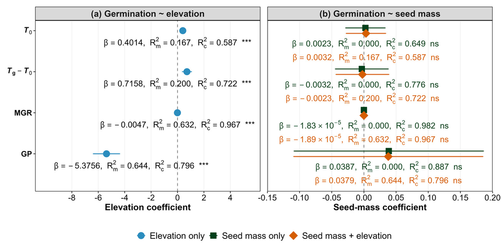

Associations of germination with source elevation and 100-seed mass

Associations of germination with source elevation and 100-seed mass in Arabis alpina. (a) Elevation-only models. (b) Mass-only and elevation-adjusted mass models. Circles, squares and diamonds distinguish the three model sets in that order. Points are coefficients and bars are 95% confidence intervals. Dashed lines mark zero. Coefficients are per 100 m in (a) and per mg of 100-seed mass in (b). Responses are time to first germination (T0; days), time spread (Tg – T0, days), mean germination rate (MGR, day-1) and germination percentage (GP, coefficients in percentage points). Annotations give coefficients (β), marginal R2 (R2m), conditional R2 (R2c) and significance (ns, P ≥ 0.05, and ***, P < 0.001).

### 5.2.3 Table 2. Gaussian mixed-effects estimates for H7–H8

Source elevation, 100-seed mass and germination responses in 581 maternal accessions. H7a is time to first germination (T0), H7b mean germination rate (MGR), H7c germination percentage (GP), and H7d time spread (Tg-T0). H7d has no directional prediction. H8a, H8b and H8c concern T0, MGR and GP, respectively; H8 time spread also has no directional prediction. Coefficients and confidence limits are per 100-m source-elevation increase for H7 and per 1-mg increase in measured 100-seed mass for H8. Timing responses are in days, MGR in inverse days and GP in percentage points. P values test coefficients against zero. Each H8 response has an unadjusted and an elevation-adjusted model; Table S1 compares these pairs. Marginal_R2 and Conditional_R2 describe marginal and conditional R-squared. Convergence and singularity flags are retained from the fitted models.

| Table_section | Hypothesis | Response | Model | Term | Estimate | SE | CI_low | CI_high | P | Coefficient_unit | Marginal_R2 | Conditional_R2 | N | Singular | Converged | AIC | Residual_df | Expected_direction | Direction_consistent |
| --- | --- | --- | --- | --- | --- | --- | --- | --- | --- | --- | --- | --- | --- | --- | --- | --- | --- | --- | --- |
| Elevation and germination | H7a | t0 | Elevation only | Elevation_z | 0.401 | 0.091 | 0.223 | 0.580 | < 0.001 | per 100-m elevation increase | 0.167 | 0.587 | 581 | TRUE | TRUE | 1746.396 | 576 | positive | TRUE |
| Elevation and germination | H7d | Time_spread | Elevation only | Elevation_z | 0.716 | 0.179 | 0.366 | 1.066 | < 0.001 | per 100-m elevation increase | 0.200 | 0.722 | 581 | FALSE | TRUE | 2098.887 | 576 | not specified | NA |
| Elevation and germination | H7b | MGR | Elevation only | Elevation_z | -0.005 | 4.650e-04 | -0.006 | -0.004 | < 0.001 | per 100-m elevation increase | 0.632 | 0.967 | 581 | TRUE | TRUE | -5598.059 | 576 | negative | TRUE |
| Elevation and germination | H7c | GP | Elevation only | Elevation_z | -5.376 | 0.512 | -6.379 | -4.372 | < 0.001 | per 100-m elevation increase | 0.644 | 0.796 | 581 | FALSE | TRUE | 3548.632 | 576 | negative | TRUE |
| Maternal seed mass and germination | H8a | t0 | 100-seed mass only | Seed_mass_100_centered_mg | 0.002 | 0.016 | -0.028 | 0.033 | 0.882 | per 1-mg increase in measured 100-seed mass | 0.000 | 0.649 | 581 | FALSE | TRUE | 1757.338 | 576 | negative | FALSE |
| Maternal seed mass and germination | H8a | t0 | 100-seed mass + elevation | Seed_mass_100_centered_mg | 0.003 | 0.016 | -0.028 | 0.034 | 0.839 | per 1-mg increase in measured 100-seed mass | 0.167 | 0.587 | 581 | TRUE | TRUE | 1748.354 | 575 | negative | FALSE |
| Maternal seed mass and germination | H8_spread | Time_spread | 100-seed mass only | Seed_mass_100_centered_mg | -0.003 | 0.021 | -0.044 | 0.038 | 0.878 | per 1-mg increase in measured 100-seed mass | 0.000 | 0.776 | 581 | FALSE | TRUE | 2109.241 | 576 | not specified | NA |
| Maternal seed mass and germination | H8_spread | Time_spread | 100-seed mass + elevation | Seed_mass_100_centered_mg | -0.002 | 0.021 | -0.043 | 0.039 | 0.913 | per 1-mg increase in measured 100-seed mass | 0.200 | 0.722 | 581 | FALSE | TRUE | 2100.875 | 575 | not specified | NA |
| Maternal seed mass and germination | H8b | MGR | 100-seed mass only | Seed_mass_100_centered_mg | -1.833e-05 | 2.685e-05 | -7.096e-05 | 3.430e-05 | 0.495 | per 1-mg increase in measured 100-seed mass | 0.000 | 0.982 | 581 | FALSE | TRUE | -5577.076 | 576 | positive | FALSE |
| Maternal seed mass and germination | H8b | MGR | 100-seed mass + elevation | Seed_mass_100_centered_mg | -1.892e-05 | 2.685e-05 | -7.155e-05 | 3.371e-05 | 0.481 | per 1-mg increase in measured 100-seed mass | 0.632 | 0.967 | 581 | TRUE | TRUE | -5596.555 | 575 | positive | FALSE |
| Maternal seed mass and germination | H8c | GP | 100-seed mass only | Seed_mass_100_centered_mg | 0.039 | 0.075 | -0.109 | 0.186 | 0.607 | per 1-mg increase in measured 100-seed mass | 0.000 | 0.887 | 581 | FALSE | TRUE | 3578.756 | 576 | positive | TRUE |
| Maternal seed mass and germination | H8c | GP | 100-seed mass + elevation | Seed_mass_100_centered_mg | 0.038 | 0.075 | -0.109 | 0.185 | 0.613 | per 1-mg increase in measured 100-seed mass | 0.644 | 0.796 | 581 | FALSE | TRUE | 3550.377 | 575 | positive | TRUE |

### 5.2.4 Table S3. Sensitivity to the germination response distribution

Sensitivity of germination-elevation associations to the response distribution. All fits use the same 581 maternal accessions and block and nested-plot random intercepts. GP, MGR and T0 denote germination percentage, mean germination rate and time to first germination. Coefficients (β) and standard errors (SE) are expressed per 100-m elevation increase on the log-odds scale for GP, log-mean scale for MGR and cumulative-logit scale for timing responses. CI- and CI+ denote lower and upper 95% Wald confidence limits. Conv., Hess. and SE fin. indicate convergence a positive-definite Hessian and finite fixed-effect standard errors, respectively. Bound. indicates whether at least one random-intercept variance was near zero. U, D and O are DHARMa uniformity, dispersion and outlier P values from 1,000 simulations. Accept. indicates whether a fit met the numerical acceptance criteria. Boundary estimates alone did not exclude a fit. Both ordinal models exceeded the maximum absolute gradient threshold of 0.0001. Their coefficients and standard errors are descriptive, and confidence intervals are withheld. Dashes indicate unavailable or inapplicable entries. Bold coefficients indicate P < 0.001. Values are rounded.

| Response | Model/link | Package/function | Elevation coefficient per 100 m | Standard error per 100 m | 95% CI lower limit | 95% CI upper limit | P value (coefficient = 0) | Number of accessions | Converged | Positive-definite Hessian | Finite fixed-effect standard errors | Boundary random-effect variance | Maximum absolute gradient | DHARMa uniformity P value | DHARMa dispersion P value | DHARMa outlier P value | Accepted sensitivity fit | Warnings |
| --- | --- | --- | --- | --- | --- | --- | --- | --- | --- | --- | --- | --- | --- | --- | --- | --- | --- | --- |
| GP | Binomial (logit) | glmmTMB::glmmTMB | -0.311 | 0.031 | -0.372 | -0.250 | <0.001 | 581 | Yes | Yes | Yes | No | - | 0.836 | 0.682 | 0.112 | Yes | - |
| GP | Beta-binomial (logit) | glmmTMB::glmmTMB | -0.310 | 0.031 | -0.371 | -0.250 | <0.001 | 581 | Yes | Yes | Yes | No | - | 0.832 | 0.832 | 0.323 | Yes | - |
| MGR | Gamma (log) | glmmTMB::glmmTMB | -0.067 | 0.007 | -0.081 | -0.052 | <0.001 | 581 | Yes | Yes | Yes | Yes | - | 0.844 | 0.816 | 0.323 | Yes | - |
| t0 | Ordinal (logit) | ordinal::clmm | 1.013 | 0.255 | - | - | - | 581 | No | Yes | Yes | Yes | 0.000 | - | - | - | No | - |
| Time spread | Ordinal (logit) | ordinal::clmm | 1.110 | 0.285 | - | - | - | 581 | No | Yes | Yes | No | 0.000 | - | - | - | No | step factor reduced below minimum when updating the random effects at iteration 5470 |

# 6 Mid-century projections

The projection script compares the June 2021 baseline with 2041–2060 predictions under SSP2-4.5 and SSP5-8.5. The report displays saved results. Archived projection filenames are accepted as fallbacks for Figures 7 and S6.

## 6.1 Climate projection code

**Source:** `scripts/10_projected_trait_changes_mid_century.R`

```r
# 1. Local publication support functions -------------------------------------

# Local definitions: this script never sources another R file.
publication_root <- "outputs"
publication_captions <- c(
  Table_3 = "Table 3. Modelled baseline means for June 2021 and projected means and changes for 2041-2060. Projections weight three climatic models equally. MISM is the average of conditional median masses from exponentiated log-scale predictions. Change is future minus baseline. Units are days for onset and duration, mg per seed for MISM and seeds per plant for seed number. CI- and CI+ are the 95% percentile bootstrap limits for mean changes, using 1,000 replicates per trait. Means and changes were rounded independently. Seed-number estimates use the revised nbinom2 model without random intercepts. All 1,000 seed-number refits passed numerical checks.",
  Figure_S6 = "Figure S6. Projected changes in Arabis alpina reproductive traits for 2041-2060 relative to June 2021. (a) Flowering onset. (b) Flowering duration. (c) Mean individual seed mass (MISM). (d) Total seed number. Brown and yellow indicate SSP2-4.5 and SSP5-8.5. Violin widths show the density of mean changes over 1,000 parametric bootstrap replicates. Points are estimated mean changes, weighted equally across three climate models, and bars are 95% percentile bootstrap intervals. Annotations give changes and confidence limits. Vertical dashed lines mark zero. Seed-number estimates use the revised nbinom2 model without random intercepts."
)
publication_table_3 <- function() {
  td <- file.path(publication_root, "projected_trait_changes_mid_century", "tables")
  f <- file.path(td, "Table_RQ6_scenario_mean_changes.csv")
  if (!file.exists(f)) {
    return(invisible(NULL))
  }
  t <- utils::read.csv(f, check.names = FALSE)
  names(t)[names(t) == "Successful_bootstraps"] <- "Retained_bootstraps"
  t$Response_unit <- ifelse(t$Trait %in% c("Flowering_onset", "Flowering_duration"), "days",
    ifelse(t$Trait == "MISM", "mg per seed", "seeds per plant")
  )
  t$Prediction_summary <- ifelse(t$Trait == "MISM", "Mean of plant-level conditional medians",
    "Mean of plant-level conditional expected values"
  )
  utils::write.csv(t, file.path(td, "Table_3.csv"), row.names = FALSE)
  writeLines(publication_captions[["Table_3"]], file.path(td, "Table_3_caption.txt"))
  if (requireNamespace("openxlsx", quietly = TRUE)) {
    wb <- openxlsx::createWorkbook()
    openxlsx::addWorksheet(wb, "Table 3")
    openxlsx::writeData(wb, "Table 3", t)
    openxlsx::setColWidths(wb, "Table 3", cols = seq_len(ncol(t)), widths = c(16, 25, 17, 17, 17, 20, 20, 19, 20, 49))
    style <- openxlsx::createStyle(fontName = "Arial", fontSize = 10, wrapText = TRUE, valign = "center")
    openxlsx::addStyle(wb, "Table 3", style, rows = 1:(nrow(t) + 1), cols = seq_len(ncol(t)), gridExpand = TRUE)
    openxlsx::setRowHeights(wb, "Table 3", rows = 1:(nrow(t) + 1), heights = 33)
    openxlsx::freezePane(wb, "Table 3", firstActiveRow = 2, firstActiveCol = 3)
    openxlsx::writeData(wb, "Table 3", "Table 3 notes", startRow = 12, colNames = FALSE)
    openxlsx::writeData(wb, "Table 3", publication_captions[["Table_3"]], startRow = 13, colNames = FALSE)
    openxlsx::mergeCells(wb, "Table 3", cols = 1:10, rows = 13:17)
    openxlsx::addStyle(wb, "Table 3", style, rows = 13:17, cols = 1:10, gridExpand = TRUE)
    openxlsx::saveWorkbook(wb, file.path(td, "Table_3.xlsx"), overwrite = TRUE)
  }
  invisible(t)
}
publication_render_tables <- function() {
  fp <- file.path(publication_root, "flowering_phenology", "tables")
  msa <- file.path(publication_root, "maternal_seed_allocation", "tables")
  ge <- file.path(publication_root, "germination_elevation", "tables")
  files <- file.path(publication_root, c("projected_trait_changes_mid_century/tables/Table_3.csv"))
  for (f in files[file.exists(files)]) {
    d <- utils::read.csv(f, check.names = FALSE)
    stem <- tools::file_path_sans_ext(basename(f))
    out <- file.path(dirname(f), "gt")
    dir.create(out, recursive = TRUE, showWarnings = FALSE)
    title <- if (stem == "Table_1") "Table 1" else if (grepl("Table_S1", stem)) "Table S1" else if (grepl("^Table_2", stem)) "Table 2" else if (stem == "Table_3") "Table 3" else gsub("_", " ", stem)
    caption <- if (title %in% c("Table 1", "Table 2", "Table 3", "Table S1")) publication_captions[[gsub(" ", "_", title)]] else "H3 coefficients describe final flowering date; P_zero tests zero and P_duration tests one."
    tab <- gt::gt(d) |>
      gt::tab_header(title = title) |>
      gt::tab_source_note(caption) |>
      gt::fmt_number(columns = names(d)[vapply(d, is.numeric, logical(1))], decimals = 6) |>
      gt::sub_missing(missing_text = "-")
    gt::gtsave(tab, file.path(out, paste0(stem, ".html")), inline_css = TRUE)
    gt::gtsave(tab, file.path(out, paste0(stem, ".rtf")))
  }
}
publication_figure_exports <- function() {
  from <- file.path(publication_root, "projected_trait_changes_mid_century/figures/Figure_RQ6_bootstrap_trait_changes")
  to <- file.path(dirname(from), "Figure_S6_bootstrap_trait_changes")
  records <- list()
  for (ext in c("png", "pdf", "tiff")) {
    input <- paste0(from, ".", ext)
    output <- paste0(to, ".", ext)
    if (file.exists(input)) {
      # A publication filename may already be the source filename.
      input_path <- normalizePath(input, winslash = "/", mustWork = TRUE)
      output_path <- file.path(
        normalizePath(dirname(output), winslash = "/", mustWork = TRUE),
        basename(output)
      )
      if (file.exists(output)) {
        output_path <- normalizePath(output, winslash = "/", mustWork = TRUE)
      }
      if (.Platform$OS.type == "windows") {
        input_path <- tolower(input_path)
        output_path <- tolower(output_path)
      }
      if (!identical(input_path, output_path)) {
        stopifnot(file.copy(input, output, overwrite = TRUE))
      }
      records[[length(records) + 1L]] <- data.frame(Number = "Figure S6", Format = ext, File = output)
    }
  }
  if (!length(records)) {
    return(invisible(NULL))
  }
  writeLines(publication_captions[["Figure_S6"]], paste0(to, "_caption.txt"))
  writeLines(publication_captions[["Figure_S6"]], paste0(from, "_caption.txt"))
  manifest_file <- file.path(publication_root, "Publication_figure_manifest.csv")
  updated <- do.call(rbind, records)
  if (file.exists(manifest_file)) {
    previous <- utils::read.csv(manifest_file, stringsAsFactors = FALSE)
    previous <- previous[previous$Number != "Figure S6", , drop = FALSE]
    updated <- rbind(previous[, names(updated), drop = FALSE], updated)
  }
  utils::write.csv(updated, manifest_file, row.names = FALSE)
  invisible(updated)
}
# END INLINE PUBLICATION SUPPORT
```

```r
# Flowering calendar: 1 June 2021 = Day 1; date = 2021-06-01 + day - 1.
# Duration = final flowering day minus onset day (elapsed days).
# ============================================================================

# Script 10: CONDITIONAL MID-CENTURY TRAIT PROJECTIONS

# Research question 5. Run from the "arabis analysis" project root.

# ============================================================================

# 2. Marginal and conditional R-squared: calculation and figure notation -----

# Nakagawa marginal and conditional R-squared. No degrees-of-freedom adjustment.
model_r2 <- function(model, null_model = NULL) {
  if (inherits(model, "lm") && !inherits(model, "glm")) {
    r <- summary(model)$r.squared
    return(c(Marginal = r, Conditional = r))
  }
  if (inherits(model, "merMod")) {
    vf <- var(as.numeric(lme4::getME(model, "X") %*% lme4::fixef(model)))
    vr <- sum(vapply(lme4::VarCorr(model), function(v) as.numeric(v[1, 1]), numeric(1)))
    total <- vf + vr + sigma(model)^2
    return(c(Marginal = vf / total, Conditional = (vf + vr) / total))
  }
  if (inherits(model, "glmmTMB")) {
    # Explicit null fits avoid dependence on data/family names in saved calls.
    if (is.null(null_model)) {
      random <- lme4::findbars(formula(model))
      rhs <- paste(c("1", vapply(random, function(x) paste0("(", paste(deparse(x), collapse = ""), ")"), character(1))), collapse = " + ")
      response <- paste(deparse(formula(model)[[2]]), collapse = "")
      null_model <- suppressWarnings(glmmTMB::glmmTMB(
        as.formula(paste(response, "~", rhs)),
        data = model$frame,
        family = family(model)
      ))
    }
    values <- suppressWarnings(MuMIn::r.squaredGLMM(model, null = null_model))
    row <- if ("delta" %in% rownames(values)) "delta" else 1L
    result <- c(Marginal = unname(values[row, "R2m"]), Conditional = unname(values[row, "R2c"]))
    if (any(!is.finite(result))) stop("Non-finite mixed-model R-squared; inspect the fitted model.")
    return(result)
  }
  stop("Unsupported model class for marginal and conditional R-squared.")
}
r2_plotmath <- function(marginal, conditional, digits = 3) {
  if (is.finite(marginal) && is.finite(conditional) &&
    round(marginal, digits) == round(conditional, digits)) {
    return(c(sprintf(paste0("R[m]^2~~'&'~~R[c]^2 == %.", digits, "f"), marginal), NA_character_))
  }
  c(
    sprintf(paste0("R[m]^2 == %.", digits, "f"), marginal),
    sprintf(paste0("R[c]^2 == %.", digits, "f"), conditional)
  )
}
# End of marginal and conditional r-squared: calculation and figure notation.

# 3. Packages and output directories -----------------------------------------

required <- c("readxl", "dplyr", "tidyr", "ggplot2", "lme4", "glmmTMB", "ggh4x", "ggpubr")
missing <- required[!vapply(required, requireNamespace, logical(1), quietly = TRUE)]
if (length(missing)) stop("Install required packages: ", paste(missing, collapse = ", "))
suppressPackageStartupMessages({
  library(readxl)
  library(dplyr)
  library(tidyr)
  library(ggplot2)
  library(lme4)
  library(glmmTMB)
})
if (!file.exists("arabis analysis.Rproj")) stop("Run from the 'arabis analysis' project root.")
set.seed(12191)
n_boot <- as.integer(Sys.getenv("PROJECTION_BOOTSTRAPS", "1000"))
if (!is.finite(n_boot) || n_boot < 1) stop("PROJECTION_BOOTSTRAPS must be a positive integer.")
input_dir_mc <- file.path("data", "raw", "Datasets")
climate_file <- file.path(input_dir_mc, "plot_abiotic_factors.xlsx")
trait_file <- file.path(input_dir_mc, "trait_data.xlsx")
output_dir_mc <- file.path("outputs", "projected_trait_changes_mid_century")
table_dir_mc <- file.path(output_dir_mc, "tables")
figure_dir_mc <- file.path(output_dir_mc, "figures")
model_dir_mc <- file.path(output_dir_mc, "models")
diagnostic_dir_mc <- file.path(output_dir_mc, "diagnostics")
# Keep HTML styling caches local to this R session, including restricted hosts.
if (!nzchar(Sys.getenv("R_USER_CACHE_DIR"))) {
  projection_render_cache <- file.path(tempdir(), "arabis_projection_render_cache")
  dir.create(projection_render_cache, recursive = TRUE, showWarnings = FALSE)
  Sys.setenv(R_USER_CACHE_DIR = projection_render_cache)
}
invisible(lapply(c(table_dir_mc, figure_dir_mc, model_dir_mc, diagnostic_dir_mc), dir.create,
  recursive = TRUE, showWarnings = FALSE
))
cache_requested <- identical(Sys.getenv("REUSE_RQ6_BOOTSTRAP", "0"), "1")
explicit_cache_dir <- Sys.getenv("PROJECTION_BOOTSTRAP_CACHE_DIR", "")
cache_dir <- if (nzchar(explicit_cache_dir)) explicit_cache_dir else model_dir_mc
cache_model_file <- file.path(cache_dir, "Models_RQ6_full_climate_trait_models.rds")
cache_draw_file <- Sys.getenv("PROJECTION_BOOTSTRAP_CACHE_FILE", file.path(cache_dir, "Bootstrap_RQ6_change_draws.rds"))
cached_models <- if (cache_requested && file.exists(cache_model_file)) readRDS(cache_model_file) else NULL
cached_draws <- if (cache_requested && file.exists(cache_draw_file)) readRDS(cache_draw_file) else NULL

# Standardise reported precision without reducing precision used in analyses.
write.csv <- function(x, file = "", ..., row.names = TRUE) {
  x <- as.data.frame(x)
  x[] <- lapply(x, function(v) if (is.numeric(v)) round(v, 3) else v)
  utils::write.csv(x, file = file, ..., row.names = row.names)
}
gcms <- c("ACCESS-CM2", "BCC-CSM2-MR", "CMCC-ESM2")
scenarios <- c("SSP2-4.5", "SSP5-8.5")
theme_manuscript <- function(base_size = 11) {
  theme_bw(base_size = base_size, base_family = "Arial") +
    theme(
      text = element_text(family = "Arial", colour = "black"),
      axis.title = element_text(face = "bold", size = 12),
      axis.text = element_text(colour = "black", size = 11),
      strip.text = element_text(face = "bold", hjust = 0),
      panel.grid.minor = element_blank(),
      panel.grid.major = element_blank(),
      legend.position = "bottom"
    )
}
save_figure <- function(p, stem, width = 150, height = 120) {
  ggsave(file.path(figure_dir_mc, paste0(stem, ".png")), p,
    width = width,
    height = height, units = "mm", dpi = 600, bg = "white"
  )
  ggsave(file.path(figure_dir_mc, paste0(stem, ".pdf")), p,
    width = width,
    height = height, units = "mm", device = cairo_pdf, bg = "white"
  )
}
```

```r
# 4. Historical and CMIP6 climate data ---------------------------------------

historical <- read_excel(climate_file, sheet = "June summary", skip = 3) |>
  transmute(Plot_ID,
    Block = factor(Block), Plot = as.integer(Plot),
    Elevation_m = as.numeric(Elevation_m),
    Temperature_C = as.numeric(June_mean_temperature_C),
    Precipitation_mm = as.numeric(June_total_precipitation_mm),
    Longitude = as.numeric(Longitude), Latitude = as.numeric(Latitude)
  )
future <- read_excel(climate_file, sheet = "2050 model values", skip = 3) |>
  transmute(Plot_ID, GCM, Scenario, Period,
    Block = factor(Block), Plot = as.integer(Plot),
    Elevation_m = as.numeric(Elevation_m),
    Temperature_C = as.numeric(Projected_June_mean_temperature_C),
    Precipitation_mm = as.numeric(Projected_June_precipitation_mm)
  ) |>
  filter(GCM %in% gcms, Scenario %in% scenarios)
expected_future <- tidyr::crossing(
  Plot_ID = historical$Plot_ID,
  GCM = gcms, Scenario = scenarios
)
future_keys <- distinct(future, Plot_ID, GCM, Scenario)
if (nrow(historical) != 27L || anyDuplicated(historical$Plot_ID)) {
  stop("Historical climate data must contain 27 unique source plots.")
}
if (nrow(future_keys) != nrow(expected_future) ||
  nrow(anti_join(expected_future, future_keys,
    by = c("Plot_ID", "GCM", "Scenario")
  )) > 0) {
  stop("Future climate data do not contain every plot x GCM x scenario combination.")
}
if (anyNA(historical) || anyNA(future[, c("Temperature_C", "Precipitation_mm")])) {
  stop("Historical or future climate predictors contain missing values.")
}

# 5. Plant-level soil PC1 and historical predictor scaling -------------------

trait_raw <- read_excel(trait_file, sheet = "Sheet2", .name_repair = function(x) make.unique(x, sep = "_duplicate"))
soil_plant <- trait_raw |>
  transmute(
    plant_no = as.integer(plant_no), Block = factor(Block), Plot = as.integer(Plot),
    Elevation_m = as.numeric(Elevation),
    Carbon = as.numeric(Carbon), pH = as.numeric(pH),
    EC = as.numeric(Electrical.Conductivity),
    Nitrogen = as.numeric(Nitrogen), Phosphorus = as.numeric(Phosphorus)
  )
if (nrow(soil_plant) != nrow(trait_raw) || anyNA(soil_plant)) {
  stop("Expected complete soil predictors for every plant.")
}
soil_plot <- soil_plant |>
  group_by(Block, Plot, Elevation_m) |>
  summarise(across(c(Carbon, pH, EC, Nitrogen, Phosphorus), mean), .groups = "drop")
if (nrow(soil_plot) != 27L) stop("Expected 27 plot soil records.")
soil_pca <- prcomp(select(soil_plot, Carbon, pH, EC, Nitrogen, Phosphorus),
  center = TRUE, scale. = TRUE
)
if (mean(soil_pca$rotation[c("Carbon", "pH", "Nitrogen", "Phosphorus"), "PC1"]) < 0) {
  soil_pca$rotation[, "PC1"] <- -soil_pca$rotation[, "PC1"]
  soil_pca$x[, "PC1"] <- -soil_pca$x[, "PC1"]
}
soil_plot$Soil_PC1 <- soil_pca$x[, "PC1"]
plot_env <- soil_plot |> left_join(historical, by = c("Block", "Plot", "Elevation_m"))
plant_env <- soil_plant |>
  select(plant_no, Block, Plot, Elevation_m) |>
  left_join(plot_env, by = c("Block", "Plot", "Elevation_m"))
scaling <- plot_env |>
  summarise(across(
    c(Elevation_m, Soil_PC1, Temperature_C, Precipitation_mm),
    list(mean = mean, sd = sd)
  ))
z_from_baseline <- function(x, variable) {
  (x - scaling[[paste0(variable, "_mean")]]) /
    scaling[[paste0(variable, "_sd")]]
}
plant_env <- plant_env |>
  mutate(
    Elevation_z = z_from_baseline(Elevation_m, "Elevation_m"),
    Soil_PC1_z = z_from_baseline(Soil_PC1, "Soil_PC1"),
    Temperature_z = z_from_baseline(Temperature_C, "Temperature_C"),
    Precipitation_z = z_from_baseline(Precipitation_mm, "Precipitation_mm"),
    Plot_factor = factor(interaction(Block, Plot, drop = TRUE))
  )
future_env <- future |>
  left_join(select(
    plant_env, plant_no, Plot_ID, Soil_PC1, Soil_PC1_z, Elevation_z,
    Plot_factor
  ), by = "Plot_ID", relationship = "many-to-many") |>
  mutate(
    Temperature_z = z_from_baseline(Temperature_C, "Temperature_C"),
    Precipitation_z = z_from_baseline(Precipitation_mm, "Precipitation_mm")
  )
write.csv(plant_env, file.path(table_dir_mc, "Table_RQ6_historical_predictors.csv"), row.names = FALSE)
write.csv(future_env, file.path(table_dir_mc, "Table_RQ6_future_predictors_by_GCM.csv"), row.names = FALSE)
write.csv(
  data.frame(
    Variable = names(soil_pca$rotation[, 1]),
    PC1_loading = soil_pca$rotation[, 1]
  ),
  file.path(table_dir_mc, "Table_RQ6_soil_PC1_loadings.csv"),
  row.names = FALSE
)
write.csv(t(scaling), file.path(table_dir_mc, "Table_RQ6_predictor_scaling.csv"))

# 6. Plant-level model data --------------------------------------------------

plant_data <- trait_raw |>
  transmute(
    plant_no = as.integer(plant_no), Block = factor(Block), Plot = as.integer(Plot),
    Elevation_m = as.numeric(Elevation),
    Flowering_onset = as.numeric(FloweringOnset),
    Flowering_duration = as.numeric(Final_flowering_date) - as.numeric(FloweringOnset),

    # Mean individual seed mass (MISM), in mg per seed, from trait_data.
    MISM = as.numeric(MISM),
    Seed_number = as.numeric(TotalSeedNumber)
  ) |>
  left_join(
    select(
      plant_env, plant_no, Plot_ID, Elevation_z,
      Soil_PC1_z, Temperature_z, Precipitation_z, Plot_factor
    ),
    by = "plant_no"
  )
fixed_terms <- c("Elevation_z", "Soil_PC1_z", "Temperature_z", "Precipitation_z")
random_term <- "(1 | Block/Plot_factor)"
complete_for <- function(response) {
  plant_data |>
    filter(if_all(
      all_of(c(response, fixed_terms, "Block", "Plot_factor")),
      ~ !is.na(.x)
    ))
}
onset_data <- complete_for("Flowering_onset")
duration_data <- complete_for("Flowering_duration")
mass_data <- complete_for("MISM") |>
  filter(MISM > 0) |>
  mutate(Log_MISM = log(MISM))
number_data <- complete_for("Seed_number") |>
  filter(Seed_number >= 0) |>
  mutate(Seed_number = as.integer(round(Seed_number)))
full_formula <- function(response) {
  as.formula(paste(
    response, "~", paste(fixed_terms, collapse = " + "), "+", random_term
  ))
}
# Resolve an unstable projection count model only when both random-intercept
# variances are negligible. Keep the NB2 family, log link and all fixed effects.
fit_projection_seed_number <- function(number_data) {
  full <- glmmTMB::glmmTMB(full_formula("Seed_number"), data = number_data,
    family = glmmTMB::nbinom2(link = "log"), na.action = na.fail)
  variances <- unlist(lapply(glmmTMB::VarCorr(full)$cond, diag))
  full_se <- summary(full)$coefficients$cond[, "Std. Error"]
  full_ok <- isTRUE(full$fit$convergence == 0) && isTRUE(full$sdr$pdHess) &&
    all(is.finite(full_se))
  negligible <- length(variances) == 2L && all(variances < 1e-8)
  if (full_ok) return(full)
  if (!negligible) stop("Unstable seed-number model with non-negligible random effects; investigate before inference.")
  saveRDS(full, file.path(model_dir_mc, "Models_seed_number_original_unstable.rds"))
  reduced <- glmmTMB::glmmTMB(reformulate(fixed_terms, response = "Seed_number"),
    data = number_data, family = glmmTMB::nbinom2(link = "log"), na.action = na.fail)
  reduced_se <- summary(reduced)$coefficients$cond[, "Std. Error"]
  stopifnot(isTRUE(reduced$fit$convergence == 0), isTRUE(reduced$sdr$pdHess),
    all(is.finite(reduced_se)))
  comparison <- data.frame(Model = c("Original nested random intercepts", "Resolved NB2 without random intercepts"),
    LogLik = c(as.numeric(logLik(full)), as.numeric(logLik(reduced))),
    AIC = c(AIC(full), AIC(reduced)),
    Finite_fixed_effect_SE = c(all(is.finite(full_se)), all(is.finite(reduced_se))))
  utils::write.csv(comparison, file.path(table_dir_mc,
    "Table_seed_number_projection_structure_resolution.csv"), row.names = FALSE)
  message("Seed-number projection: removed two negligible random-intercept components (<1e-8 variance) after the full model failed numerical checks.")
  reduced
}
```

```r
models <- list(
  Flowering_onset = lmer(full_formula("Flowering_onset"), onset_data,
    REML = FALSE, na.action = na.fail
  ),
  Flowering_duration = lmer(full_formula("Flowering_duration"), duration_data,
    REML = FALSE, na.action = na.fail
  ),
  MISM = lmer(full_formula("Log_MISM"), mass_data,
    REML = FALSE, na.action = na.fail
  ),
  Total_seed_number = fit_projection_seed_number(number_data)
)
saveRDS(models, file.path(model_dir_mc, "Models_RQ6_full_climate_trait_models.rds"))
capture.output(lapply(models, summary),
  file = file.path(model_dir_mc, "Models_RQ6_summaries.txt")
)
model_info <- data.frame(
  Trait = names(models),
  Distribution = c("Gaussian", "Gaussian", "Gaussian on log scale", "negative binomial (nbinom2)"),
  N = vapply(models, nobs, numeric(1)),
  Random_effects = vapply(models, function(model) {
    if (length(reformulas::findbars(formula(model)))) "Nested block and plot intercepts" else
      "None: negligible components removed after numerical failure"
  }, character(1)),
  Positive_definite_Hessian = vapply(models, function(m) {
    if (inherits(m, "glmmTMB")) isTRUE(m$sdr$pdHess) else NA
  }, logical(1)),
  Marginal_R2 = vapply(models, function(m) model_r2(m)[["Marginal"]], numeric(1)),
  Conditional_R2 = vapply(models, function(m) model_r2(m)[["Conditional"]], numeric(1)),
  Singular = c(vapply(models[1:3], lme4::isSingular, logical(1), tol = 1e-4), NA),
  stringsAsFactors = FALSE
)
write.csv(model_info, file.path(table_dir_mc, "Table_RQ6_model_information.csv"), row.names = FALSE)

# 7. Baseline and future predictions on original scales ----------------------

predict_original <- function(model, newdata, trait) {
  # Plants in the same plot share model predictors. Predict once per distinct
  # predictor/grouping vector, then expand to the original plant rows.
  predictor_names <- all.vars(formula(model)[[3L]])
  keys <- as.data.frame(newdata)[, predictor_names, drop = FALSE]
  unique_rows <- !duplicated(keys)
  index <- vctrs::vec_match(keys, keys[unique_rows, , drop = FALSE])
  prediction_data <- newdata[unique_rows, , drop = FALSE]
  value <- if (trait == "Total_seed_number") {
    as.numeric(predict(model, prediction_data,
      type = "response", re.form = NULL, allow.new.levels = TRUE))
  } else {
    as.numeric(predict(model, prediction_data,
      re.form = NULL, allow.new.levels = TRUE))
  }
  # For MISM this is a conditional median, not an arithmetic expected mass.
  if (trait == "MISM") value <- exp(value)
  value[index]
}
baseline_predictions <- bind_rows(lapply(names(models), function(trait) {
  data.frame(select(plant_env, plant_no, Elevation_m),
    Trait = trait,
    Baseline = predict_original(models[[trait]], plant_env, trait)
  )
}))
gcm_predictions <- bind_rows(lapply(names(models), function(trait) {
  data.frame(select(future_env, plant_no, Elevation_m, GCM, Scenario),
    Trait = trait,
    Future = predict_original(models[[trait]], future_env, trait)
  )
})) |>
  left_join(baseline_predictions, by = c("plant_no", "Elevation_m", "Trait")) |>
  mutate(Change = Future - Baseline)
ensemble_predictions <- gcm_predictions |>
  group_by(plant_no, Elevation_m, Scenario, Trait) |>
  summarise(
    Baseline = first(Baseline), Future = mean(Future),
    GCM_min = min(Future), GCM_max = max(Future),
    Change = mean(Change), .groups = "drop"
  )

# 8. Parametric bootstrap: simulate, refit, and recompute paired changes -----

projection_keys <- ensemble_predictions |>
  select(plant_no, Elevation_m, Scenario, Trait)
projection_refit_diagnostics <- function(fit) {
  gaussian <- inherits(fit, "merMod")
  hessian <- if (gaussian) fit@optinfo$derivs$Hessian else NULL
  hessian_ok <- if (gaussian) {
    if (is.null(hessian) || any(!is.finite(hessian))) NA else
      all(eigen(hessian, symmetric = TRUE, only.values = TRUE)$values > 0)
  } else isTRUE(fit$sdr$pdHess)
  convergence_messages <- if (gaussian) fit@optinfo$conv$lme4$messages else fit$fit$message
  converged <- if (gaussian) {
    all(fit@optinfo$conv$opt == 0) && !length(setdiff(
      convergence_messages, "boundary (singular) fit: see help('isSingular')"))
  } else isTRUE(fit$fit$convergence == 0)
  standard_errors <- if (gaussian) coef(summary(fit))[, "Std. Error"] else
    summary(fit)$coefficients$cond[, "Std. Error"]
  singular <- if (gaussian) lme4::isSingular(fit, tol = 1e-4) else {
    # Variance-component boundary screen; glmmTMB has no isSingular method.
    variances <- unlist(lapply(glmmTMB::VarCorr(fit)$cond, diag))
    any(variances < 1e-8)
  }
  list(Converged = converged, Positive_definite_Hessian = hessian_ok,
    Finite_fixed_effect_SE = all(is.finite(standard_errors)), Singular = singular,
    Convergence_messages = paste(convergence_messages, collapse = " | "))
}
bootstrap_trait <- function(model, trait, n_sim) {
  row_keys <- tidyr::crossing(plant_no = plant_env$plant_no, Scenario = scenarios) |>
    left_join(select(plant_env, plant_no, Elevation_m), by = "plant_no")
  workers <- as.integer(Sys.getenv("PROJECTION_BOOTSTRAP_WORKERS", "4"))
  stopifnot(workers >= 1L)
  one <- function(b) {
    warnings <- messages <- character()
    error_text <- ""
    stage <- "simulation"
    diagnostics <- list(Converged = NA, Positive_definite_Hessian = NA,
      Finite_fixed_effect_SE = NA, Singular = NA, Convergence_messages = "")
    value <- tryCatch(withCallingHandlers({
      simulated <- simulate(model, nsim = 1)[[1]]
      stage <- "refit"
      fit <- if (inherits(model, "glmmTMB")) {
        glmmTMB::refit(model, simulated)
      } else {
        # Some saved fits omit derivatives; explicitly calculate them on refit.
        bootstrap_data <- model.frame(model)
        bootstrap_data[[1L]] <- simulated
        lme4::lmer(formula(model), data = bootstrap_data,
          REML = lme4::isREML(model), control = lme4::lmerControl(calc.derivs = TRUE))
      }
      stage <- "diagnostics"
      diagnostics <- projection_refit_diagnostics(fit)
      stage <- "prediction"
      baseline <- predict_original(fit, plant_env, trait)
      future <- data.frame(dplyr::select(future_env, plant_no, Scenario),
        value = predict_original(fit, future_env, trait)) |>
        dplyr::group_by(plant_no, Scenario) |>
        dplyr::summarise(value = mean(value), .groups = "drop") |>
        dplyr::left_join(data.frame(plant_no = plant_env$plant_no, base = baseline), by = "plant_no") |>
        dplyr::mutate(change = value - base)
      dplyr::left_join(row_keys, dplyr::select(future, plant_no, Scenario, change),
        by = c("plant_no", "Scenario"))$change
    }, warning = function(w) {
      warnings <<- c(warnings, conditionMessage(w)); invokeRestart("muffleWarning")
    }, message = function(m) {
      messages <<- c(messages, conditionMessage(m)); invokeRestart("muffleMessage")
    }), error = function(e) {
      error_text <<- conditionMessage(e)
      rep(NA_real_, nrow(row_keys))
    })
    finite <- length(value) == nrow(row_keys) && all(is.finite(value))
    log <- data.frame(Trait = trait, Replicate = b, Stage = stage,
      Error = error_text, Finite_predictions = finite,
      Converged = diagnostics$Converged,
      Positive_definite_Hessian = diagnostics$Positive_definite_Hessian,
      Finite_fixed_effect_SE = diagnostics$Finite_fixed_effect_SE,
      Singular = diagnostics$Singular,
      Convergence_messages = diagnostics$Convergence_messages,
      Warnings = paste(unique(warnings), collapse = " | "),
      Messages = paste(unique(messages), collapse = " | "))
    list(value = value, log = log)
  }
  out <- matrix(NA_real_, nrow(row_keys), n_sim)
  logs <- vector("list", n_sim)
  if (workers > 1L) {
    task_cluster <- parallel::makePSOCKcluster(workers)
    on.exit(parallel::stopCluster(task_cluster), add = TRUE)
    parallel::clusterEvalQ(task_cluster, {
      suppressPackageStartupMessages({library(lme4); library(glmmTMB); library(dplyr)})
      NULL
    })
    parallel::clusterSetRNGStream(task_cluster, 12191L)
    parallel::clusterExport(task_cluster, c("model", "trait", "plant_env", "future_env",
      "row_keys", "predict_original", "projection_refit_diagnostics", "full_formula",
      "fixed_terms", "random_term", "number_data"), envir = environment())
    environment(one) <- .GlobalEnv
  }
  for (start in seq.int(1L, n_sim, by = 50L)) {
    ids <- seq.int(start, min(start + 49L, n_sim))
    batch <- if (workers > 1L) parallel::parLapply(task_cluster, ids, one) else lapply(ids, one)
    for (j in seq_along(ids)) {
      out[, ids[j]] <- batch[[j]]$value
      logs[[ids[j]]] <- batch[[j]]$log
    }
    utils::write.csv(do.call(rbind, logs[seq_len(max(ids))]),
      file.path(diagnostic_dir_mc, paste0("Bootstrap_refit_log_", trait, ".csv")), row.names = FALSE)
    message(trait, ": logged ", max(ids), "/", n_sim, " bootstrap replicates")
  }
  successful <- colSums(is.finite(out)) == nrow(out)
  log <- do.call(rbind, logs)
  log$Retained <- successful
  log$Strict_diagnostic_pass <- successful & log$Converged &
    log$Positive_definite_Hessian & log$Finite_fixed_effect_SE
  utils::write.csv(log, file.path(diagnostic_dir_mc,
    paste0("Bootstrap_refit_log_", trait, ".csv")), row.names = FALSE)
  if (sum(log$Strict_diagnostic_pass, na.rm = TRUE) < ceiling(.9 * n_sim)) {
    warning(trait, ": fewer than 90% of refits passed the numerical checks; inspect the log and interval sensitivity before inference.")
  }
  list(keys = mutate(row_keys, Trait = trait), draws = out[, successful, drop = FALSE],
    successful = sum(successful), attempted = n_sim, failed_replicates = which(!successful),
    refit_log = log)
}
bootstrap_file <- file.path(model_dir_mc, "Bootstrap_RQ6_change_draws.rds")
model_signature <- function(model) {
  list(
    procedure = "20261009_conditional_random_effects_independent_seed_mass",
    frame = lapply(model.frame(model), as.vector),
    beta = if (inherits(model, "glmmTMB")) fixef(model)$cond else fixef(model),
    sigma = sigma(model), random = lapply(if (inherits(model, "glmmTMB")) {
      VarCorr(model)$cond
    } else {
      VarCorr(model)
    }, unclass)
  )
}
new_signatures <- lapply(models, model_signature)
old_signatures <- if (!is.null(cached_draws)) attr(cached_draws, "model_signatures") else NULL
if (is.null(old_signatures) && nzchar(explicit_cache_dir) && !is.null(cached_models)) {
  old_signatures <- lapply(cached_models, model_signature)
}
old_future <- if (!is.null(cached_draws)) attr(cached_draws, "future_predictors") else NULL
future_match <- !is.null(old_future) && isTRUE(all.equal(old_future, future_env, check.attributes = FALSE))
if (is.null(old_future) && nzchar(explicit_cache_dir)) {
  old_table <- file.path(dirname(cache_dir), "tables", "Table_RQ6_future_predictors_by_GCM.csv")
  new_table <- file.path(table_dir_mc, "Table_RQ6_future_predictors_by_GCM.csv")
  if (file.exists(old_table) && file.exists(new_table)) {
    future_match <- isTRUE(all.equal(read.csv(old_table), read.csv(new_table), check.attributes = FALSE))
  }
}
bootstrap_objects <- list()
for (trait in names(models)) {
  verified <- cache_requested && future_match && !is.null(cached_draws[[trait]]$refit_log) &&
    !is.null(old_signatures[[trait]]) &&
    isTRUE(all.equal(old_signatures[[trait]], new_signatures[[trait]],
      tolerance = 1e-8, check.attributes = FALSE
    )) &&
    (if (!is.null(cached_draws[[trait]]$attempted)) cached_draws[[trait]]$attempted == n_boot else ncol(cached_draws[[trait]]$draws) == n_boot)
  if (cache_requested && !verified && identical(Sys.getenv("PROJECTION_REQUIRE_VERIFIED_CACHE", "0"), "1")) {
    stop("Cached logged bootstrap did not match current model/predictors for ", trait)
  }
  if (verified) {
    object <- cached_draws[[trait]]
    object$attempted <- n_boot
    object$successful <- ncol(object$draws)
    message(trait, ": reusing ", n_boot, " draws after verifying model inputs, coefficients and climate predictors")
  } else {
    object <- bootstrap_trait(models[[trait]], trait, n_boot)
  }
  bootstrap_objects[[trait]] <- object
```

```r
  if (!is.null(object$refit_log)) {
    utils::write.csv(object$refit_log, file.path(diagnostic_dir_mc,
      paste0("Bootstrap_refit_log_", trait, ".csv")), row.names = FALSE)
  }
  attr(bootstrap_objects, "model_signatures") <- new_signatures
  attr(bootstrap_objects, "future_predictors") <- future_env
  saveRDS(bootstrap_objects, file.path(model_dir_mc, "Bootstrap_RQ6_progress.rds"))
}
saveRDS(bootstrap_objects, bootstrap_file)
bootstrap_plant_ci <- bind_rows(lapply(bootstrap_objects, function(obj) {
  data.frame(obj$keys,
    Change_CI_low = apply(obj$draws, 1, quantile, .025, na.rm = TRUE),
    Change_CI_high = apply(obj$draws, 1, quantile, .975, na.rm = TRUE),
    Successful_bootstraps = obj$successful
  )
}))
ensemble_predictions <- ensemble_predictions |>
  left_join(bootstrap_plant_ci,
    by = c("plant_no", "Elevation_m", "Scenario", "Trait")
  )
scenario_summary <- ensemble_predictions |>
  group_by(Scenario, Trait) |>
  summarise(
    Baseline_mean = mean(Baseline), Future_mean = mean(Future),
    Mean_change = mean(Change), .groups = "drop"
  )
scenario_boot_ci <- bind_rows(lapply(bootstrap_objects, function(obj) {
  bind_rows(lapply(scenarios, function(scenario) {
    rows <- obj$keys$Scenario == scenario
    draws <- colMeans(obj$draws[rows, , drop = FALSE])
    data.frame(
      Trait = unique(obj$keys$Trait), Scenario = scenario,
      Mean_change_CI_low = quantile(draws, .025),
      Mean_change_CI_high = quantile(draws, .975),
      Successful_bootstraps = obj$successful
    )
  }))
}))
scenario_summary <- left_join(scenario_summary, scenario_boot_ci,
  by = c("Trait", "Scenario")
)

# Retain the scenario-level mean change from every successful bootstrap

# replicate. These draws are used to display the full uncertainty distribution,

# rather than only its percentile limits.
scenario_boot_draws <- bind_rows(lapply(bootstrap_objects, function(obj) {
  bind_rows(lapply(scenarios, function(scenario) {
    rows <- obj$keys$Scenario == scenario
    data.frame(
      Trait = unique(obj$keys$Trait),
      Scenario = scenario,
      Bootstrap_replicate = seq_len(ncol(obj$draws)),
      Mean_change = colMeans(obj$draws[rows, , drop = FALSE]),
      Successful_bootstraps = obj$successful
    )
  }))
}))
write.csv(gcm_predictions, file.path(table_dir_mc, "Table_RQ6_predictions_by_GCM.csv"), row.names = FALSE)
write.csv(ensemble_predictions, file.path(table_dir_mc, "Table_RQ6_plant_ensemble_changes.csv"), row.names = FALSE)
write.csv(scenario_summary, file.path(table_dir_mc, "Table_RQ6_scenario_mean_changes.csv"), row.names = FALSE)
write.csv(scenario_boot_draws,
  file.path(table_dir_mc, "Table_RQ6_bootstrap_mean_change_draws.csv"),
  row.names = FALSE
)

# 9. Extrapolation audit relative to the observed historical climate range ----

extrapolation <- future_env |>
  mutate(
    Temperature_extrapolated = Temperature_C < min(plant_env$Temperature_C) |
      Temperature_C > max(plant_env$Temperature_C),
    Precipitation_extrapolated = Precipitation_mm < min(plant_env$Precipitation_mm) |
      Precipitation_mm > max(plant_env$Precipitation_mm)
  ) |>
  group_by(GCM, Scenario) |>
  summarise(
    N = n(), Temperature_extrapolated = sum(Temperature_extrapolated),
    Precipitation_extrapolated = sum(Precipitation_extrapolated), .groups = "drop"
  )
write.csv(extrapolation, file.path(table_dir_mc, "Table_RQ6_climate_extrapolation_audit.csv"), row.names = FALSE)

# 10. Diagnostics and elevation-gradient projection figure -------------------

png(file.path(diagnostic_dir_mc, "Diagnostics_RQ6_models.png"), 2600, 2200,
  res = 300, type = "cairo"
)
old <- par(mfrow = c(2, 2), family = "Arial", mar = c(4, 4, 2, 1))
for (trait in names(models)) {
  fit <- models[[trait]]
  plot(fitted(fit), residuals(fit, type = "pearson"),
    pch = 21,
    bg = "#2CB89A", xlab = "Fitted values", ylab = "Pearson residuals",
    main = trait
  )
  abline(h = 0, lty = 2)
}
par(old)
dev.off()
trait_labels <- c(
  Flowering_onset = "Flowering onset (days)",
  Flowering_duration = "Flowering duration (days)",
  MISM = "MISM (mg per seed)",
  Total_seed_number = "Total seed number per plant"
)

# Bootstrap uncertainty figure. Violin widths show the density of scenario-level

# mean changes across successful parametric-bootstrap refits. Points and thick

# horizontal intervals show the ensemble mean change and percentile 95% CI.
bootstrap_plot_data <- scenario_boot_draws |>
  mutate(
    Scenario = factor(Scenario, levels = scenarios),
    Trait = factor(Trait, levels = names(trait_labels))
  )

bootstrap_label_positions <- bootstrap_plot_data |>
  group_by(Trait) |>
  summarise(
    Label_x = (min(Mean_change) + max(Mean_change)) / 2,
    .groups = "drop"
  )
bootstrap_interval_data <- scenario_summary |>
  mutate(
    Scenario = factor(Scenario, levels = scenarios),
    Trait = factor(Trait, levels = names(trait_labels)),
    Label = if_else(Trait == "MISM",
      sprintf(
        "%+.4f [%+.4f, %+.4f]", Mean_change,
        Mean_change_CI_low, Mean_change_CI_high
      ),
      sprintf(
        "%+.2f [%+.2f, %+.2f]", Mean_change,
        Mean_change_CI_low, Mean_change_CI_high
      )
    )
  ) |>
  left_join(bootstrap_label_positions, by = "Trait") |>
  mutate(
    Estimate_label = paste0(sub(" \\[.*$", "", Label), " "),
    Interval_label = sub("^[^[]+", "", Label)
  )
p_bootstrap <- ggplot(
  bootstrap_plot_data,
  aes(
    x = Mean_change, y = as.numeric(Scenario), fill = Scenario,
    colour = Scenario, group = Scenario
  )
) +
  geom_vline(
    xintercept = 0, linetype = 2, linewidth = .65,
    colour = "grey35"
  ) +
  geom_violin(
    scale = "width", trim = FALSE, alpha = .30,
    linewidth = .55, width = .7
  ) +
  geom_errorbar(
    data = bootstrap_interval_data,
    aes(
      xmin = Mean_change_CI_low, xmax = Mean_change_CI_high,
      x = Mean_change, y = as.numeric(Scenario)
    ),
    inherit.aes = FALSE, orientation = "y", height = .13,
    linewidth = 1.05, colour = "black"
  ) +
  geom_point(
    data = bootstrap_interval_data,
    aes(x = Mean_change, y = as.numeric(Scenario), fill = Scenario),
    inherit.aes = FALSE, shape = 21, colour = "black", size = 3.5,
    stroke = .7
  ) +
  geom_label(
    data = bootstrap_interval_data,
    aes(x = Mean_change, y = as.numeric(Scenario) + .40, label = Estimate_label),
    inherit.aes = FALSE, hjust = 1, vjust = 0, colour = "black",
    family = "Arial", fontface = "plain", size = 4,
    fill = "white", linewidth = 0, label.padding = grid::unit(0, "lines"),
    show.legend = FALSE
  ) +
  geom_label(
    data = bootstrap_interval_data,
    aes(x = Mean_change, y = as.numeric(Scenario) + .40, label = Interval_label),
    inherit.aes = FALSE, hjust = 0, vjust = 0, colour = "black",
    family = "Arial", fontface = "plain", size = 4,
    fill = "white", linewidth = 0, label.padding = grid::unit(0, "lines"),
    show.legend = FALSE
  ) +
  facet_wrap(~Trait,
    scales = "free_x", ncol = 2,
    labeller = as_labeller(setNames(
      paste0(
        "(", letters[seq_along(trait_labels)], ") ",
        unname(trait_labels)
      ), names(trait_labels)
    ))
  ) +
  scale_fill_manual(values = c(
    "SSP2-4.5" = "#79402E",
    "SSP5-8.5" = "#E5CA28"
  )) +
  scale_colour_manual(values = c(
    "SSP2-4.5" = "#79402E",
    "SSP5-8.5" = "#E5CA28"
  )) +
  scale_x_continuous(expand = expansion(mult = c(.04, .04))) +
  scale_y_continuous(
    breaks = c(1, 2), labels = scenarios,
    limits = c(.5, 2.7), expand = expansion(mult = 0)
  ) +
  labs(
    x = "Projected change from June 2021 baseline",
    y = "2041-2060 climate scenario\n", fill = "2041-2060 scenario", colour = "2041-2060 scenario"
  ) +
  theme_manuscript() +
  theme(
    text = element_text(family = "Arial"),
    strip.background = element_rect(fill = "grey85", colour = "grey40", linewidth = .5),
    strip.text = element_text(
      hjust = .5, face = "bold", size = 11,
      margin = margin(2, 2, 2, 2, unit = "mm")
    ),
    panel.grid.minor = element_blank(),
    panel.grid.major.y = element_blank(),
    axis.text = element_text(colour = "black", size = 11),
    axis.title = element_text(colour = "black", face = "bold", size = 12),
    plot.subtitle = element_text(colour = "black", size = 12, face = "bold"),
    legend.position = "none",
    legend.background = element_blank(),
    legend.key = element_blank(),
    panel.spacing.y = grid::unit(2, "mm"),
    panel.spacing.x = grid::unit(1, "mm"),
    plot.margin = margin(3, 6, 3, 3, unit = "mm")
  )
save_figure(p_bootstrap, "Figure_RQ6_bootstrap_trait_changes", 205, 155)
writeLines(paste(
  "Conditional projected trait changes for 2041-2060 relative to the June 2021 baseline",
  "under SSP2-4.5 and SSP5-8.5. Panels show flowering onset, flowering duration,",
  "mean individual seed mass (MISM) and total seed number per plant. Violin widths show",
  "the density of scenario-level mean changes from 1,000 parametric bootstrap replicates.",
  "Points indicate the observed-data projections averaged across three global climate models;",
  "horizontal bars show percentile 95% confidence intervals. Annotations give the projected",
  "change followed by its 95% confidence interval in brackets. The dashed line marks zero change.",
  "More precise estimates are reported in Table 3. Projections assume unchanged plant-level",
  "soil conditions and that present-day spatial climate-trait relationships represent temporal responses."
), file.path(figure_dir_mc, "Figure_RQ6_bootstrap_trait_changes_caption.txt"))
```

```r
# Baseline-versus-future figure. Error bars show the 2.5th-97.5th

# percentiles of plant-level expected values; open future points show the

# three GCM means, and filled points show their ensemble mean.
baseline_plot <- baseline_predictions |>
  group_by(Trait) |>
  summarise(
    Value = mean(Baseline), Low = quantile(Baseline, .025),
    High = quantile(Baseline, .975), .groups = "drop"
  )
future_plot <- ensemble_predictions |>
  group_by(Trait, Scenario) |>
  summarise(
    Value = mean(Future), Low = quantile(Future, .025),
    High = quantile(Future, .975), Change = mean(Change),
    .groups = "drop"
  ) |>
  left_join(select(baseline_plot, Trait, Baseline = Value), by = "Trait") |>
  mutate(Percent_change = 100 * Change / Baseline)
period_plot <- future_plot |>
  transmute(Trait, Scenario,
    Period_x = 2, Value, Low, High,
    Change, Percent_change
  ) |>
  bind_rows(future_plot |>
    transmute(Trait, Scenario,
      Period_x = 1, Value = Baseline,
      Low = NA_real_, High = NA_real_, Change, Percent_change
    )) |>
  mutate(Scenario = factor(Scenario, levels = scenarios))
baseline_errorbars <- baseline_plot |>
  mutate(Period_x = 1)
gcm_plot <- gcm_predictions |>
  group_by(Trait, Scenario, GCM) |>
  summarise(Value = mean(Future), .groups = "drop") |>
  mutate(Scenario = factor(Scenario, levels = scenarios), Period_x = 2)
label_plot <- future_plot |>
  group_by(Trait) |>
  mutate(
    Span = max(c(High, Baseline)) - min(c(Low, Baseline)),
    Label_y = Baseline + .58 * (Value - Baseline) +
      if_else(Scenario == "SSP2-4.5", .11 * Span, -.11 * Span),
    Label = if_else(Trait == "Flowering_onset",
      sprintf("%+.2f", Change),
      if_else(Trait == "MISM",
        sprintf("%+.4f (%+.1f%%)", Change, Percent_change),
        sprintf("%+.2f (%+.1f%%)", Change, Percent_change)
      )
    ),
    Label_x = 1.53
  ) |>
  ungroup() |>
  mutate(
    Label_y = if_else(Trait == "Total_seed_number" & Scenario == "SSP2-4.5",
      Baseline + 2.0, Label_y
    ),
    Scenario = factor(Scenario, levels = scenarios)
  )
panel_order <- names(trait_labels)
panel_names <- setNames(paste0(
  "(", letters[seq_along(panel_order)], ") ",
  unname(trait_labels)
), panel_order)
period_plot$Trait <- factor(period_plot$Trait, levels = panel_order)
baseline_errorbars$Trait <- factor(baseline_errorbars$Trait, levels = panel_order)
gcm_plot$Trait <- factor(gcm_plot$Trait, levels = panel_order)
label_plot$Trait <- factor(label_plot$Trait, levels = panel_order)
p_change <- ggplot(
  period_plot,
  aes(Period_x, Value, colour = Scenario, group = Scenario)
) +
  geom_line(linewidth = .8) +
  geom_errorbar(
    data = baseline_errorbars,
    aes(x = Period_x, ymin = Low, ymax = High),
    inherit.aes = FALSE, width = .14, colour = "grey40",
    linewidth = .7
  ) +
  geom_point(
    data = baseline_errorbars, aes(Period_x, Value),
    inherit.aes = FALSE, shape = 21, fill = "white",
    colour = "grey40", size = 3.5, stroke = .7
  ) +
  geom_errorbar(
    data = filter(period_plot, Period_x == 2),
    aes(ymin = Low, ymax = High), width = .14, linewidth = .7,
    position = position_dodge(width = .10)
  ) +
  geom_point(
    data = gcm_plot, aes(Period_x, Value, colour = Scenario),
    inherit.aes = FALSE, shape = 21, fill = "white", size = 2.1,
    stroke = .65, position = position_jitter(width = .045, height = 0)
  ) +
  geom_point(data = filter(period_plot, Period_x == 2), size = 3) +
  geom_text(
    data = label_plot,
    aes(Label_x, Label_y, label = Label, colour = Scenario),
    inherit.aes = FALSE, family = "Arial", fontface = "plain",
    size = 4, show.legend = FALSE
  ) +
  facet_wrap(~Trait,
    scales = "free_y", ncol = 2,
    labeller = as_labeller(panel_names)
  ) +
  ggh4x::facetted_pos_scales(y = list(
    Trait == "MISM" ~ scale_y_continuous(
      breaks = scales::breaks_pretty(n = 6), expand = expansion(mult = c(.08, .12))
    ),
    Trait == "Total_seed_number" ~ scale_y_continuous(
      limits = c(270, 310), breaks = seq(270, 310, 10), oob = scales::oob_keep
    )
  )) +
  scale_x_continuous(
    breaks = c(1, 2),
    labels = c("June 2021\nbaseline", "2041-2060\nprojection"),
    limits = c(.88, 2.12)
  ) +
  scale_colour_manual(values = c(
    "SSP2-4.5" = "#79402E",
    "SSP5-8.5" = "#E5CA28"
  )) +
  labs(x = NULL, y = "Expected trait value\n", colour = "2041-2060 climate scenarios") +
  theme_manuscript() +
  theme(
    strip.background = element_blank(), strip.text = element_text(hjust = 0),
    panel.spacing.x = grid::unit(1, "mm"),
    panel.spacing.y = grid::unit(1.5, "mm")
  ) +
  theme(
    text = element_text(family = "Arial"),
    axis.text.x = element_text(colour = "black", size = 11, face = "plain"),
    axis.text.y = element_text(colour = "black", size = 11, face = "plain"),
    axis.title = element_text(colour = "black", size = 12, face = "bold"),
    plot.subtitle = element_text(colour = "black", size = 12, face = "bold"),
    legend.text = element_text(colour = "black", size = 11, face = "plain"),
    legend.title = element_text(colour = "black", size = 12, face = "bold"),
    legend.position = "bottom",
    legend.justification = c(.5, .5),
    legend.direction = "horizontal",
    legend.background = element_blank(),
    legend.key = element_blank(),
    plot.margin = margin(t = 2, r = 2, b = 2, l = 1, unit = "mm")
  )

# Separate panels combined with ggarrange; units appear in panel titles.

# 11. Scenario annotations: line-parallel labels with a 2-mm gap -------------

# Position and rotate labels in physical panel coordinates, so the 2-mm gap
# remains correct for both PNG and PDF regardless of the trait's axis units.
makeContent.rq6_line_annotations <- function(x) {
  width_mm <- grid::convertWidth(grid::unit(1, "npc"), "mm", valueOnly = TRUE)
  height_mm <- grid::convertHeight(grid::unit(1, "npc"), "mm", valueOnly = TRUE)
  children <- lapply(seq_len(nrow(x$data)), function(i) {
    d <- x$data[i, ]
    angle <- atan2((d$yend - d$y) * height_mm, (d$xend - d$x) * width_mm)
    gp <- grid::gpar(
      col = d$colour, fontsize = d$size * 72.27 / 25.4,
      fontfamily = d$family, fontface = d$fontface
    )
    label <- grid::textGrob(d$label, gp = gp)
    half_height <- grid::convertHeight(grid::grobHeight(label), "mm", valueOnly = TRUE) / 2
    distance <- d$side * (half_height + 2)
    grid::textGrob(d$label,
      x = grid::unit(d$x, "npc") + grid::unit(-sin(angle) * distance, "mm"),
      y = grid::unit(d$y, "npc") + grid::unit(cos(angle) * distance, "mm"),
      rot = angle * 180 / pi, gp = gp
    )
  })
  grid::setChildren(x, do.call(grid::gList, children))
}
GeomScenarioLineAnnotation <- ggplot2::ggproto("GeomScenarioLineAnnotation", ggplot2::Geom,
  required_aes = c("x", "y", "xend", "yend", "label", "side"),
  default_aes = ggplot2::aes(colour = "black", size = 4, family = "Arial", fontface = "plain"),
  draw_key = ggplot2::draw_key_blank,
  draw_panel = function(data, panel_params, coord, na.rm = FALSE) {
    data <- coord$transform(data, panel_params)
    grid::gTree(data = data, cl = "rq6_line_annotations")
  }
)
geom_scenario_line_annotation <- function(mapping = NULL, data = NULL, ...) {
  ggplot2::layer(
    geom = GeomScenarioLineAnnotation, mapping = mapping, data = data,
    stat = "identity", position = "identity", inherit.aes = FALSE,
    show.legend = FALSE, params = list(...)
  )
}
# End of scenario annotations: line-parallel labels with a 2-mm gap.
```

```r
label_plot <- label_plot |>
  mutate(Label_y = case_when(
    Trait == "MISM" & Scenario == "SSP2-4.5" ~ Baseline + .42 * Span,
    Trait == "MISM" & Scenario == "SSP5-8.5" ~ Baseline - .10 * Span,
    Trait == "Total_seed_number" & Scenario == "SSP5-8.5" ~ Baseline - 11,
    TRUE ~ Label_y
  ))
change_panel <- function(trait) {
  pp <- ggplot(
    filter(period_plot, Trait == trait),
    aes(Period_x, Value, colour = Scenario, group = Scenario)
  ) +
    geom_line(linewidth = .8) +
    geom_errorbar(
      data = filter(baseline_errorbars, Trait == trait),
      aes(x = Period_x, ymin = Low, ymax = High),
      inherit.aes = FALSE, width = .10, colour = "grey40", linewidth = .7
    ) +
    geom_point(
      data = filter(baseline_errorbars, Trait == trait),
      aes(Period_x, Value), inherit.aes = FALSE, shape = 21,
      fill = "white", colour = "grey40", size = 3.5, stroke = .7
    ) +
    geom_errorbar(
      data = filter(period_plot, Trait == trait, Period_x == 2),
      aes(ymin = Low, ymax = High), width = .10, linewidth = .7,
      position = position_dodge(width = .08)
    ) +
    geom_point(
      data = filter(gcm_plot, Trait == trait),
      aes(Period_x, Value, colour = Scenario), inherit.aes = FALSE,
      shape = 21, fill = "white", size = 2.1, stroke = .65,
      position = position_jitter(width = .035, height = 0, seed = 12191)
    ) +
    geom_point(data = filter(period_plot, Trait == trait, Period_x == 2), size = 3) +
    geom_scenario_line_annotation(
      data = filter(label_plot, Trait == trait),
      aes(
        x = Label_x, y = Baseline + (Label_x - 1) * (Value - Baseline),
        xend = 2, yend = Value, label = Label, colour = Scenario,
        side = ifelse(Scenario == "SSP2-4.5", 1, -1)
      ),
      family = "Arial", size = 4
    ) +
    facet_wrap(~Trait, labeller = as_labeller(panel_names)) +
    scale_colour_manual(values = c("SSP2-4.5" = "#79402E", "SSP5-8.5" = "#E5CA28")) +
    scale_x_continuous(
      breaks = c(1, 2),
      labels = c("June 2021\nbaseline", "2041-2060\nprojection"),
      limits = c(.90, 2.14), expand = expansion(mult = 0)
    ) +
    labs(
      x = NULL, y = NULL,
      colour = "2041-2060 scenarios"
    ) +
    theme_manuscript() +
    theme(
      text = element_text(family = "Arial"),
      plot.subtitle = element_text(face = "bold", size = 12),
      strip.background = element_rect(fill = "grey85", colour = "grey40", linewidth = .5),
      strip.text = element_text(
        face = "bold", size = 12, hjust = .5,
        margin = margin(2, 2, 2, 2, unit = "mm")
      ),
      axis.text = element_text(colour = "black", size = 12),
      panel.border = element_rect(colour = "grey40", fill = NA, linewidth = .5),
      panel.grid.major = element_line(colour = "grey90", linewidth = .3),
      panel.grid.minor = element_blank(),
      legend.text = element_text(size = 12, color = "black"),
      legend.title = element_text(face = "bold", size = 12, color = "black"),
      plot.margin = margin(.5, 2, .5, 2, unit = "mm")
    )
  if (trait == "Total_seed_number") {
    pp <- pp +
      scale_y_continuous(
        limits = c(260, 310), breaks = seq(260, 310, 10),
        oob = scales::oob_keep, expand = expansion(mult = .03)
      )
  }
  if (trait %in% c("Flowering_onset", "Flowering_duration")) {
    pp <- pp +
      theme(axis.text.x = element_blank(), axis.ticks.x = element_blank())
  }
  pp
}
p_change <- ggpubr::ggarrange(
  plotlist = lapply(panel_order, change_panel),
  ncol = 2, nrow = 2, common.legend = TRUE,
  legend = "bottom", align = "v"
)
p_change <- ggpubr::annotate_figure(
  p_change,
  left = ggpubr::text_grob("Expected trait value",
    rot = 90,
    size = 13, face = "bold", family = "Arial"
  )
)
save_figure(p_change, "Figure_7_baseline_and_projected_reproductive_traits", 220, 170)
writeLines("Figure 7. Baseline and projected reproductive traits of Arabis alpina in June 2021 and 2041-2060. (a) Flowering onset. (b) Flowering duration. (c) Mean individual seed mass (MISM). (d) Total seed number per plant. Grey open points show baseline means. Brown and yellow filled points show equally weighted ensemble means under SSP2-4.5 and SSP5-8.5. Open future points show individual climate-model means. Lines connect baseline and future means. Bars span the 2.5th-97.5th percentiles of plant-level predictions. Annotations give absolute changes and, except for onset, percentage changes relative to baseline. Onset uses days because its percentage change depends on the calendar origin. Table 3 and Fig. S6 give bootstrap confidence intervals for mean changes. Seed-number projections use the revised nbinom2 model with all environmental predictors and without random intercepts.", file.path(figure_dir_mc, "Figure_7_baseline_and_projected_reproductive_traits_caption.txt"), useBytes = TRUE)
message(
  "RQ5 conditional mid-century projections complete with ", n_boot,
  " requested bootstrap replicates. Outputs: ", output_dir_mc
)

# Combine all CSV tables from this analysis into one multi-sheet workbook.
if (!requireNamespace("openxlsx", quietly = TRUE)) {
  stop("Install the openxlsx package to export the combined table workbook.")
}
table_csv_files <- list.files(table_dir_mc, pattern = "\\.csv$", full.names = TRUE)
if (length(table_csv_files)) {
  table_sheet_names <- tools::file_path_sans_ext(basename(table_csv_files)) |>
    sub("^Table_", "", x = _) |>
    gsub("[^A-Za-z0-9 _-]", "_", x = _) |>
    substr(1, 27) |>
    make.unique(sep = "_")
  table_workbook <- setNames(
    lapply(table_csv_files, read.csv, check.names = FALSE),
    table_sheet_names
  )
  openxlsx::write.xlsx(
    table_workbook,
    file = file.path(table_dir_mc, "summary_tables_RQ6_mid_century_projections.xlsx"),
    overwrite = TRUE
  )
  message(
    "Combined table workbook written: ",
    file.path(table_dir_mc, "summary_tables_RQ6_mid_century_projections.xlsx")
  )
}

# 12. Publication-ready gt tables --------------------------------------------

# Shared by analysis scripts 06-11. Run scripts from the project root.
```

```r
fix_r2_rtf <- function(file) {
  text <- paste(readLines(file, warn = FALSE, encoding = "UTF-8"), collapse = "\n")
  for (suffix in c("m", "c")) {
    token <- paste0("R<sup>2</sup><sub>", suffix, "</sub>")
    replacement <- paste0("R{\\super 2}{\\sub ", suffix, "}")
    text <- paste(strsplit(text, token, fixed = TRUE)[[1]], collapse = replacement)
  }
  writeLines(text, file, useBytes = TRUE)
}
save_publication_table <- function(table, file, ...) {
  gt::gtsave(table, file, ...)
  if (tolower(tools::file_ext(file)) == "rtf") fix_r2_rtf(file)
  invisible(file)
}

format_table_2_effect <- function(x) {
  small <- !is.na(x) & x != 0 & round(x, 3) == 0
  formatted <- sprintf("%.3f", round(x, 3))
  formatted[small] <- sprintf("%.3e", x[small])
  formatted[is.na(x)] <- NA_character_
  formatted
}

format_candidate_table_export <- function(data) {
  result <- data
  for (column in intersect(c("logLik", "AIC", "AICc", "Delta_AICc"), names(result))) {
    result[[column]] <- ifelse(is.na(data[[column]]), NA_character_, sprintf("%.1f", as.numeric(data[[column]])))
  }
  if ("Akaike_weight" %in% names(result)) {
    result$Akaike_weight <- ifelse(is.na(data$Akaike_weight), NA_character_,
      sprintf("%.3f", as.numeric(data$Akaike_weight))
    )
  }
  result
}

publication_table_title <- function(stem) {
  clean <- sub("^Table_", "", stem)
  if (identical(clean, "1")) {
    return("Table 1. Flowering phenology and maternal seed allocation")
  }
  if (identical(clean, "2")) {
    return("Table 2. Elevation, maternal seed mass and germination responses")
  }
  if (identical(clean, "S1")) {
    return("Table S1. Candidate-model comparisons for flowering phenology and maternal seed allocation")
  }
  clean <- gsub("_", " ", clean)
  clean <- gsub("\\bAICc\\b", "AICc", clean)
  clean <- gsub("\\bR2\\b", "R-squared", clean)
  tools::toTitleCase(clean)
}

publication_table_subtitle <- function(stem, analysis_label) {
  type <- dplyr::case_when(
    grepl("AICc|distribution_comparison", stem, ignore.case = TRUE) ~
      "Candidate-model comparison and model-support statistics",
    grepl("coefficient|model_results", stem, ignore.case = TRUE) ~
      "Model estimates, uncertainty and goodness-of-fit statistics",
    grepl("prediction|change", stem, ignore.case = TRUE) ~
      "Model-based estimates on the reported response scale",
    grepl("diagnostic|audit|check|skewness", stem, ignore.case = TRUE) ~
      "Analysis diagnostics and quality-control summary",
    grepl("PCA|loading|scaling", stem, ignore.case = TRUE) ~
      "Dimension reduction and predictor-scaling summary",
    TRUE ~ "Analysis data and derived quantities"
  )
  paste0(analysis_label, " — ", type)
}

publication_column_labels <- function(columns) {
  labels <- c(
    logLik = "Log-likelihood", AIC = "AIC", AICc = "AICc",
    Delta_AICc = "ΔAICc", Akaike_weight = "Akaike weight",
    Positive_definite_Hessian = "Positive-definite Hessian",
    CI_low = "Lower 95% CI", CI_high = "Upper 95% CI",
    P_value = "P value", P_Value = "P value", p_value = "P value",
    Dispersion_P = "Dispersion P", Zero_inflation_P = "Zero-inflation P",
    Outlier_P = "Outlier P", Marginal_R2 = "R²m",
    Conditional_R2 = "R²c", R_squared = "R²",
    IRR = "Rate ratio", IRR_low = "Rate-ratio lower CI",
    IRR_high = "Rate-ratio upper CI", SE = "SE", N = "N", K = "K",
    Percent_change_per_100m_elevation_increase =
      "% change per 100-m elevation increase",
    Percent_change_in_seed_number_per_1mg_seed_mass_decrease =
      "% change per 1-mg MISM decrease"
  )
  fallback <- tools::toTitleCase(gsub("_", " ", columns))
  names(fallback) <- columns
  matched <- intersect(columns, names(labels))
  fallback[matched] <- labels[matched]
  result <- as.list(fallback)
  if ("Marginal_R2" %in% columns) result$Marginal_R2 <- gt::html("R<sup>2</sup><sub>m</sub>")
  if ("Conditional_R2" %in% columns) result$Conditional_R2 <- gt::html("R<sup>2</sup><sub>c</sub>")
  result
}

add_available_spanner <- function(table, label, columns, used) {
  available <- setdiff(intersect(columns, colnames(table$`_data`)), used)
  if (!length(available)) {
    return(list(table = table, used = used))
  }
  list(
    table = gt::tab_spanner(table,
      label = label,
      columns = tidyselect::all_of(available)
    ),
    used = c(used, available)
  )
}

build_publication_gt <- function(data, stem, analysis_label) {
  data <- as.data.frame(data, check.names = FALSE)
  stub_candidates <- c(
    "Model", "Trait", "Response", "Variable", "Component",
    "PlotID", "Plot_ID", "Distribution", "Scenario"
  )
  stub <- intersect(stub_candidates, names(data))[1]
  group <- if ("Hypothesis" %in% names(data) && !is.na(stub) &&
    stub != "Hypothesis") {
    "Hypothesis"
  } else {
    NULL
  }

  table <- if (!is.na(stub) && length(stub)) {
    gt::gt(data, rowname_col = stub, groupname_col = group)
  } else {
    gt::gt(data)
  }

  table <- table |>
    gt::tab_header(
      title = gt::md(paste0("**", publication_table_title(stem), "**")),
      subtitle = publication_table_subtitle(stem, analysis_label)
    ) |>
    gt::cols_label(.list = publication_column_labels(names(data)))

  used <- character()
  spanners <- list(
    list("Model fit and support", c(
      "N", "K", "logLik", "AIC", "AICc",
      "Delta_AICc", "Akaike_weight", "Converged",
      "Positive_definite_Hessian", "Singular"
    )),
    list("Coefficient estimate", c(
      "Estimate", "SE", "CI_low", "CI_high",
      "z_value", "z_approximation", "t_value",
      "P_value", "P_Value", "p_value"
    )),
    list("Effect on response scale", c(
      "IRR", "IRR_low", "IRR_high",
      "Percent_change_per_100m_elevation_increase",
      "Percent_change_in_seed_number_per_1mg_seed_mass_decrease"
    )),
    list("Explained variation", c("Marginal_R2", "Conditional_R2", "R_squared")),
    list("Residual diagnostics", c(
      "Dispersion_statistic", "Dispersion_P",
      "Zero_inflation_P", "Outlier_P"
    ))
  )
  for (definition in spanners) {
    result <- add_available_spanner(table, definition[[1]], definition[[2]], used)
    table <- result$table
    used <- result$used
  }
```

```r
  numeric_columns <- names(data)[vapply(data, is.numeric, logical(1))]
  count_columns <- intersect(c(
    "N", "K", "n", "Count", "N_accessions",
    "Replicate", "Day"
  ), numeric_columns)
  percent_columns <- intersect(grep("percent|percentage|Percent", names(data),
    value = TRUE
  ), numeric_columns)
  p_columns <- intersect(grep("(^P_|_P$|P_value|p_value|P_Value)", names(data),
    value = TRUE
  ), numeric_columns)
  general_numeric <- setdiff(
    numeric_columns,
    union(count_columns, union(percent_columns, p_columns))
  )

  if (length(general_numeric)) {
    table <- gt::fmt_number(table,
      columns = tidyselect::all_of(general_numeric),
      decimals = 3, use_seps = TRUE
    )
  }
  # Preserve small per-mg effects rather than displaying them as zero.
  effect_columns <- intersect(c("Estimate", "SE", "CI_low", "CI_high"), general_numeric)
  h6_rows <- if (identical(stem, "2")) integer(0) else if ("Hypothesis" %in% names(data)) which(data$Hypothesis %in% c("H6", "H8b", "H8c")) else integer(0)
  if (length(effect_columns) && length(h6_rows)) {
    table <- gt::fmt_number(table,
      columns = tidyselect::all_of(effect_columns),
      rows = h6_rows, decimals = 6, use_seps = TRUE
    )
  }
  if (stem %in% c("S1", "S2", "S1_all_candidate_models")) {
    fit_columns <- intersect(c("logLik", "AIC", "AICc", "Delta_AICc"), numeric_columns)
    if (length(fit_columns)) {
      table <- gt::fmt_number(table,
        columns = tidyselect::all_of(fit_columns), decimals = 1, use_seps = TRUE
      )
    }
    if ("Akaike_weight" %in% numeric_columns) {
      table <- gt::fmt_number(table,
        columns = "Akaike_weight", decimals = 3
      )
    }
  }
  if (stem %in% c("2", "S2") && length(effect_columns)) {
    table <- gt::fmt(table,
      columns = tidyselect::all_of(effect_columns),
      fns = format_table_2_effect
    )
  }
  if (length(count_columns)) {
    table <- gt::fmt_integer(table,
      columns = tidyselect::all_of(count_columns),
      use_seps = TRUE
    )
  }
  if (length(percent_columns)) {
    table <- gt::fmt_number(table,
      columns = tidyselect::all_of(percent_columns),
      decimals = 2, pattern = "{x}%"
    )
  }
  if (length(p_columns)) {
    p_formatter <- function(x) {
      ifelse(is.na(x), "—", ifelse(x < .001, "<0.001", sprintf("%.3f", x)))
    }
    table <- gt::fmt(table,
      columns = tidyselect::all_of(p_columns),
      fns = p_formatter
    )
  }

  table <- table |>
    gt::sub_missing(columns = gt::everything(), missing_text = "—") |>
    gt::opt_row_striping() |>
    gt::opt_table_font(font = c("Arial", "Helvetica", "sans-serif")) |>
    gt::tab_options(
      table.width = gt::pct(100),
      table.font.size = gt::px(12),
      heading.align = "left",
      heading.background.color = "#E8F1F5",
      column_labels.background.color = "#D9E8EF",
      row_group.background.color = "#EEF4F7",
      stub.background.color = "#F5F8FA",
      table.border.top.color = "#244A5A",
      table.border.top.width = gt::px(2),
      table.border.bottom.color = "#244A5A",
      table.border.bottom.width = gt::px(2),
      data_row.padding = gt::px(5),
      source_notes.font.size = gt::px(10)
    ) |>
    gt::tab_style(
      style = gt::cell_text(weight = "bold", color = "#173947"),
      locations = gt::cells_column_labels()
    ) |>
    gt::tab_source_note(
      source_note = gt::md(
        paste0(
          if (stem %in% c("S1", "S1_all_candidate_models")) {
            "*Note:* logLik, AIC, AICc and ΔAICc are displayed to one decimal place; Akaike weights to three decimal places. "
          } else {
            "*Note:* Numeric results are displayed to three decimal places "
          },
          if (stem %in% c("S1", "S1_all_candidate_models")) {
            "Counts are integers. "
          } else if (identical(stem, "2")) {
            paste0(
              "with integer counts. Nonzero estimates, SEs and confidence limits that round to zero ",
              "are shown in scientific notation with three decimal places in the mantissa. "
            )
          } else {
            "with six decimals for small per-mg effects and other formats for percentages or counts. "
          },
          "Rows: ", nrow(data), ". Generated reproducibly with **gt**."
        )
      )
    )

  if ("Delta_AICc" %in% names(data)) {
    table <- table |>
      gt::data_color(
        columns = tidyselect::all_of("Delta_AICc"),
        palette = c("#E4F3E8", "#FFF4CC", "#F7D8D5"),
        domain = c(0, max(data$Delta_AICc, na.rm = TRUE))
      ) |>
      gt::tab_footnote(
        footnote = "Lower ΔAICc indicates greater relative support within the candidate set.",
        locations = gt::cells_column_labels(columns = "Delta_AICc")
      )
  }
  if ("P_value" %in% names(data)) {
    significant_rows <- which(is.finite(data$P_value) & data$P_value < .05)
    if (length(significant_rows)) {
      table <- gt::tab_style(
        table,
        style = gt::cell_text(weight = "bold", color = "#8B1A1A"),
        locations = gt::cells_body(columns = "P_value", rows = significant_rows)
      )
    }
  }
  table
}

render_gt_tables <- function(table_dir, analysis_label, png_row_limit = 0L,
                             rtf_row_limit = 200L) {
  if (!requireNamespace("gt", quietly = TRUE)) {
    stop("Install the gt package to create publication-ready tables.")
  }
  csv_files <- list.files(table_dir, pattern = "^Table_.*\\.csv$", full.names = TRUE)
  if (!length(csv_files)) {
    return(invisible(character()))
  }
  output_dir <- file.path(table_dir, "gt")
  dir.create(output_dir, recursive = TRUE, showWarnings = FALSE)

  outputs <- character()
  for (csv_file in csv_files) {
    data <- utils::read.csv(csv_file, check.names = FALSE)
    empty_names <- which(is.na(names(data)) | !nzchar(names(data)))
    if (length(empty_names)) {
      names(data)[empty_names] <- paste0("Statistic", seq_along(empty_names))
    }
    stem <- tools::file_path_sans_ext(basename(csv_file))
    table <- build_publication_gt(data, stem, analysis_label)
    html_file <- file.path(output_dir, paste0(stem, ".html"))
    gt::gtsave(table, html_file, inline_css = TRUE)
    outputs <- c(outputs, html_file)
    if (nrow(data) <= rtf_row_limit) {
      rtf_file <- file.path(output_dir, paste0(stem, ".rtf"))
      save_publication_table(table, rtf_file)
      outputs <- c(outputs, rtf_file)
    }
    if (nrow(data) <= png_row_limit) {
      png_file <- file.path(output_dir, paste0(stem, ".png"))
      png_saved <- tryCatch(
        {
          gt::gtsave(table, png_file, zoom = 2, expand = 12)
          TRUE
        },
        error = function(e) {
          warning("PNG export skipped for ", stem, ": ", conditionMessage(e))
          FALSE
        }
      )
      if (png_saved) outputs <- c(outputs, png_file)
    }
  }
  message("Publication-ready gt tables written to: ", output_dir)
  invisible(outputs)
}
# End of publication tables: formatting, r-squared notation and exports.
```

```r
render_gt_tables(table_dir_mc, "Conditional mid-century trait projections (RQ5)")

# 13. Numbered publication exports -------------------------------------------

# Numbered publication exports preserve the descriptive working filenames.

publication_figure_exports()

publication_table_3()
publication_render_tables()

# 14. Audit bootstrap records and prediction population ----------------------

# This audit reads saved objects; it neither reruns nor changes bootstrap draws.
projection_audit_root <- file.path("outputs", "projected_trait_changes_mid_century")
projection_audit_models <- readRDS(file.path(projection_audit_root, "models",
  "Models_RQ6_full_climate_trait_models.rds"))
projection_audit_draws <- readRDS(file.path(projection_audit_root, "models",
  "Bootstrap_RQ6_change_draws.rds"))
projection_audit_future <- attr(projection_audit_draws, "future_predictors")
if (is.null(projection_audit_future)) stop("Full-precision future predictors are required for the audit.")
stopifnot(all(table(projection_audit_future$plant_no, projection_audit_future$Scenario) == 3L))
projection_audit_predict <- function(model, data, trait, retain_random) {
  random_setting <- if (retain_random) NULL else NA
  value <- if (inherits(model, "glmmTMB")) {
    predict(model, newdata = data, type = "response", re.form = random_setting)
  } else {
    predict(model, newdata = data, re.form = random_setting)
  }
  if (trait == "MISM") exp(as.numeric(value)) else as.numeric(value)
}
projection_audit_results <- list()
projection_bootstrap_audit <- list()
for (trait in names(projection_audit_models)) {
  model <- projection_audit_models[[trait]]
  baseline_frame <- model.frame(model)
  stopifnot(nrow(baseline_frame) == 581L)
  object <- projection_audit_draws[[trait]]
  projection_bootstrap_audit[[trait]] <- data.frame(Trait = trait,
    Attempted = object$attempted, Retained = ncol(object$draws),
    Failed_replicates = length(object$failed_replicates),
    All_retained_draws_finite = all(is.finite(object$draws)),
    Refit_warning_counts = if (is.null(object$refit_log)) NA_integer_ else
      sum(nzchar(object$refit_log$Warnings)),
    Convergence_checks = if (is.null(object$refit_log)) "Not recorded per replicate" else "See refit log",
    Hessian_checks = if (is.null(object$refit_log)) "Not recorded per replicate" else "See refit log",
    Singularity_checks = if (is.null(object$refit_log)) "Not recorded per replicate" else "See refit log")
  for (retain_random in c(TRUE, FALSE)) {
    baseline_value <- projection_audit_predict(model, baseline_frame, trait, retain_random)
    future_value <- projection_audit_predict(model, projection_audit_future, trait, retain_random)
    for (scenario in unique(projection_audit_future$Scenario)) {
      future_mean <- mean(future_value[projection_audit_future$Scenario == scenario])
      projection_audit_results[[length(projection_audit_results) + 1L]] <- data.frame(
        Trait = trait, Scenario = scenario,
        Prediction = if (retain_random) "Conditional: fitted random effects retained" else "Fixed effects: random effects set to zero",
        Baseline = mean(baseline_value), Future = future_mean,
        Mean_change = future_mean - mean(baseline_value))
    }
  }
}
write.csv(do.call(rbind, projection_bootstrap_audit),
  file.path(projection_audit_root, "tables", "Table_bootstrap_record_audit.csv"), row.names = FALSE)
projection_population_audit <- do.call(rbind, projection_audit_results)
write.csv(projection_population_audit,
  file.path(projection_audit_root, "tables", "Table_prediction_population_audit.csv"), row.names = FALSE)
print(projection_population_audit)
# Setting random effects to zero is not integration over their distribution.
# Under log links it need not give the marginal arithmetic population mean.

# 15. Summarise logged bootstrap diagnostics and interval sensitivity ----------

# Prefer the newly logged audit run while historical publication draws remain
# unchanged. A full normal rerun already stores logs in the main bootstrap file.
logged_bootstrap_file <- file.path(model_dir_mc, "Bootstrap_RQ6_logged_draws.rds")
main_logged_objects <- readRDS(file.path(model_dir_mc, "Bootstrap_RQ6_change_draws.rds"))
main_has_logs <- all(vapply(main_logged_objects, function(x) !is.null(x$refit_log), logical(1)))
logged <- if (main_has_logs) main_logged_objects else if (file.exists(logged_bootstrap_file)) {
  readRDS(logged_bootstrap_file)
} else main_logged_objects
if (all(vapply(logged, function(x) !is.null(x$refit_log), logical(1)))) {
  root <- output_dir_mc
  all_refit_logs <- bind_rows(lapply(logged, function(x) x$refit_log))
  utils::write.csv(all_refit_logs,
    file.path(root, "tables", "Table_bootstrap_refit_log_all_traits.csv"), row.names = FALSE)
  baseline_diagnostics <- bind_rows(lapply(names(models), function(trait) {
    data.frame(Trait = trait, projection_refit_diagnostics(models[[trait]]))
  }))
  utils::write.csv(baseline_diagnostics,
    file.path(root, "tables", "Table_projection_baseline_diagnostic_audit.csv"), row.names = FALSE)
  summary <- bind_rows(lapply(logged,function(x) {
   z<-x$refit_log
   data.frame(Trait=unique(z$Trait),Attempted=nrow(z),Retained=sum(z$Retained),
   Errors=sum(nzchar(z$Error)),Warning_replicates=sum(nzchar(z$Warnings)),
   Convergence_flags=sum(!z$Converged,na.rm=TRUE),
   Hessian_flags=sum(!z$Positive_definite_Hessian,na.rm=TRUE),
   Hessian_unavailable=sum(is.na(z$Positive_definite_Hessian)),
   Singular=sum(z$Singular,na.rm=TRUE),Finite_SE_flags=sum(!z$Finite_fixed_effect_SE,na.rm=TRUE),
   Strict_diagnostic_pass=sum(z$Strict_diagnostic_pass,na.rm=TRUE))
  }))
  utils::write.csv(summary,file.path(root,"tables","Table_bootstrap_refit_diagnostic_summary.csv"),row.names=FALSE)
  print(summary)
  ci<-bind_rows(lapply(logged,function(x)bind_rows(lapply(unique(x$keys$Scenario),function(s) {
   ix<-x$keys$Scenario==s
   means<-colMeans(x$draws[ix,,drop=FALSE])
   z<-x$refit_log[x$refit_log$Retained,,drop=FALSE]
   good<-which(!is.na(z$Strict_diagnostic_pass)&z$Strict_diagnostic_pass)
   rbind(data.frame(Trait=unique(x$keys$Trait),Scenario=s,Set="All finite draws",
   N=length(means),Low=quantile(means,.025),High=quantile(means,.975)),
   data.frame(Trait=unique(x$keys$Trait),Scenario=s,Set="Diagnostic pass",
   N=length(good),Low=if(length(good))quantile(means[good],.025)else NA_real_,
   High=if(length(good))quantile(means[good],.975)else NA_real_))
  }))))
  utils::write.csv(ci,file.path(root,"tables","Table_bootstrap_logged_intervals.csv"),row.names=FALSE)
  print(ci)
}
```

```r
# 16. Verify residuals and prediction sensitivity after seed-model resolution ---

if (!requireNamespace("DHARMa", quietly = TRUE)) stop("Missing package: DHARMa")
seed_projection_model <- models$Total_seed_number
seed_simulation <- DHARMa::simulateResiduals(seed_projection_model,
  n = 1000, plot = FALSE, seed = 12191)
seed_residual_checks <- data.frame(
  Model = "Resolved seed-number projection model",
  Uniformity_P = DHARMa::testUniformity(seed_simulation, plot = FALSE)$p.value,
  Dispersion_P = DHARMa::testDispersion(seed_simulation, plot = FALSE)$p.value,
  Outlier_P = DHARMa::testOutliers(seed_simulation, plot = FALSE)$p.value)
for (group in c("Block", "Plot_factor")) {
  grouped_simulation <- DHARMa::recalculateResiduals(seed_simulation, group = plant_env[[group]])
  seed_residual_checks[[paste0(group, "_aggregate_uniformity_P")]] <-
    DHARMa::testUniformity(grouped_simulation, plot = FALSE)$p.value
  seed_residual_checks[[paste0(group, "_aggregate_dispersion_P")]] <-
    DHARMa::testDispersion(grouped_simulation, plot = FALSE)$p.value
}
utils::write.csv(seed_residual_checks, file.path(table_dir_mc,
  "Table_seed_number_stability_residual_checks.csv"), row.names = FALSE)
png(file.path(diagnostic_dir_mc, "Seed_number_NB2_reduced_DHARMa.png"),
  width = 1800, height = 1200, res = 180)
plot(seed_simulation)
dev.off()
original_seed_file <- file.path(model_dir_mc, "Models_seed_number_original_unstable.rds")
if (file.exists(original_seed_file)) {
  original_seed_model <- readRDS(original_seed_file)
  original_seed_base <- predict_original(original_seed_model, plant_env, "Total_seed_number")
  resolved_seed_base <- predict_original(seed_projection_model, plant_env, "Total_seed_number")
  original_seed_future <- predict_original(original_seed_model, future_env, "Total_seed_number")
  resolved_seed_future <- predict_original(seed_projection_model, future_env, "Total_seed_number")
  seed_prediction_comparison <- bind_rows(lapply(scenarios, function(scenario) {
    rows <- future_env$Scenario == scenario
    data.frame(Scenario = scenario,
      Original_mean_change = mean(original_seed_future[rows]) - mean(original_seed_base),
      Resolved_mean_change = mean(resolved_seed_future[rows]) - mean(resolved_seed_base),
      Maximum_absolute_prediction_difference = max(abs(c(
        resolved_seed_base - original_seed_base,
        resolved_seed_future[rows] - original_seed_future[rows]))))
  }))
  utils::write.csv(seed_prediction_comparison, file.path(table_dir_mc,
    "Table_seed_number_stability_prediction_comparison.csv"), row.names = FALSE)
}

# Refresh the workbook after the final audit CSVs have been updated.
table_csv_files <- list.files(table_dir_mc, pattern = "\\.csv$", full.names = TRUE)
table_sheet_names <- tools::file_path_sans_ext(basename(table_csv_files)) |>
  sub("^Table_", "", x = _) |>
  gsub("[^A-Za-z0-9 _-]", "_", x = _) |>
  substr(1, 27) |>
  make.unique(sep = "_")
openxlsx::write.xlsx(setNames(lapply(table_csv_files, read.csv, check.names = FALSE),
  table_sheet_names), file = file.path(table_dir_mc,
    "summary_tables_RQ6_mid_century_projections.xlsx"), overwrite = TRUE)
```

## 6.2 Figures and table

### 6.2.1 Figure 7. Baseline and projected reproductive traits

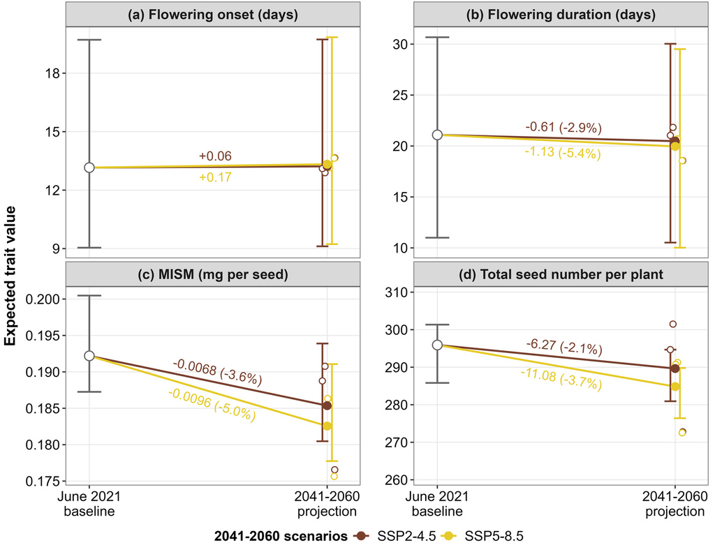

Baseline and projected reproductive traits

### 6.2.2 Figure S6. Projected changes and bootstrap intervals

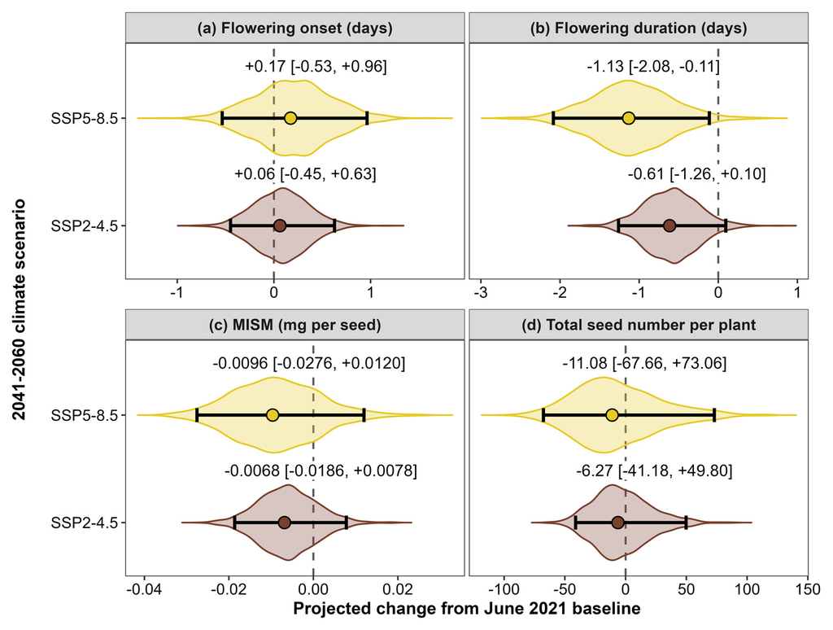

Projected changes and bootstrap intervals

Projected changes in Arabis alpina reproductive traits for 2041-2060 relative to June 2021. Panels show (a) flowering onset, (b) duration, (c) MISM and (d) seed number. Brown and yellow identify SSP2-4.5 and SSP5-8.5. Violin widths show densities of scenario mean changes from 1,000 parametric bootstrap replicates. Points show model-estimated changes averaged equally across three climate models. Bars are 95% percentile bootstrap intervals; dashed lines mark zero.

### 6.2.3 Table 3. Modelled baseline means and projected means and changes

Baseline and projected reproductive trait summaries and changes under mid-century scenarios. Baseline values are conditional model predictions for June 2021; future values refer to 2041-2060 and are averaged equally across three climate models. For MISM, exponentiating log-scale predictions without a retransformation correction yields plant-level conditional medians; reported summaries average those medians, rather than estimating arithmetic expected seed mass. Other traits summarise expected values conditional on their predictors. Gaussian projections retain fitted block and plot effects. For seed number, two negligible random-intercept components were removed after the nested model failed numerical checks; the resolved model retains the NB2 family, log link and all environmental predictors. Change is future minus baseline. Flowering onset and duration are in days, MISM in mg per seed, and seed number in seeds per plant. Flowering duration is retained as the projection response; the H3 final-date re-expression does not change these projections. Confidence limits are 95% percentile bootstrap intervals for scenario mean changes, based on 1,000 retained replicates per trait with no refitting errors or non-finite predictions. Retention does not establish that all refits passed convergence-warning, Hessian or singularity checks. Equal model weighting does not quantify the full uncertainty among future climate trajectories. Reported values were rounded independently.

| Scenario | Trait | Baseline_mean | Future_mean | Mean_change | Mean_change_CI_low | Mean_change_CI_high | Retained_bootstraps | Response_unit | Prediction_summary |
| --- | --- | --- | --- | --- | --- | --- | --- | --- | --- |
| SSP2-4.5 | Flowering_duration | 21.091 | 20.477 | -0.615 | -1.261 | 0.095 | 1000 | days | Mean of plant-level conditional expected values |
| SSP2-4.5 | Flowering_onset | 13.157 | 13.219 | 0.062 | -0.449 | 0.627 | 1000 | days | Mean of plant-level conditional expected values |
| SSP2-4.5 | MISM | 0.192 | 0.185 | -0.007 | -0.019 | 0.008 | 1000 | mg per seed | Mean of plant-level conditional medians |
| SSP2-4.5 | Total_seed_number | 295.921 | 289.65 | -6.271 | -41.176 | 49.805 | 1000 | seeds per plant | Mean of plant-level conditional expected values |
| SSP5-8.5 | Flowering_duration | 21.091 | 19.959 | -1.132 | -2.084 | -0.113 | 1000 | days | Mean of plant-level conditional expected values |
| SSP5-8.5 | Flowering_onset | 13.157 | 13.329 | 0.173 | -0.535 | 0.964 | 1000 | days | Mean of plant-level conditional expected values |
| SSP5-8.5 | MISM | 0.192 | 0.183 | -0.01 | -0.028 | 0.012 | 1000 | mg per seed | Mean of plant-level conditional medians |
| SSP5-8.5 | Total_seed_number | 295.921 | 284.841 | -11.08 | -67.663 | 73.06 | 1000 | seeds per plant | Mean of plant-level conditional expected values |

# 7 Rendering session

This records the R session used to assemble the supplement. Individual analysis scripts list their modelling and graphics packages.

## 7.1 Diagnostic figures

These plots check features of the fitted models that coefficient tables cannot show. They are visual checks, not proof that all assumptions hold. Warnings from rendering this report are hidden; numerical warnings and diagnostic results in the saved analysis tables are retained.

### 7.1.1 Flowering phenology

#### 7.1.1.1 Flowering onset and duration models

Each row pairs standardized residuals against fitted values (left) with a normal Q–Q plot (right). The rows show onset versus elevation, duration versus elevation, and duration versus onset. A trend away from zero in the left panels suggests a mean-structure problem; changing spread suggests unequal variance. Systematic departures from the Q–Q line indicate departures from Gaussian residuals.

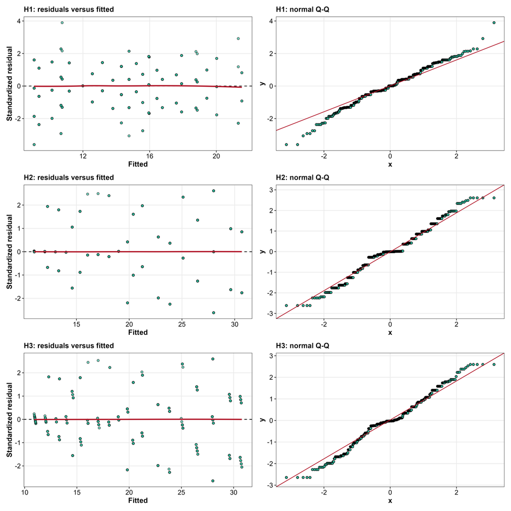

Flowering onset and duration models

### 7.1.2 Germination responses to source elevation

For each Gaussian model, the four panels show residuals against fitted values, a normal Q–Q plot, a residual histogram, and a scale-location plot. Look for trends around zero, skew or heavy tails, and changing residual spread. Discrete or bounded responses can produce bands or edge effects; the alternative models address sensitivity to the response distribution.

#### 7.1.2.1 Time to first germination versus elevation

Saved residual checks for the primary Gaussian elevation fit.

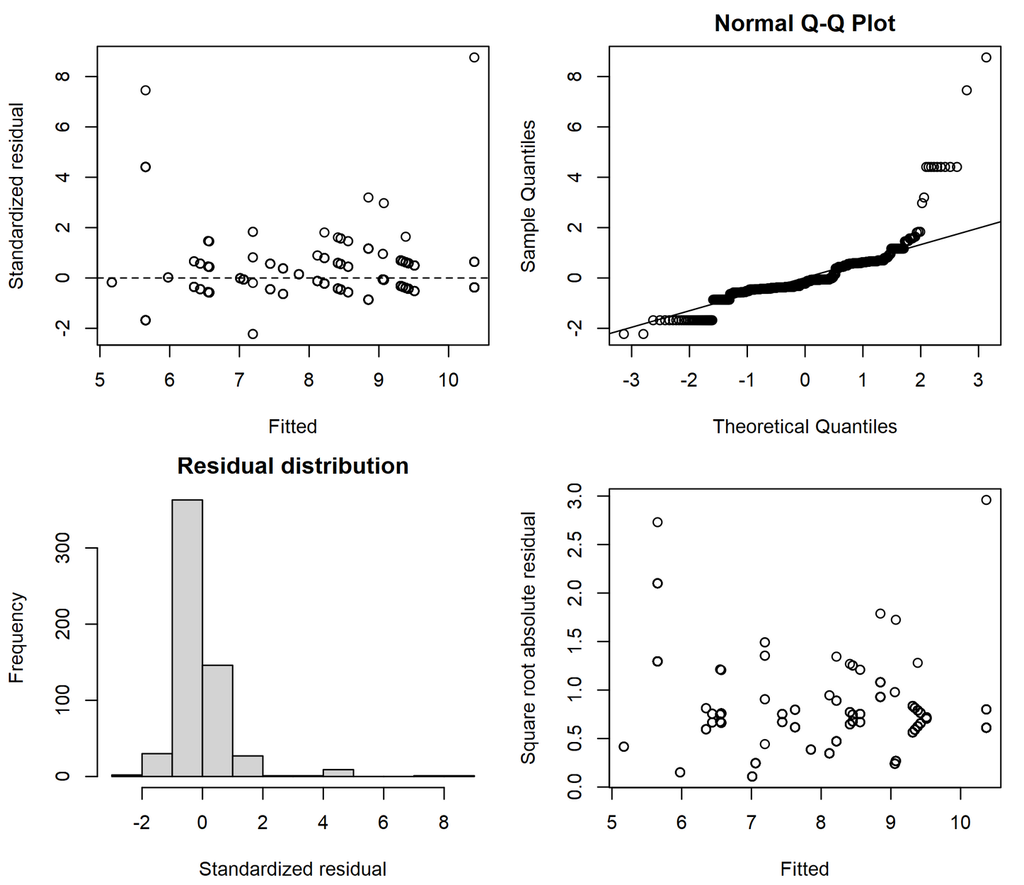

Time to first germination versus elevation

#### 7.1.2.2 Germination time spread versus elevation

Saved residual checks for the primary Gaussian elevation fit.

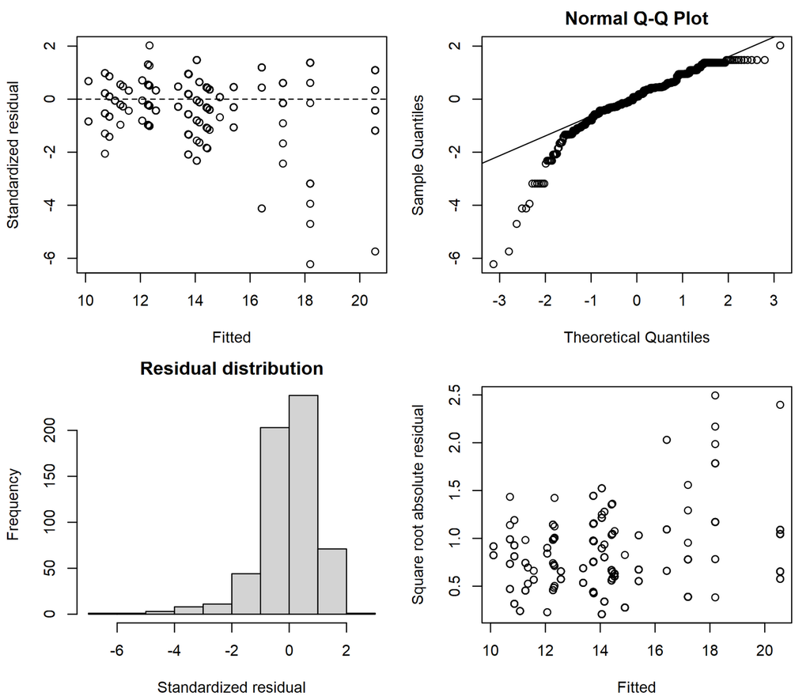

Germination time spread versus elevation

#### 7.1.2.3 Mean germination rate versus elevation

Saved residual checks for the primary Gaussian elevation fit.

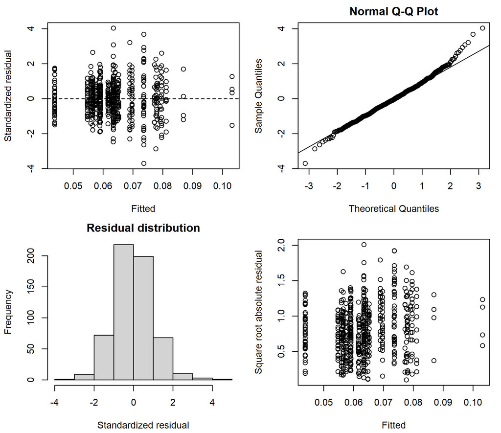

Mean germination rate versus elevation

#### 7.1.2.4 Germination percentage versus elevation

Saved residual checks for the primary Gaussian elevation fit.

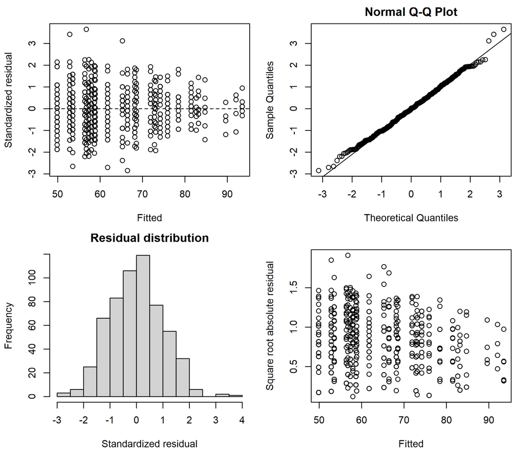

Germination percentage versus elevation

#### 7.1.2.5 Germination percentage: binomial

DHARMa compares simulation-based residuals with the expected uniform distribution. The fitted-value panel checks whether residual quantiles show trends. Table S3 reports numerical checks and test results, including those for the ordinal fits.

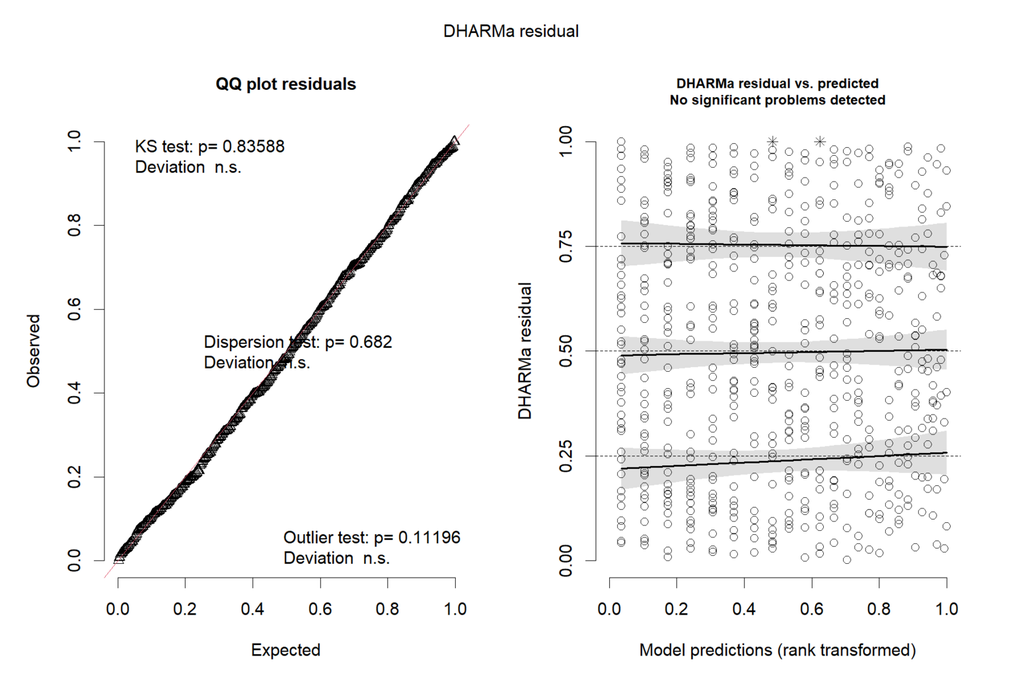

Germination percentage: binomial

#### 7.1.2.6 Germination percentage: beta-binomial

DHARMa compares simulation-based residuals with the expected uniform distribution. The fitted-value panel checks whether residual quantiles show trends. Table S3 reports numerical checks and test results, including those for the ordinal fits.

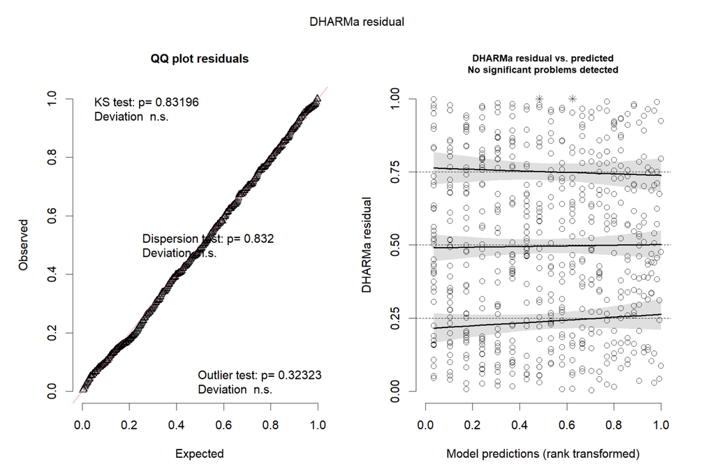

Germination percentage: beta-binomial

#### 7.1.2.7 Mean germination rate: Gamma

DHARMa compares simulation-based residuals with the expected uniform distribution. The fitted-value panel checks whether residual quantiles show trends. Table S3 reports numerical checks and test results, including those for the ordinal fits.

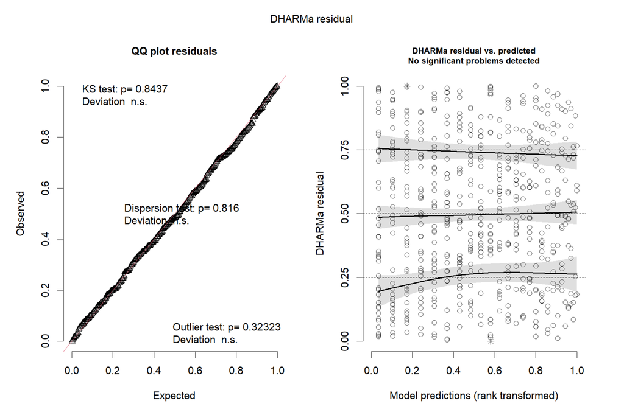

Mean germination rate: Gamma

### 7.1.3 Maternal seed allocation

#### 7.1.3.1 Mean individual seed mass versus elevation

These residual–fitted and normal Q–Q plots assess the Gaussian fit on the log seed-mass scale. Check for curvature, changing spread, and departures from the reference line.

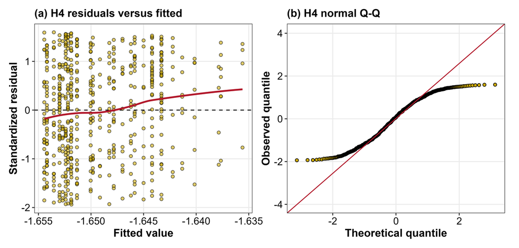

Mean individual seed mass versus elevation

#### 7.1.3.2 Seed-number models for elevation and seed mass

The DHARMa plots assess the selected count models. Residuals should be approximately uniform under the fitted distribution, with no systematic change across fitted values. The displayed test results do not replace the separate convergence and Hessian checks.

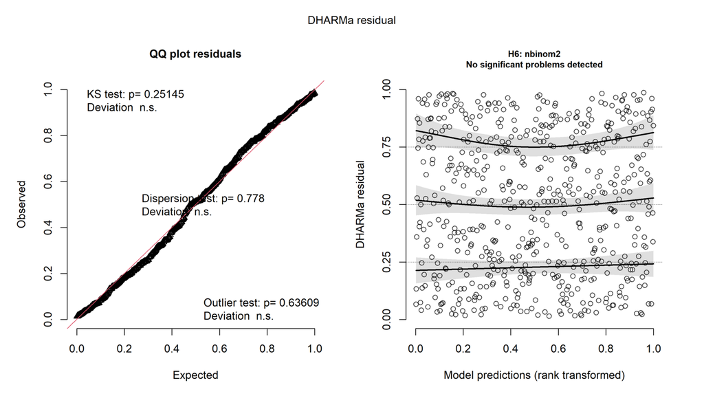

Seed-number models for elevation and seed mass

### 7.1.4 Maternal seed mass and germination responses

The same four Gaussian diagnostics are shown for each outcome before and after adjustment for source elevation. Compare the paired fits for changes in residual trends, spread, and tail departures. These checks assess model fit; they do not test the seed-mass coefficient.

#### 7.1.4.1 Time to first germination: seed mass only

Use the zero line, Q–Q reference line, histogram, and scale-location panel to assess the fit on the response scale used by the model.

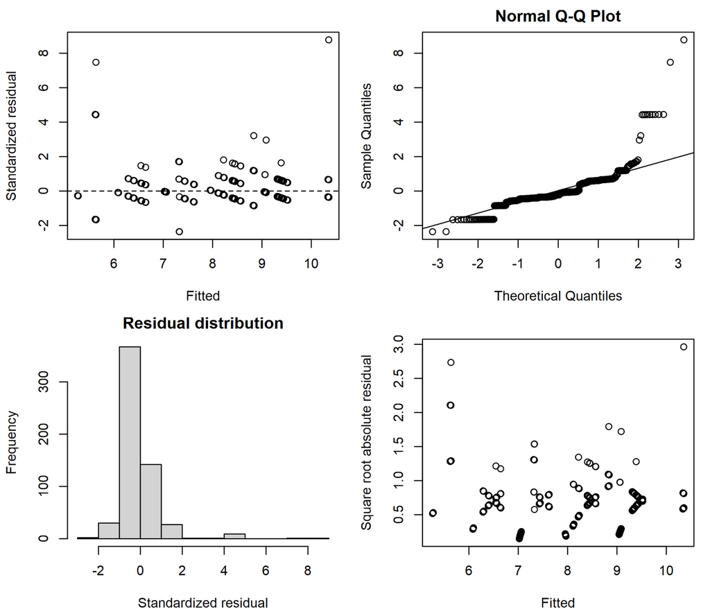

Time to first germination: seed mass only

#### 7.1.4.2 Time to first germination: adjusted for elevation

Use the zero line, Q–Q reference line, histogram, and scale-location panel to assess the fit on the response scale used by the model.

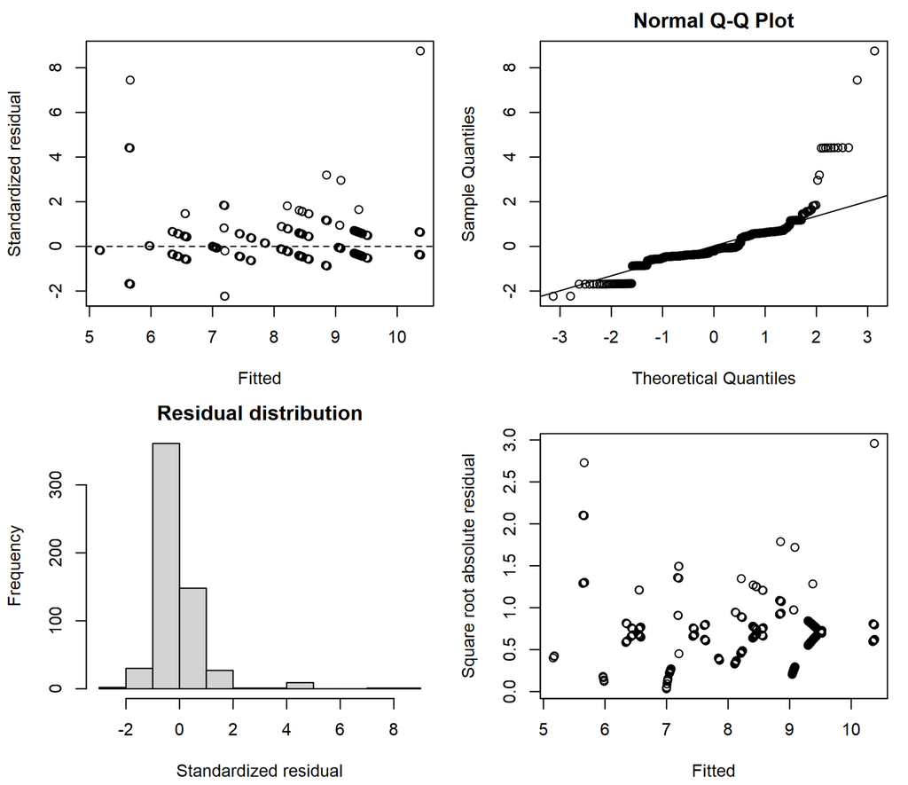

Time to first germination: adjusted for elevation

#### 7.1.4.3 Germination time spread: seed mass only

Use the zero line, Q–Q reference line, histogram, and scale-location panel to assess the fit on the response scale used by the model.

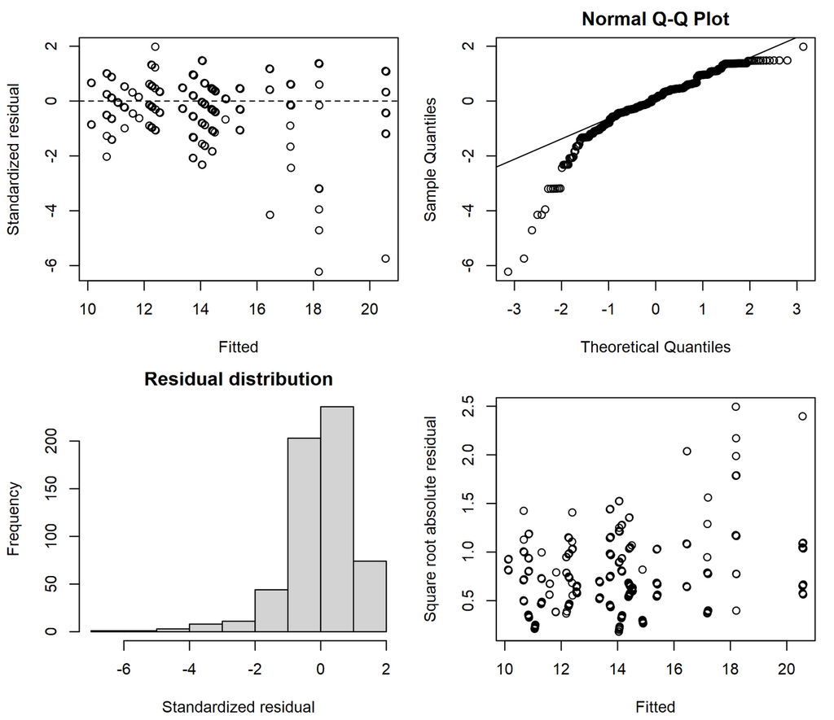

Germination time spread: seed mass only

#### 7.1.4.4 Germination time spread: adjusted for elevation

Use the zero line, Q–Q reference line, histogram, and scale-location panel to assess the fit on the response scale used by the model.

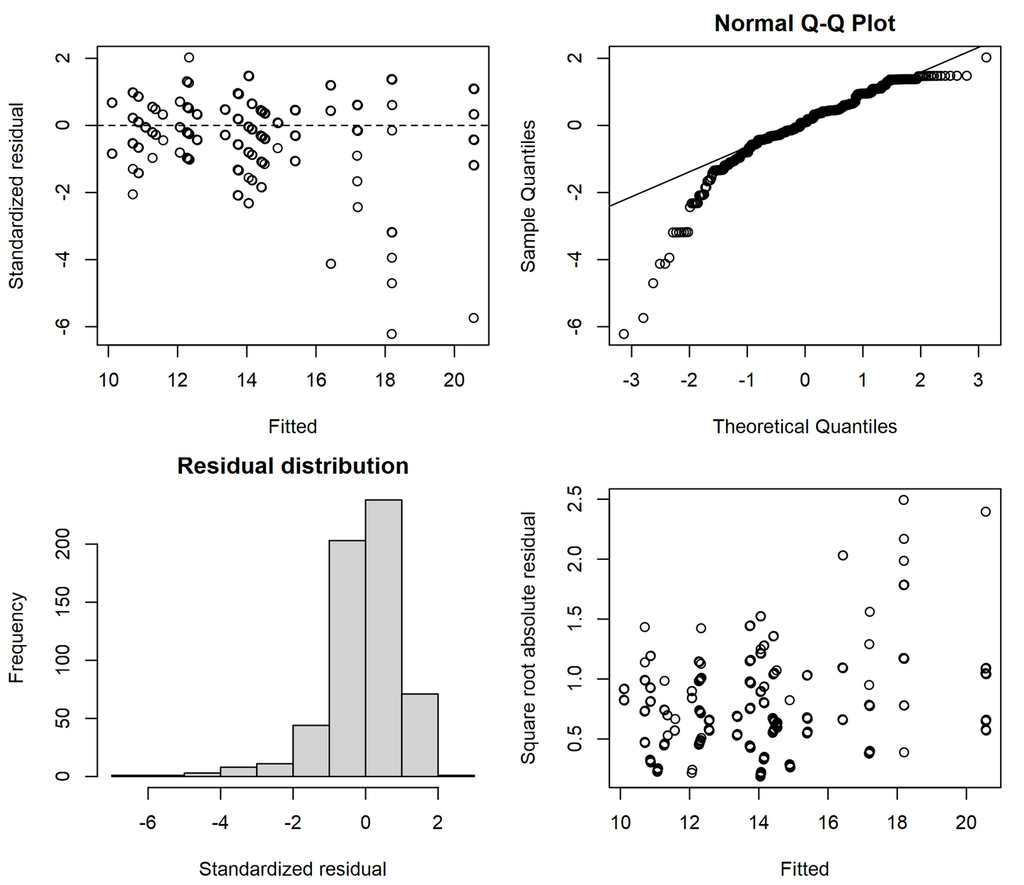

Germination time spread: adjusted for elevation

#### 7.1.4.5 Mean germination rate: seed mass only

Use the zero line, Q–Q reference line, histogram, and scale-location panel to assess the fit on the response scale used by the model.

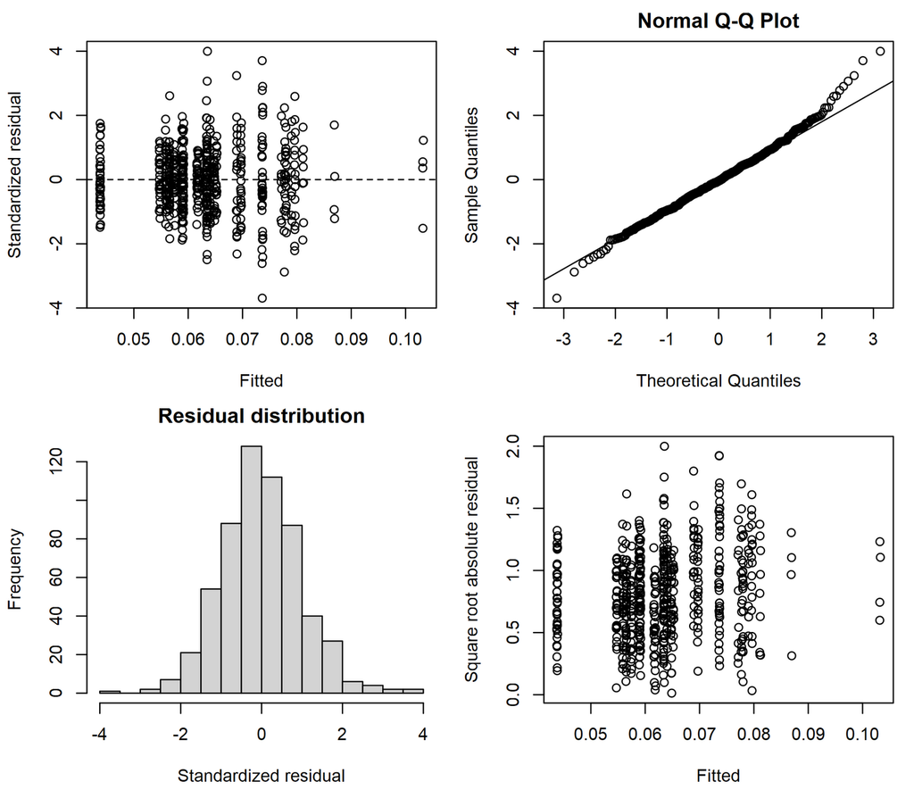

Mean germination rate: seed mass only

#### 7.1.4.6 Mean germination rate: adjusted for elevation

Use the zero line, Q–Q reference line, histogram, and scale-location panel to assess the fit on the response scale used by the model.

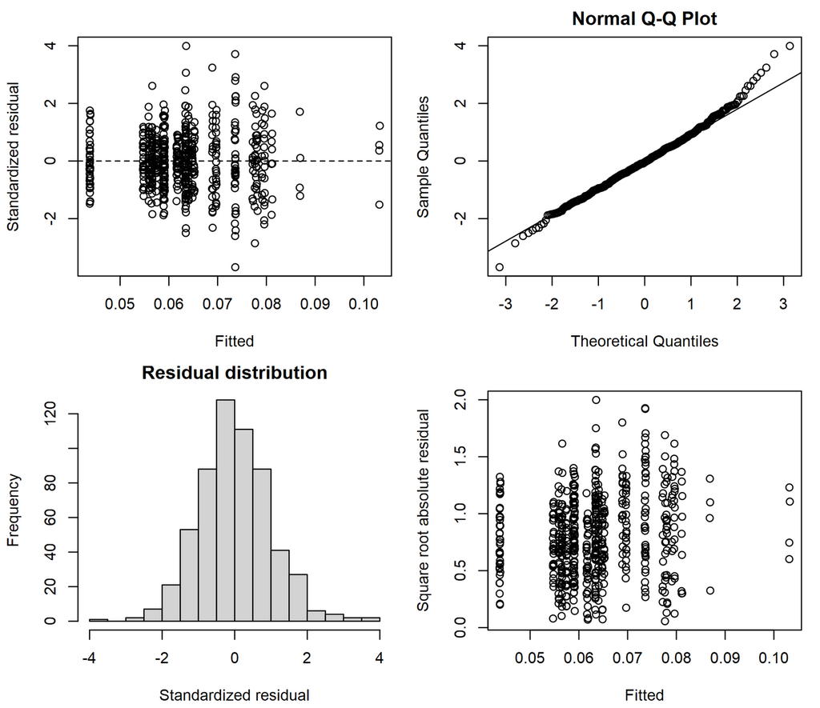

Mean germination rate: adjusted for elevation

#### 7.1.4.7 Germination percentage: seed mass only

Use the zero line, Q–Q reference line, histogram, and scale-location panel to assess the fit on the response scale used by the model.

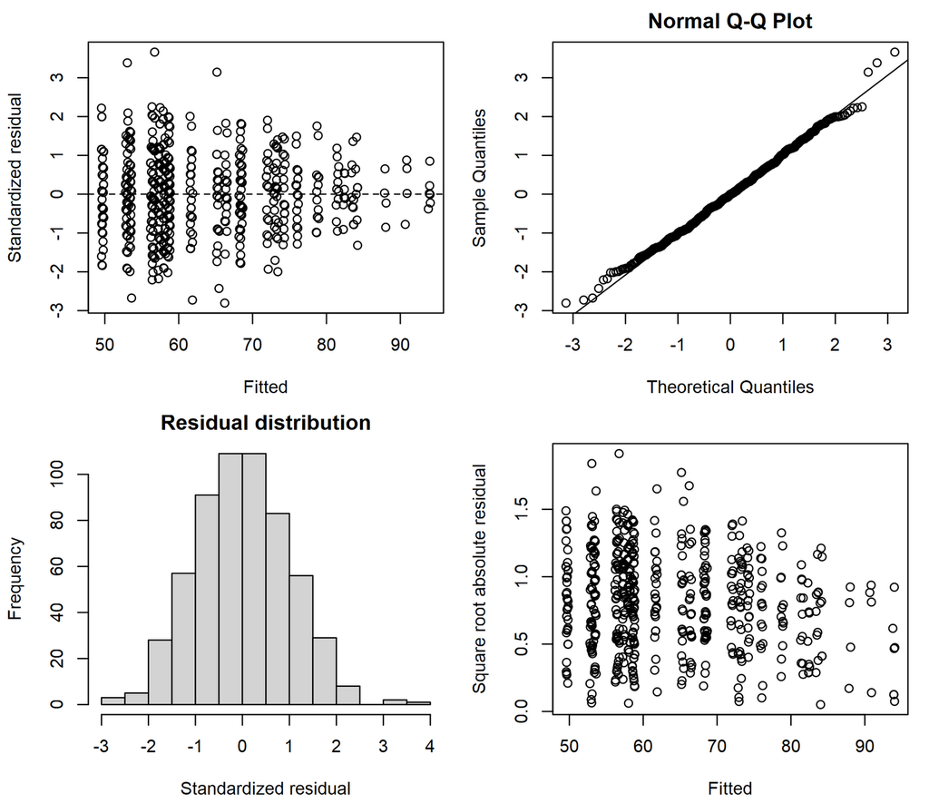

Germination percentage: seed mass only

#### 7.1.4.8 Germination percentage: adjusted for elevation

Use the zero line, Q–Q reference line, histogram, and scale-location panel to assess the fit on the response scale used by the model.

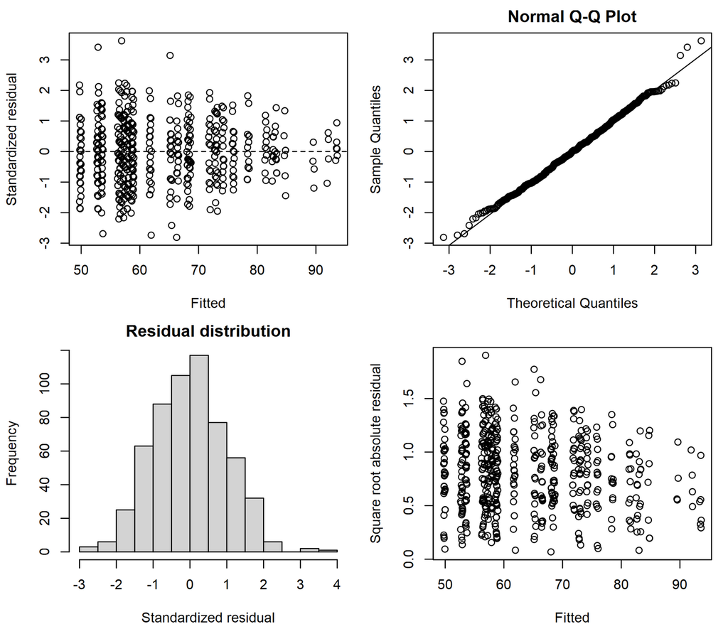

Germination percentage: adjusted for elevation

### 7.1.5 Mid-century projections

#### 7.1.5.1 Baseline climate–trait model residuals

Pearson residuals are plotted against fitted baseline values for each trait. Inspect departures from zero, changes in spread, and isolated large residuals. This saved overview precedes the seed-number stability revision and does not validate future climate extrapolation.

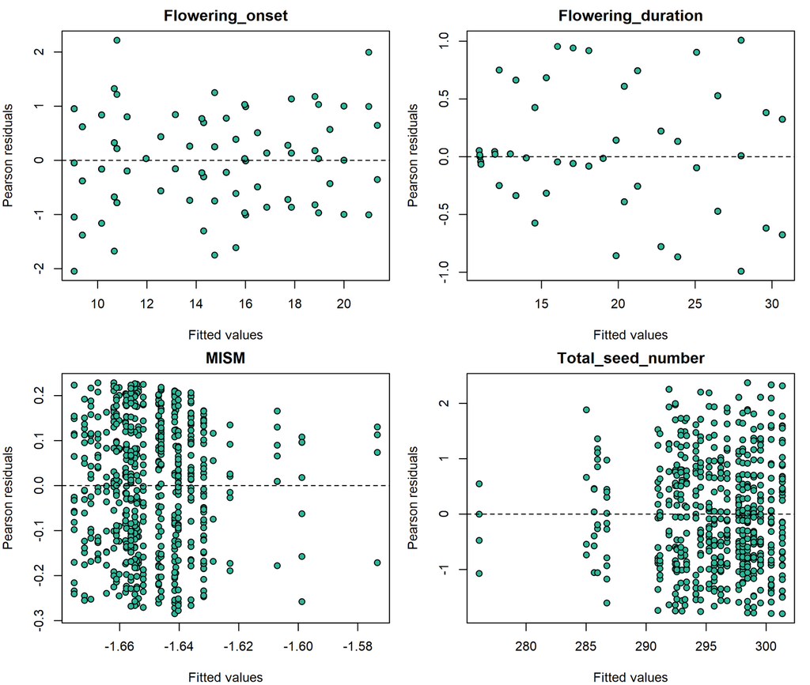

Baseline climate–trait model residuals

#### 7.1.5.2 Revised seed-number projection model

This DHARMa check applies to the revised negative-binomial model without random intercepts. Inspect residual uniformity and any pattern across fitted values. The saved bootstrap refit logs document numerical stability separately; these plots do not quantify future climate uncertainty.

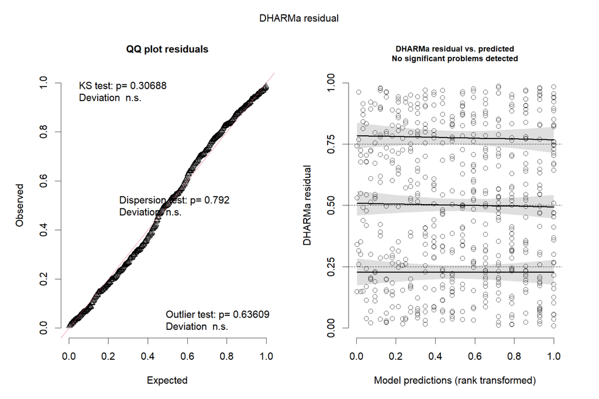

Revised seed-number projection model